# Assessment of In Silico Tools for Variant Effect Prediction in Haemoglobinopathies

## summary of splice score distributions to inspect score ranges

```r
splice_tool_score_summary <- SPLICE_FOCUSED_DATASET %>%
  summarise(
    total_splice_variants = n(),

    SpliceAI_DS_available = sum(is_usable_tool_value(SpliceAI_DS), na.rm = TRUE),
    SpliceAI_DS_min = min(clean_numeric_score(SpliceAI_DS), na.rm = TRUE),
    SpliceAI_DS_median = median(clean_numeric_score(SpliceAI_DS), na.rm = TRUE),
    SpliceAI_DS_max = max(clean_numeric_score(SpliceAI_DS), na.rm = TRUE),

    SpliceAI_AG_available = sum(is_usable_tool_value(SpliceAI_pred_DS_AG_new), na.rm = TRUE),
    SpliceAI_AG_min = min(clean_numeric_score(SpliceAI_pred_DS_AG_new), na.rm = TRUE),
    SpliceAI_AG_median = median(clean_numeric_score(SpliceAI_pred_DS_AG_new), na.rm = TRUE),
    SpliceAI_AG_max = max(clean_numeric_score(SpliceAI_pred_DS_AG_new), na.rm = TRUE),

    SpliceAI_AL_available = sum(is_usable_tool_value(SpliceAI_pred_DS_AL_new), na.rm = TRUE),
    SpliceAI_AL_min = min(clean_numeric_score(SpliceAI_pred_DS_AL_new), na.rm = TRUE),
    SpliceAI_AL_median = median(clean_numeric_score(SpliceAI_pred_DS_AL_new), na.rm = TRUE),
    SpliceAI_AL_max = max(clean_numeric_score(SpliceAI_pred_DS_AL_new), na.rm = TRUE),

    SpliceAI_DG_available = sum(is_usable_tool_value(SpliceAI_pred_DS_DG_new), na.rm = TRUE),
    SpliceAI_DG_min = min(clean_numeric_score(SpliceAI_pred_DS_DG_new), na.rm = TRUE),
    SpliceAI_DG_median = median(clean_numeric_score(SpliceAI_pred_DS_DG_new), na.rm = TRUE),
    SpliceAI_DG_max = max(clean_numeric_score(SpliceAI_pred_DS_DG_new), na.rm = TRUE),

    SpliceAI_DL_available = sum(is_usable_tool_value(SpliceAI_pred_DS_DL_new), na.rm = TRUE),
    SpliceAI_DL_min = min(clean_numeric_score(SpliceAI_pred_DS_DL_new), na.rm = TRUE),
    SpliceAI_DL_median = median(clean_numeric_score(SpliceAI_pred_DS_DL_new), na.rm = TRUE),
    SpliceAI_DL_max = max(clean_numeric_score(SpliceAI_pred_DS_DL_new), na.rm = TRUE),

    MaxEntScan_available = sum(is_usable_tool_value(MaxEntScan_diff_new), na.rm = TRUE),
    MaxEntScan_min = min(clean_numeric_score(MaxEntScan_diff_new), na.rm = TRUE),
    MaxEntScan_median = median(clean_numeric_score(MaxEntScan_diff_new), na.rm = TRUE),
    MaxEntScan_max = max(clean_numeric_score(MaxEntScan_diff_new), na.rm = TRUE),

    ada_score_available = sum(is_usable_tool_value(ada_score_new), na.rm = TRUE),
    ada_score_min = min(clean_numeric_score(ada_score_new), na.rm = TRUE),
    ada_score_median = median(clean_numeric_score(ada_score_new), na.rm = TRUE),
    ada_score_max = max(clean_numeric_score(ada_score_new), na.rm = TRUE),

    rf_score_available = sum(is_usable_tool_value(rf_score_new), na.rm = TRUE),
    rf_score_min = min(clean_numeric_score(rf_score_new), na.rm = TRUE),
    rf_score_median = median(clean_numeric_score(rf_score_new), na.rm = TRUE),
    rf_score_max = max(clean_numeric_score(rf_score_new), na.rm = TRUE)
  )

splice_tool_score_summary %>%
  print(width = Inf)
```

```
## # A tibble: 1 × 33
##   total_splice_variants SpliceAI_DS_available SpliceAI_DS_min SpliceAI_DS_median
##                   <int>                 <int>           <dbl>              <dbl>
## 1                   127                    94               0              0.345
##   SpliceAI_DS_max SpliceAI_AG_available SpliceAI_AG_min SpliceAI_AG_median
##             <dbl>                 <int>           <dbl>              <dbl>
## 1               1                   116               0                  0
##   SpliceAI_AG_max SpliceAI_AL_available SpliceAI_AL_min SpliceAI_AL_median
##             <dbl>                 <int>           <dbl>              <dbl>
## 1            0.98                   116               0                  0
##   SpliceAI_AL_max SpliceAI_DG_available SpliceAI_DG_min SpliceAI_DG_median
##             <dbl>                 <int>           <dbl>              <dbl>
## 1               1                   116               0                  0
##   SpliceAI_DG_max SpliceAI_DL_available SpliceAI_DL_min SpliceAI_DL_median
##             <dbl>                 <int>           <dbl>              <dbl>
## 1            0.99                   116               0                  0
##   SpliceAI_DL_max MaxEntScan_available MaxEntScan_min MaxEntScan_median
##             <dbl>                <int>          <dbl>             <dbl>
## 1               1                   92          -2.20              4.13
##   MaxEntScan_max ada_score_available ada_score_min ada_score_median
##            <dbl>               <int>         <dbl>            <dbl>
## 1           14.4                  87     0.0000107            1.000
##   ada_score_max rf_score_available rf_score_min rf_score_median rf_score_max
##           <dbl>              <int>        <dbl>           <dbl>        <dbl>
## 1         1.000                 87            0           0.926            1
```

```r
readr::write_csv(
  splice_tool_score_summary,
  file.path(output_directory, "splice_tool_score_summary.csv"))
```

## creating a combined SpliceAI maximum delta score usind a combined SpliceAI score using the maximum of the dour delta scores

```r
SPLICE_FOCUSED_DATASET <- SPLICE_FOCUSED_DATASET %>%
  mutate(
    SpliceAI_max_delta_score = pmax(
      clean_numeric_score(SpliceAI_pred_DS_AG_new),
      clean_numeric_score(SpliceAI_pred_DS_AL_new),
      clean_numeric_score(SpliceAI_pred_DS_DG_new),
      clean_numeric_score(SpliceAI_pred_DS_DL_new),
      na.rm = TRUE
    ),

    SpliceAI_max_delta_score = ifelse(
      is.infinite(SpliceAI_max_delta_score),
      NA_real_,
      SpliceAI_max_delta_score
    )
  )

SPLICE_FOCUSED_DATASET %>%
  summarise(
    total_splice_variants = n(),
    SpliceAI_max_available = sum(!is.na(SpliceAI_max_delta_score)),
    SpliceAI_max_min = min(SpliceAI_max_delta_score, na.rm = TRUE),
    SpliceAI_max_median = median(SpliceAI_max_delta_score, na.rm = TRUE),
    SpliceAI_max_max = max(SpliceAI_max_delta_score, na.rm = TRUE))
```

```
## # A tibble: 1 × 5
##   total_splice_variants SpliceAI_max_available SpliceAI_max_min
##                   <int>                  <int>            <dbl>
## 1                   127                    116                0
## # ℹ 2 more variables: SpliceAI_max_median <dbl>, SpliceAI_max_max <dbl>
```

## A sample distribution table

```r
spliceai_max_delta_score_bins <- SPLICE_FOCUSED_DATASET %>%
  mutate(
    SpliceAI_max_delta_bin = case_when(
      is.na(SpliceAI_max_delta_score) ~ "Missing",
      SpliceAI_max_delta_score == 0 ~ "0",
      SpliceAI_max_delta_score > 0 & SpliceAI_max_delta_score < 0.2 ~ ">0 to <0.2",
      SpliceAI_max_delta_score >= 0.2 & SpliceAI_max_delta_score < 0.5 ~ "0.2 to <0.5",
      SpliceAI_max_delta_score >= 0.5 & SpliceAI_max_delta_score < 0.8 ~ "0.5 to <0.8",
      SpliceAI_max_delta_score >= 0.8 ~ ">=0.8"
    )
  ) %>%
  count(SpliceAI_max_delta_bin, name = "n") %>%
  mutate(
    percentage = round(n / sum(n) * 100, 1)
  )

spliceai_max_delta_score_bins
```

```
## # A tibble: 6 × 3
##   SpliceAI_max_delta_bin     n percentage
##   <chr>                  <int>      <dbl>
## 1 0                         23       18.1
## 2 0.2 to <0.5               13       10.2
## 3 0.5 to <0.8               12        9.4
## 4 >0 to <0.2                18       14.2
## 5 >=0.8                     50       39.4
## 6 Missing                   11        8.7
```

```r
readr::write_csv(
  spliceai_max_delta_score_bins,
  file.path(output_directory, "spliceai_max_delta_score_bins.csv"))
```

## create a threshold reference table

```r
threshold_reference_table <- tibble::tibble(
  tool = c(
    "CADD",
    "DANN",
    "Eigen-PC"
  ),

  score_column = c(
    "CADD_PHRED_new",
    "DANN_score_new",
    "Eigen_PC_phred_coding_new"
  ),

  score_direction = c(
    "Higher score = more deleterious",
    "Higher score = more deleterious",
    "Higher score = more deleterious"
  ),

  threshold_used = c(
    10.44,
    NA_real_,
    NA_real_
  ),

  threshold_rule = c(
    "Score > 10.44 classified as pathogenic-like",
    "Threshold to be confirmed from original haemoglobinopathy evaluation",
    "Threshold to be confirmed from original haemoglobinopathy evaluation"
  ),

  threshold_source = c(
    "Haemoglobinopathy predictor evaluation",
    "To confirm",
    "To confirm"
  ),

  final_for_thesis = c(
    "Yes",
    "No - provisional until confirmed",
    "No - provisional until confirmed"
  )
)

threshold_reference_table
```

```
## # A tibble: 3 × 7
##   tool     score_column            score_direction threshold_used threshold_rule
##   <chr>    <chr>                   <chr>                    <dbl> <chr>
## 1 CADD     CADD_PHRED_new          Higher score =…           10.4 Score > 10.44…
## 2 DANN     DANN_score_new          Higher score =…           NA   Threshold to …
## 3 Eigen-PC Eigen_PC_phred_coding_… Higher score =…           NA   Threshold to …
## # ℹ 2 more variables: threshold_source <chr>, final_for_thesis <chr>
```

```r
readr::write_csv(
  threshold_reference_table,
  file.path(output_directory, "threshold_reference_table.csv"))
```

## to check how exactly clinical classifications were converted

```r
reference_classification_qc <- ANALYSIS_DATASET %>%
  count(Observed_pathogenicity, observed_binary, name = "n") %>%
  arrange(desc(n))

reference_classification_qc
```

```
## # A tibble: 3 × 3
##   Observed_pathogenicity observed_binary     n
##   <chr>                  <chr>           <int>
## 1 P/LP                   Pathogenic        832
## 2 VUS                    <NA>              601
## 3 B/LB                   Benign            194
```

```r
BINARY_REFERENCE_DATASET <- ANALYSIS_DATASET %>%
  filter(
    observed_binary %in% c("Pathogenic", "Benign")
  )

binary_reference_summary <- BINARY_REFERENCE_DATASET %>%
  count(observed_binary, name = "n") %>%
  mutate(
    percent = round(n / sum(n) * 100, 1)
  )

binary_reference_summary
```

```
## # A tibble: 2 × 3
##   observed_binary     n percent
##   <chr>           <int>   <dbl>
## 1 Benign            194    18.9
## 2 Pathogenic        832    81.1
```

```r
output_directory <- paste0(
  "C:/Users/HP/Documents/",
  "ASSESSMENT OF IN SILICO TOOLS FOR VARIANT EFFECT ",
  "PREDICTION IN HAEMOGLOBINOPATHIES/",
  "haemoglobinopathy-variant/results"
)

if (!dir.exists(output_directory)) {
  dir.create(output_directory, recursive = TRUE)
}

readr::write_csv(
  reference_classification_qc,
  file.path(output_directory, "qc_reference_classification.csv")
)

readr::write_csv(
  binary_reference_summary,
  file.path(output_directory, "binary_reference_summary.csv")
)
```

#creating a tool column QC map using actual columns

```r
binary_tool_qc_map <- tibble::tribble(
  ~tool, ~raw_score_col, ~prediction_col,
  "SIFT", "SIFT_new", NA_character_,
  "PolyPhen-2", "PolyPhen_new", NA_character_,
  "PROVEAN", "PROVEAN_score_new", "PROVEAN_pred_new",
  "FATHMM", "FATHMM_score_seperated", NA_character_,
  "FATHMM-MKL", "fathmm-MKL_coding_score", NA_character_,
  "FATHMM-XF", "fathmm_XF_coding_score_new", "fathmm_XF_coding_pred_new",
  "MutationTaster", "MutationTaster_score_new", "MutationTaster_pred_new",
  "MutationAssessor", "MutationAssessor_score_new", "MutationAssessor_pred_new",
  "MutPred2", "MutPred2_score_new", "MutPred2_pred_new",
  "DEOGEN2", "DEOGEN2_score_new", "DEOGEN2_pred_new",
  "PrimateAI", "PrimateAI_score_new", "PrimateAI_pred_new",
  "REVEL", "REVEL_score_new", NA_character_,
  "ClinPred", "ClinPred_score_new", "ClinPred_pred_new",
  "MetaSVM", "MetaSVM_score_new", "MetaSVM_pred_new",
  "MetaLR", "MetaLR_score_new", "MetaLR_pred_new",
  "BayesDel addAF", "BayesDel_addAF_score_new", "BayesDel_addAF_pred_new",
  "BayesDel noAF", "BayesDel_noAF_score_new", "BayesDel_noAF_pred_new",
  "LIST-S2", "LIST_S2_score_new", "LIST_S2_pred_new",
  "MetaRNN", "MetaRNN_score_new", "MetaRNN_pred_new",
  "ESM1b", "ESM1b_score_new", "ESM1b_pred_new",
  "EVE", "EVE_SCORE_new", "EVE_CLASS_new",
  "popEVE", "popEVE_SCORE_1_new", "popEVE_pred_new"
)

binary_tool_qc_map <- binary_tool_qc_map %>%
  mutate(
    raw_score_col_exists = raw_score_col %in% names(ANALYSIS_DATASET),
    prediction_col_exists = ifelse(
      is.na(prediction_col),
      NA,
      prediction_col %in% names(ANALYSIS_DATASET)
    )
  )

binary_tool_qc_map
```

```
## # A tibble: 22 × 5
##    tool  raw_score_col prediction_col raw_score_col_exists prediction_col_exists
##    <chr> <chr>         <chr>          <lgl>                <lgl>
##  1 SIFT  SIFT_new      <NA>           TRUE                 NA
##  2 Poly… PolyPhen_new  <NA>           TRUE                 NA
##  3 PROV… PROVEAN_scor… PROVEAN_pred_… TRUE                 TRUE
##  4 FATH… FATHMM_score… <NA>           TRUE                 NA
##  5 FATH… fathmm-MKL_c… <NA>           TRUE                 NA
##  6 FATH… fathmm_XF_co… fathmm_XF_cod… TRUE                 TRUE
##  7 Muta… MutationTast… MutationTaste… TRUE                 TRUE
##  8 Muta… MutationAsse… MutationAsses… TRUE                 TRUE
##  9 MutP… MutPred2_sco… MutPred2_pred… TRUE                 TRUE
## 10 DEOG… DEOGEN2_scor… DEOGEN2_pred_… TRUE                 TRUE
## # ℹ 12 more rows
```

```r
readr::write_csv(
  binary_tool_qc_map,
  file.path(output_directory, "binary_tool_qc_column_map.csv"))
```

```r
binary_tool_qc_map %>%
  select(
    tool,
    raw_score_col,
    prediction_col,
    raw_score_col_exists,
    prediction_col_exists
  ) %>%
  print(n = Inf, width = Inf)
```

```
## # A tibble: 22 × 5
##    tool             raw_score_col              prediction_col
##    <chr>            <chr>                      <chr>
##  1 SIFT             SIFT_new                   <NA>
##  2 PolyPhen-2       PolyPhen_new               <NA>
##  3 PROVEAN          PROVEAN_score_new          PROVEAN_pred_new
##  4 FATHMM           FATHMM_score_seperated     <NA>
##  5 FATHMM-MKL       fathmm-MKL_coding_score    <NA>
##  6 FATHMM-XF        fathmm_XF_coding_score_new fathmm_XF_coding_pred_new
##  7 MutationTaster   MutationTaster_score_new   MutationTaster_pred_new
##  8 MutationAssessor MutationAssessor_score_new MutationAssessor_pred_new
##  9 MutPred2         MutPred2_score_new         MutPred2_pred_new
## 10 DEOGEN2          DEOGEN2_score_new          DEOGEN2_pred_new
## 11 PrimateAI        PrimateAI_score_new        PrimateAI_pred_new
## 12 REVEL            REVEL_score_new            <NA>
```

[output cut: 34 more lines]

```r
binary_tool_qc_map %>%
  filter(
    raw_score_col_exists == FALSE |
      prediction_col_exists == FALSE
  ) %>%
  print(n = Inf, width = Inf)
```

```
## # A tibble: 0 × 5
## # ℹ 5 variables: tool <chr>, raw_score_col <chr>, prediction_col <chr>, raw_score_col_exists <lgl>, prediction_col_exists <lgl>
```

##Determine if tools with low score have truly low evaluable samples

##helper chunk

```r
clean_numeric_score <- function(x) {
  x <- as.character(x)
  x[x %in% c("", "-", ".", "NA", "na", "N/A")] <- NA
  as.numeric(x)
}

classify_prediction_label <- function(x) {
  x_clean <- stringr::str_to_lower(as.character(x))
  x_clean <- stringr::str_trim(x_clean)
  x_clean <- stringr::str_replace_all(x_clean, " ", "_")
  x_clean <- stringr::str_replace_all(x_clean, "-", "_")

  dplyr::case_when(
    is.na(x_clean) ~ NA_character_,
    x_clean %in% c("", "-", ".", "na", "n/a") ~ NA_character_,

    x_clean %in% c(
      "d", "pathogenic", "likely_pathogenic",
      "probably_damaging", "possibly_damaging",
      "damaging", "deleterious",
      "h", "a", "s", "pp", "ps", "pm"
    ) ~ "Pathogenic",

    stringr::str_detect(x_clean, "probably_damaging") ~ "Pathogenic",
    stringr::str_detect(x_clean, "possibly_damaging") ~ "Pathogenic",
    stringr::str_detect(x_clean, "^deleterious") ~ "Pathogenic",
    stringr::str_detect(x_clean, "^damaging") ~ "Pathogenic",
    stringr::str_detect(x_clean, "(^|,)d(,|$)") ~ "Pathogenic",
    stringr::str_detect(x_clean, "(^|,)a(,|$)") ~ "Pathogenic",

    x_clean %in% c(
      "t", "b", "benign", "likely_benign",
      "tolerated", "neutral",
      "n", "l", "bm", "bp"
    ) ~ "Benign",

    stringr::str_detect(x_clean, "^tolerated") ~ "Benign",
    stringr::str_detect(x_clean, "^benign") ~ "Benign",
    stringr::str_detect(x_clean, "^neutral") ~ "Benign",
    stringr::str_detect(x_clean, "(^|,)n(,|$)") ~ "Benign",

    x_clean %in% c("ambiguous", "uncertain", "unknown", "uc", "m") ~ NA_character_,

    TRUE ~ NA_character_
  )
}

classify_mutationassessor_label <- function(x) {
  x_clean <- stringr::str_to_lower(as.character(x))
  x_clean <- stringr::str_trim(x_clean)

  dplyr::case_when(
    is.na(x_clean) ~ NA_character_,
    x_clean %in% c("", "-", ".", "na", "n/a") ~ NA_character_,
    x_clean %in% c("h", "m", "high", "medium") ~ "Pathogenic",
    x_clean %in% c("l", "n", "low", "neutral") ~ "Benign",
    TRUE ~ NA_character_
  )
}

classify_popeve_label <- function(x) {
  x_clean <- stringr::str_to_lower(as.character(x))
  x_clean <- stringr::str_trim(x_clean)

  dplyr::case_when(
    is.na(x_clean) ~ NA_character_,
    x_clean %in% c("", "-", ".", "na", "n/a") ~ NA_character_,
    x_clean == "s" ~ "Pathogenic",
    x_clean == "b" ~ "Benign",
    x_clean == "m" ~ NA_character_,
    TRUE ~ NA_character_
  )
}

classify_polyphen_label_or_score <- function(polyphen_label, polyphen_score) {
  label_clean <- classify_prediction_label(polyphen_label)
  score_numeric <- as.numeric(polyphen_score)

  dplyr::case_when(
    !is.na(label_clean) ~ label_clean,
    is.na(label_clean) & !is.na(score_numeric) & score_numeric >= 0.453 ~ "Pathogenic",
    is.na(label_clean) & !is.na(score_numeric) & score_numeric < 0.453 ~ "Benign",
    TRUE ~ NA_character_
  )
}
```

##create tool-level coverage QC table

```r
count_binary_tool_coverage <- function(data, tool_name, raw_score_col, prediction_col) {

  raw_score_exists <- raw_score_col %in% names(data)
  prediction_exists <- !is.na(prediction_col) && prediction_col %in% names(data)

  total_eligible_binary_variants <- nrow(data)

  variants_with_raw_score <- if (raw_score_exists) {
    sum(is_usable_tool_value(data[[raw_score_col]]), na.rm = TRUE)
  } else {
    0
  }

  variants_with_binary_prediction <- if (prediction_exists) {
    sum(
      classify_prediction_label(data[[prediction_col]]) %in% c("Pathogenic", "Benign"),
      na.rm = TRUE
    )
  } else {
    NA_integer_
  }

  variants_with_uncertain_prediction <- if (prediction_exists) {
    sum(
      is_usable_tool_value(data[[prediction_col]]) &
        is.na(classify_prediction_label(data[[prediction_col]])),
      na.rm = TRUE
    )
  } else {
    NA_integer_
  }

  variants_missing_raw_score <- total_eligible_binary_variants - variants_with_raw_score

  tibble(
    tool = tool_name,
    raw_score_col = raw_score_col,
    prediction_col = prediction_col,
    total_eligible_binary_variants = total_eligible_binary_variants,
    variants_with_raw_score = variants_with_raw_score,
    variants_missing_raw_score = variants_missing_raw_score,
    variants_with_binary_prediction = variants_with_binary_prediction,
    variants_with_uncertain_prediction = variants_with_uncertain_prediction,
    percent_with_raw_score = round(
      variants_with_raw_score / total_eligible_binary_variants * 100,
      1
    ),
    percent_with_binary_prediction = round(
      variants_with_binary_prediction / total_eligible_binary_variants * 100,
      1
    ),
    percent_uncertain_prediction = round(
      variants_with_uncertain_prediction / total_eligible_binary_variants * 100,
      1))}

tool_level_binary_coverage_qc <- purrr::pmap_dfr(
  binary_tool_qc_map,
  function(tool, raw_score_col, prediction_col, raw_score_col_exists, prediction_col_exists) {
    count_binary_tool_coverage(
      data = BINARY_REFERENCE_DATASET,
      tool_name = tool,
      raw_score_col = raw_score_col,
      prediction_col = prediction_col)})
```

```r
# Make sure the results folder exists
if (!dir.exists(output_directory)) {
  dir.create(output_directory, recursive = TRUE)
}

# Save the table
readr::write_csv(
  tool_level_binary_coverage_qc,
  file.path(output_directory, "tool_level_binary_coverage_qc.csv")
)
```

## determine the exact prediction labels used by problematic tools

```r
ANALYSIS_DATASET %>%
  select(
    MutationTaster_pred_new,
    MutationAssessor_pred_new,
    MutPred2_pred_new,
    EVE_CLASS_new,
    popEVE_pred_new
  ) %>%
  summarise(
    across(
      everything(),
      ~ paste(sort(unique(na.omit(as.character(.x)))), collapse = "; ")
    )
  ) %>%
  tidyr::pivot_longer(
    cols = everything(),
    names_to = "prediction_column",
    values_to = "unique_values")
```

```
## # A tibble: 5 × 2
##   prediction_column         unique_values
##   <chr>                     <chr>
## 1 MutationTaster_pred_new   -; .,.; .,.,.; .,.,D; A,.; A,.,.; A,.,.,.; A,.,.,.,…
## 2 MutationAssessor_pred_new -; H; L; M; N
## 3 MutPred2_pred_new         -; BM; BP; PM; PP; PS; UC
## 4 EVE_CLASS_new             -; Benign; Pathogenic; Uncertain
## 5 popEVE_pred_new           -; B; M; S
```

```r
clean_numeric_score <- function(x) {
  suppressWarnings(
    as.numeric(
      stringr::str_extract(
        as.character(x),
        "-?[0-9]*\\.?[0-9]+")))}
```

## creating binary predictions for tools

```r
clean_prediction_columns <- names(BINARY_PERFORMANCE_DATASET)[
  grepl("_predicted_clean$", names(BINARY_PERFORMANCE_DATASET))
]

clean_binary_prediction_counts <- purrr::map_dfr(
  clean_prediction_columns,
  function(pred_col) {
    BINARY_PERFORMANCE_DATASET %>%
      count(.data[[pred_col]], name = "n") %>%
      mutate(
        prediction_column = pred_col
      ) %>%
      rename(prediction = .data[[pred_col]]) %>%
      select(
        prediction_column,
        prediction,
        n
      )
  }
)
clean_binary_prediction_counts %>%
  arrange(prediction_column, prediction)
```

```
## # A tibble: 66 × 3
##    prediction_column              prediction     n
##    <chr>                          <chr>      <int>
##  1 AlphaMissense_predicted_clean  Benign        70
##  2 AlphaMissense_predicted_clean  Pathogenic   213
##  3 AlphaMissense_predicted_clean  <NA>         743
##  4 BayesDel_addAF_predicted_clean Benign        26
##  5 BayesDel_addAF_predicted_clean Pathogenic   496
##  6 BayesDel_addAF_predicted_clean <NA>         504
##  7 BayesDel_noAF_predicted_clean  Benign        34
##  8 BayesDel_noAF_predicted_clean  Pathogenic   488
##  9 BayesDel_noAF_predicted_clean  <NA>         504
## 10 CADD_predicted_clean           Benign       123
## # ℹ 56 more rows
```

## Create a variant level confusin matric helper to help determine what each tool predicted tghe variant correctly or incorrectly

```r
classify_confusion_status <- function(observed, predicted) {
  case_when(
    observed == "Pathogenic" & predicted == "Pathogenic" ~ "TP",
    observed == "Benign" & predicted == "Benign" ~ "TN",
    observed == "Benign" & predicted == "Pathogenic" ~ "FP",
    observed == "Pathogenic" & predicted == "Benign" ~ "FN",
    TRUE ~ NA_character_)}
```

## creating a manual qc table for selected tools to check a manageable set of tools first before further analysis

```r
classify_confusion_status <- function(observed, predicted) {
  dplyr::case_when(
    is.na(observed) | is.na(predicted) ~ NA_character_,
    observed == "Pathogenic" & predicted == "Pathogenic" ~ "TP",
    observed == "Benign" & predicted == "Benign" ~ "TN",
    observed == "Benign" & predicted == "Pathogenic" ~ "FP",
    observed == "Pathogenic" & predicted == "Benign" ~ "FN",
    TRUE ~ NA_character_
  )
}

manual_variant_level_qc_table <- BINARY_PERFORMANCE_DATASET %>%
  mutate(
    CADD_status = classify_confusion_status(observed_binary, CADD_predicted_clean),
    AlphaMissense_status = classify_confusion_status(observed_binary, AlphaMissense_predicted_clean),
    MutPred2_status = classify_confusion_status(observed_binary, MutPred2_predicted_clean),
    Eigen_PC_status = classify_confusion_status(observed_binary, Eigen_PC_predicted_clean),
    DANN_status = classify_confusion_status(observed_binary, DANN_predicted_clean),
    SIFT_status = classify_confusion_status(observed_binary, SIFT_predicted_clean)
  ) %>%
  select(
    HGVS,
    HGVS_transcript,
    Effect_function,
    Observed_pathogenicity,
    observed_binary,
    CADD_predicted_clean,
    CADD_status,
    AlphaMissense_predicted_clean,
    AlphaMissense_status,
    MutPred2_predicted_clean,
    MutPred2_status,
    Eigen_PC_predicted_clean,
    Eigen_PC_status,
    DANN_predicted_clean,
    DANN_status,
    SIFT_predicted_clean,
    SIFT_status
  )

manual_variant_level_qc_table %>%
  print(n = 20, width = Inf)
```

```
## # A tibble: 1,026 × 17
##    HGVS              HGVS_transcript           Effect_function
##    <chr>             <chr>                     <chr>
##  1 HBB:c.-240G>A     NM_000518.4:c.-240G>A     Promoter
##  2 HBB:c.-151C>T     NM_000518.4:c.-151C>T     Promoter
##  3 HBB:c.-142C>T     NM_000518.4:c.-142C>T     Promoter
##  4 HBB:c.-140C>T     NM_000518.4:c.-140C>T     Promoter
##  5 HBB:c.-138C>T     NM_000518.4:c.-138C>T     Promoter
##  6 HBB:c.-138C>A     NM_000518.4:c.-138C>A     Promoter
##  7 HBB:c.-137C>G     NM_000518.4:c.-137C>G     Promoter
##  8 HBB:c.-137C>T     NM_000518.4:c.-137C>T     Promoter
##  9 HBB:c.-137C>A     NM_000518.4:c.-137C>A     Promoter
## 10 HBB:c.-136C>G     NM_000518.4:c.-136C>G     Promoter
## 11 HBB:c.-136C>A     NM_000518.4:c.-136C>A     Promoter
## 12 HBB:c.-123A>T     NM_000518.4:c.-123A>T     Promoter
```

[output cut: 97 more lines]

## select variants for manual checking and confirmation

```r
manual_variant_qc_examples <- dplyr::bind_rows(
  manual_variant_level_qc_table %>% filter(SIFT_status == "TP") %>% slice_head(n = 2),
  manual_variant_level_qc_table %>% filter(SIFT_status == "TN") %>% slice_head(n = 2),
  manual_variant_level_qc_table %>% filter(SIFT_status == "FP") %>% slice_head(n = 2),
  manual_variant_level_qc_table %>% filter(SIFT_status == "FN") %>% slice_head(n = 2)
) %>%
  distinct(HGVS, HGVS_transcript, .keep_all = TRUE)

manual_variant_qc_examples %>%
  print(n = Inf, width = Inf)
```

```
## # A tibble: 8 × 17
##   HGVS         HGVS_transcript     Effect_function
##   <chr>        <chr>               <chr>
## 1 HBB:c.1A>G   NM_000518.4:c.1A>G  Initiation codon
## 2 HBB:c.1A>C   NM_000518.4:c.1A>C  Initiation codon
## 3 HBA1:c.30C>A NM_000558.5:c.30C>A Missense codons
## 4 HBA1:c.30C>G NM_000558.5:c.30C>G Missense codons
## 5 HBA1:c.8T>G  NM_000558.5:c.8T>G  Missense codons
## 6 HBA2:c.38C>A NM_000517.4:c.38C>A Missense codons
## 7 HBB:c.82G>T  NM_000518.4:c.82G>T Missense codons, Cryptic splice site
## 8 HBA2:c.64G>T NM_000517.4:c.64G>T Missense codons
##   Observed_pathogenicity observed_binary CADD_predicted_clean CADD_status
##   <chr>                  <chr>           <chr>                <chr>
## 1 P/LP                   Pathogenic      Pathogenic           TP
## 2 P/LP                   Pathogenic      Pathogenic           TP
```

[output cut: 36 more lines]

```r
readr::write_csv(
  manual_variant_level_qc_table,
  file.path(output_directory, "manual_variant_level_qc_table.csv")
)

readr::write_csv(
  manual_variant_qc_examples,
  file.path(output_directory, "manual_qc_example_variants.csv")
)
```

## qc summary results table for results section

```r
qc_summary_table <- tibble::tibble(
  qc_step = c(
    "Reference classification QC",
    "Binary reference dataset creation",
    "Tool-column mapping QC",
    "Tool-level coverage QC",
    "Prediction-label harmonisation",
    "Clean binary performance analysis",
    "Likelihood ratio recalculation",
    "Manual variant-level QC"
  ),

  purpose = c(
    "Checked how original clinical classifications were converted into binary labels.",
    "Excluded VUS and retained only benign/likely benign and pathogenic/likely pathogenic variants.",
    "Confirmed that each tool was linked to the correct raw score and prediction columns.",
    "Measured raw score availability, binary prediction availability, missing values and uncertain outputs per tool.",
    "Updated prediction-label rules so tool-specific labels were converted consistently.",
    "Recalculated accuracy, sensitivity, specificity, MCC and related metrics using cleaned predictions.",
    "Recalculated LR+ and LR− with safer handling of zero cells and non-interpretable cases.",
    "Manually inspected example variants representing TP, TN, FP, FN, missing scores, uncertain outputs and conflicting predictions."
  ),

  status = c(
    "Completed",
    "Completed",
    "Completed",
    "Completed",
    "Completed",
    "Completed",
    "Completed",
    "Completed"
  )
)

qc_summary_table
```

```
## # A tibble: 8 × 3
##   qc_step                           purpose                               status
##   <chr>                             <chr>                                 <chr>
## 1 Reference classification QC       Checked how original clinical classi… Compl…
## 2 Binary reference dataset creation Excluded VUS and retained only benig… Compl…
## 3 Tool-column mapping QC            Confirmed that each tool was linked … Compl…
## 4 Tool-level coverage QC            Measured raw score availability, bin… Compl…
## 5 Prediction-label harmonisation    Updated prediction-label rules so to… Compl…
## 6 Clean binary performance analysis Recalculated accuracy, sensitivity, … Compl…
## 7 Likelihood ratio recalculation    Recalculated LR+ and LR− with safer … Compl…
## 8 Manual variant-level QC           Manually inspected example variants … Compl…
```

```r
if (!dir.exists(output_directory)) {
  dir.create(output_directory, recursive = TRUE)
}

readr::write_csv(
  qc_summary_table,
  file.path(output_directory, "qc_summary_table.csv")
)
```

```r
coverage_definition_table <- tibble::tibble(
  term = c(
    "Raw-score coverage",
    "Binary-prediction coverage / binary evaluability",
    "Uncertain or intermediate output",
    "Missing or unusable output"
  ),

  definition = c(
    "The proportion of eligible binary-reference variants with a usable numerical or categorical score for a tool.",
    "The proportion of eligible binary-reference variants that could be converted into a benign-like or pathogenic-like prediction.",
    "A tool output that was available but could not be confidently assigned as benign-like or pathogenic-like.",
    "A tool output that was absent, blank, coded as '-', '.', NA, or otherwise unusable."
  ),

  relevance_to_analysis = c(
    "Shows whether the tool produced any usable output for the variant.",
    "Determines whether the variant can be included in binary performance calculations such as accuracy, sensitivity, specificity, MCC and likelihood ratios.",
    "Excluded from binary performance analysis but reported separately because it affects tool applicability.",
    "Excluded from binary performance analysis and counted as not evaluated."
  )
)

coverage_definition_table
```

```
## # A tibble: 4 × 3
##   term                                          definition relevance_to_analysis
##   <chr>                                         <chr>      <chr>
## 1 Raw-score coverage                            The propo… Shows whether the to…
## 2 Binary-prediction coverage / binary evaluabi… The propo… Determines whether t…
## 3 Uncertain or intermediate output              A tool ou… Excluded from binary…
## 4 Missing or unusable output                    A tool ou… Excluded from binary…
```

```r
if (!dir.exists(output_directory)) {
  dir.create(output_directory, recursive = TRUE)
}

readr::write_csv(
  coverage_definition_table,
  file.path(output_directory, "coverage_definition_table.csv")
)
```

```r
args(calculate_binary_tool_performance)
```

```
## function (data, observed_col, predicted_col, tool_name)
## NULL
```

## Binary performance analysis

```r
binary_tool_performance_summary <- dplyr::bind_rows(

  calculate_binary_tool_performance(
    data = BINARY_PERFORMANCE_DATASET,
    observed_col = "observed_binary",
    predicted_col = "SIFT_predicted_clean",
    tool_name = "SIFT"
  ),

  calculate_binary_tool_performance(
    data = BINARY_PERFORMANCE_DATASET,
    observed_col = "observed_binary",
    predicted_col = "PolyPhen_predicted_clean",
    tool_name = "PolyPhen-2"
  ),

  calculate_binary_tool_performance(
    data = BINARY_PERFORMANCE_DATASET,
    observed_col = "observed_binary",
    predicted_col = "PROVEAN_predicted_clean",
    tool_name = "PROVEAN"
  ),

  calculate_binary_tool_performance(
    data = BINARY_PERFORMANCE_DATASET,
    observed_col = "observed_binary",
    predicted_col = "MutationTaster_predicted_clean",
    tool_name = "MutationTaster"
  ),

  calculate_binary_tool_performance(
    data = BINARY_PERFORMANCE_DATASET,
    observed_col = "observed_binary",
    predicted_col = "MutationAssessor_predicted_clean",
    tool_name = "MutationAssessor"
  ),

  calculate_binary_tool_performance(
    data = BINARY_PERFORMANCE_DATASET,
    observed_col = "observed_binary",
    predicted_col = "MutPred2_predicted_clean",
    tool_name = "MutPred2"
  ),

  calculate_binary_tool_performance(
    data = BINARY_PERFORMANCE_DATASET,
    observed_col = "observed_binary",
    predicted_col = "DEOGEN2_predicted_clean",
    tool_name = "DEOGEN2"
  ),

  calculate_binary_tool_performance(
    data = BINARY_PERFORMANCE_DATASET,
    observed_col = "observed_binary",
    predicted_col = "PrimateAI_predicted_clean",
    tool_name = "PrimateAI"
  ),

  calculate_binary_tool_performance(
    data = BINARY_PERFORMANCE_DATASET,
    observed_col = "observed_binary",
    predicted_col = "ClinPred_predicted_clean",
    tool_name = "ClinPred"
  ),

  calculate_binary_tool_performance(
    data = BINARY_PERFORMANCE_DATASET,
    observed_col = "observed_binary",
    predicted_col = "MetaSVM_predicted_clean",
    tool_name = "MetaSVM"
  ),

  calculate_binary_tool_performance(
    data = BINARY_PERFORMANCE_DATASET,
    observed_col = "observed_binary",
    predicted_col = "MetaLR_predicted_clean",
    tool_name = "MetaLR"
  ),

  calculate_binary_tool_performance(
    data = BINARY_PERFORMANCE_DATASET,
    observed_col = "observed_binary",
    predicted_col = "MetaRNN_predicted_clean",
    tool_name = "MetaRNN"
  ),

  calculate_binary_tool_performance(
    data = BINARY_PERFORMANCE_DATASET,
    observed_col = "observed_binary",
    predicted_col = "BayesDel_addAF_predicted_clean",
    tool_name = "BayesDel addAF"
  ),

  calculate_binary_tool_performance(
    data = BINARY_PERFORMANCE_DATASET,
    observed_col = "observed_binary",
    predicted_col = "BayesDel_noAF_predicted_clean",
    tool_name = "BayesDel noAF"
  ),

  calculate_binary_tool_performance(
    data = BINARY_PERFORMANCE_DATASET,
    observed_col = "observed_binary",
    predicted_col = "LIST_S2_predicted_clean",
    tool_name = "LIST-S2"
  ),

  calculate_binary_tool_performance(
    data = BINARY_PERFORMANCE_DATASET,
    observed_col = "observed_binary",
    predicted_col = "AlphaMissense_predicted_clean",
    tool_name = "AlphaMissense"
  ),

  calculate_binary_tool_performance(
    data = BINARY_PERFORMANCE_DATASET,
    observed_col = "observed_binary",
    predicted_col = "EVE_predicted_clean",
    tool_name = "EVE"
  ),

  calculate_binary_tool_performance(
    data = BINARY_PERFORMANCE_DATASET,
    observed_col = "observed_binary",
    predicted_col = "ESM1b_predicted_clean",
    tool_name = "ESM1b"
  ),

  calculate_binary_tool_performance(
    data = BINARY_PERFORMANCE_DATASET,
    observed_col = "observed_binary",
    predicted_col = "popEVE_predicted_clean",
    tool_name = "popEVE"
  ),

  calculate_binary_tool_performance(
    data = BINARY_PERFORMANCE_DATASET,
    observed_col = "observed_binary",
    predicted_col = "CADD_predicted_clean",
    tool_name = "CADD"
  ),

  calculate_binary_tool_performance(
    data = BINARY_PERFORMANCE_DATASET,
    observed_col = "observed_binary",
    predicted_col = "DANN_predicted_clean",
    tool_name = "DANN"
  ),

  calculate_binary_tool_performance(
    data = BINARY_PERFORMANCE_DATASET,
    observed_col = "observed_binary",
    predicted_col = "Eigen_PC_predicted_clean",
    tool_name = "Eigen-PC"
  )
) %>%
  dplyr::arrange(
    is.na(mcc),
    dplyr::desc(mcc),
    dplyr::desc(n_evaluated)
  )

if (nrow(binary_tool_performance_summary) != 22) {
  stop(
    "Expected 22 tools, but found ",
    nrow(binary_tool_performance_summary),
    "."
  )
}

print(
  binary_tool_performance_summary,
  n = Inf,
  width = Inf
)
```

```
## # A tibble: 22 × 18
##    tool             prediction_column
##    <chr>            <chr>
##  1 MutPred2         MutPred2_predicted_clean
##  2 CADD             CADD_predicted_clean
##  3 AlphaMissense    AlphaMissense_predicted_clean
##  4 Eigen-PC         Eigen_PC_predicted_clean
##  5 popEVE           popEVE_predicted_clean
##  6 SIFT             SIFT_predicted_clean
##  7 DANN             DANN_predicted_clean
##  8 MutationAssessor MutationAssessor_predicted_clean
##  9 PolyPhen-2       PolyPhen_predicted_clean
## 10 ESM1b            ESM1b_predicted_clean
## 11 LIST-S2          LIST_S2_predicted_clean
## 12 MetaSVM          MetaSVM_predicted_clean
```

[output cut: 106 more lines]

```r
binary_performance_summary_with_coverage <-
  binary_tool_performance_summary %>%
  dplyr::mutate(
    percent_binary_variants_evaluated = round(
      n_evaluated /
        total_eligible_binary_variants *
        100,
      1
    )
  ) %>%
  dplyr::arrange(
    is.na(mcc),
    dplyr::desc(mcc),
    dplyr::desc(n_evaluated)
  )

print(
  binary_performance_summary_with_coverage,
  n = Inf,
  width = Inf
)
```

```
## # A tibble: 22 × 19
##    tool             prediction_column
##    <chr>            <chr>
##  1 MutPred2         MutPred2_predicted_clean
##  2 CADD             CADD_predicted_clean
##  3 AlphaMissense    AlphaMissense_predicted_clean
##  4 Eigen-PC         Eigen_PC_predicted_clean
##  5 popEVE           popEVE_predicted_clean
##  6 SIFT             SIFT_predicted_clean
##  7 DANN             DANN_predicted_clean
##  8 MutationAssessor MutationAssessor_predicted_clean
##  9 PolyPhen-2       PolyPhen_predicted_clean
## 10 ESM1b            ESM1b_predicted_clean
## 11 LIST-S2          LIST_S2_predicted_clean
## 12 MetaSVM          MetaSVM_predicted_clean
```

[output cut: 106 more lines]

```r
binary_performance_summary_with_coverage %>%
  dplyr::select(
    tool,
    total_eligible_binary_variants,
    n_evaluated,
    percent_binary_variants_evaluated,
    accuracy,
    sensitivity,
    specificity,
    balanced_accuracy,
    mcc,
    LR_positive,
    LR_negative
  ) %>%
  print(
    n = Inf,
    width = Inf
  )
```

```
## # A tibble: 22 × 11
##    tool             total_eligible_binary_variants n_evaluated
##    <chr>                                     <int>       <dbl>
##  1 MutPred2                                   1026         291
##  2 CADD                                       1026         742
##  3 AlphaMissense                              1026         283
##  4 Eigen-PC                                   1026         522
##  5 popEVE                                     1026          67
##  6 SIFT                                       1026         472
##  7 DANN                                       1026         522
##  8 MutationAssessor                           1026         224
##  9 PolyPhen-2                                 1026         481
## 10 ESM1b                                      1026         514
## 11 LIST-S2                                    1026         103
## 12 MetaSVM                                    1026         472
```

[output cut: 58 more lines]

```r
if (!exists("binary_performance_summary_with_coverage")) {
  stop(
    "binary_performance_summary_with_coverage does not exist. ",
    "Run the coverage-summary chunk first."
  )
}

dir.create(
  tables_directory,
  recursive = TRUE,
  showWarnings = FALSE
)

binary_performance_output_file <- file.path(
  tables_directory,
  "binary_performance_summary_with_coverage.csv"
)

readr::write_csv(
  binary_performance_summary_with_coverage,
  binary_performance_output_file
)

if (!file.exists(binary_performance_output_file)) {
  stop(
    "The binary performance summary was not saved."
  )
}

cat(
  "Binary performance summary saved to:\n",
  binary_performance_output_file,
  "\n")
```

```
## Binary performance summary saved to:
##  results/tables/binary_performance_summary_with_coverage.csv
```

```r
required_binary_columns <- c(
  "tool",
  "prediction_column",
  "total_eligible_binary_variants",
  "n_evaluated",
  "variants_not_evaluated",
  "true_positive",
  "true_negative",
  "false_positive",
  "false_negative",
  "accuracy",
  "sensitivity",
  "specificity",
  "ppv",
  "npv",
  "balanced_accuracy",
  "mcc",
  "LR_positive",
  "LR_negative",
  "percent_binary_variants_evaluated"
)

missing_binary_columns <- setdiff(
  required_binary_columns,
  names(binary_performance_summary_with_coverage)
)

if (length(missing_binary_columns) > 0) {
  stop(
    "The binary performance summary is missing: ",
    paste(
      missing_binary_columns,
      collapse = ", "
    )
  )
}

stopifnot(
  exists("binary_performance_summary_with_coverage"),
  nrow(binary_performance_summary_with_coverage) == 22
)

cat(
  "Binary performance summary validated successfully.\n"
)
```

```
## Binary performance summary validated successfully.
```

```r
dir.create(
  tables_directory,
  recursive = TRUE,
  showWarnings = FALSE
)

binary_performance_output_file <- file.path(
  tables_directory,
  "binary_tool_performance_summary_with_coverage.csv"
)

readr::write_csv(
  binary_performance_summary_with_coverage,
  binary_performance_output_file
)

if (!file.exists(binary_performance_output_file)) {
  stop(
    "Binary performance summary was not saved."
  )
}

cat(
  "Binary performance summary saved to:\n",
  binary_performance_output_file,
  "\n"
)
```

```
## Binary performance summary saved to:
##  results/tables/binary_tool_performance_summary_with_coverage.csv
```

```r
required_missense_prediction_columns <- c(
  "SIFT_predicted_clean",
  "PolyPhen_predicted_clean",
  "PROVEAN_predicted_clean",
  "MutationTaster_predicted_clean",
  "MutationAssessor_predicted_clean",
  "MutPred2_predicted_clean",
  "DEOGEN2_predicted_clean",
  "PrimateAI_predicted_clean",
  "ClinPred_predicted_clean",
  "MetaSVM_predicted_clean",
  "MetaLR_predicted_clean",
  "MetaRNN_predicted_clean",
  "BayesDel_addAF_predicted_clean",
  "BayesDel_noAF_predicted_clean",
  "LIST_S2_predicted_clean",
  "AlphaMissense_predicted_clean",
  "EVE_predicted_clean",
  "ESM1b_predicted_clean",
  "popEVE_predicted_clean",
  "CADD_predicted_clean",
  "DANN_predicted_clean",
  "Eigen_PC_predicted_clean"
)

missing_missense_prediction_columns <- setdiff(
  required_missense_prediction_columns,
  names(MISSENSE_BINARY_PERFORMANCE_DATASET)
)

if (length(missing_missense_prediction_columns) > 0) {
  stop(
    "Missing missense prediction columns: ",
    paste(
      missing_missense_prediction_columns,
      collapse = ", "
    )
  )
}

cat(
  "All required missense prediction columns are present.\n"
)
```

```
## All required missense prediction columns are present.
```

```r
missense_binary_tool_performance_summary <-
  dplyr::bind_rows(

    calculate_binary_tool_performance(
      data = MISSENSE_BINARY_PERFORMANCE_DATASET,
      observed_col = "observed_binary",
      predicted_col = "SIFT_predicted_clean",
      tool_name = "SIFT"
    ),

    calculate_binary_tool_performance(
      data = MISSENSE_BINARY_PERFORMANCE_DATASET,
      observed_col = "observed_binary",
      predicted_col = "PolyPhen_predicted_clean",
      tool_name = "PolyPhen-2"
    ),

    calculate_binary_tool_performance(
      data = MISSENSE_BINARY_PERFORMANCE_DATASET,
      observed_col = "observed_binary",
      predicted_col = "PROVEAN_predicted_clean",
      tool_name = "PROVEAN"
    ),

    calculate_binary_tool_performance(
      data = MISSENSE_BINARY_PERFORMANCE_DATASET,
      observed_col = "observed_binary",
      predicted_col = "MutationTaster_predicted_clean",
      tool_name = "MutationTaster"
    ),

    calculate_binary_tool_performance(
      data = MISSENSE_BINARY_PERFORMANCE_DATASET,
      observed_col = "observed_binary",
      predicted_col = "MutationAssessor_predicted_clean",
      tool_name = "MutationAssessor"
    ),

    calculate_binary_tool_performance(
      data = MISSENSE_BINARY_PERFORMANCE_DATASET,
      observed_col = "observed_binary",
      predicted_col = "MutPred2_predicted_clean",
      tool_name = "MutPred2"
    ),

    calculate_binary_tool_performance(
      data = MISSENSE_BINARY_PERFORMANCE_DATASET,
      observed_col = "observed_binary",
      predicted_col = "DEOGEN2_predicted_clean",
      tool_name = "DEOGEN2"
    ),

    calculate_binary_tool_performance(
      data = MISSENSE_BINARY_PERFORMANCE_DATASET,
      observed_col = "observed_binary",
      predicted_col = "PrimateAI_predicted_clean",
      tool_name = "PrimateAI"
    ),

    calculate_binary_tool_performance(
      data = MISSENSE_BINARY_PERFORMANCE_DATASET,
      observed_col = "observed_binary",
      predicted_col = "ClinPred_predicted_clean",
      tool_name = "ClinPred"
    ),

    calculate_binary_tool_performance(
      data = MISSENSE_BINARY_PERFORMANCE_DATASET,
      observed_col = "observed_binary",
      predicted_col = "MetaSVM_predicted_clean",
      tool_name = "MetaSVM"
    ),

    calculate_binary_tool_performance(
      data = MISSENSE_BINARY_PERFORMANCE_DATASET,
      observed_col = "observed_binary",
      predicted_col = "MetaLR_predicted_clean",
      tool_name = "MetaLR"
    ),

    calculate_binary_tool_performance(
      data = MISSENSE_BINARY_PERFORMANCE_DATASET,
      observed_col = "observed_binary",
      predicted_col = "MetaRNN_predicted_clean",
      tool_name = "MetaRNN"
    ),

    calculate_binary_tool_performance(
      data = MISSENSE_BINARY_PERFORMANCE_DATASET,
      observed_col = "observed_binary",
      predicted_col = "BayesDel_addAF_predicted_clean",
      tool_name = "BayesDel addAF"
    ),

    calculate_binary_tool_performance(
      data = MISSENSE_BINARY_PERFORMANCE_DATASET,
      observed_col = "observed_binary",
      predicted_col = "BayesDel_noAF_predicted_clean",
      tool_name = "BayesDel noAF"
    ),

    calculate_binary_tool_performance(
      data = MISSENSE_BINARY_PERFORMANCE_DATASET,
      observed_col = "observed_binary",
      predicted_col = "LIST_S2_predicted_clean",
      tool_name = "LIST-S2"
    ),

    calculate_binary_tool_performance(
      data = MISSENSE_BINARY_PERFORMANCE_DATASET,
      observed_col = "observed_binary",
      predicted_col = "AlphaMissense_predicted_clean",
      tool_name = "AlphaMissense"
    ),

    calculate_binary_tool_performance(
      data = MISSENSE_BINARY_PERFORMANCE_DATASET,
      observed_col = "observed_binary",
      predicted_col = "EVE_predicted_clean",
      tool_name = "EVE"
    ),

    calculate_binary_tool_performance(
      data = MISSENSE_BINARY_PERFORMANCE_DATASET,
      observed_col = "observed_binary",
      predicted_col = "ESM1b_predicted_clean",
      tool_name = "ESM1b"
    ),

    calculate_binary_tool_performance(
      data = MISSENSE_BINARY_PERFORMANCE_DATASET,
      observed_col = "observed_binary",
      predicted_col = "popEVE_predicted_clean",
      tool_name = "popEVE"
    ),

    calculate_binary_tool_performance(
      data = MISSENSE_BINARY_PERFORMANCE_DATASET,
      observed_col = "observed_binary",
      predicted_col = "CADD_predicted_clean",
      tool_name = "CADD"
    ),

    calculate_binary_tool_performance(
      data = MISSENSE_BINARY_PERFORMANCE_DATASET,
      observed_col = "observed_binary",
      predicted_col = "DANN_predicted_clean",
      tool_name = "DANN"
    ),

    calculate_binary_tool_performance(
      data = MISSENSE_BINARY_PERFORMANCE_DATASET,
      observed_col = "observed_binary",
      predicted_col = "Eigen_PC_predicted_clean",
      tool_name = "Eigen-PC"
    )
  ) %>%
  dplyr::arrange(
    is.na(mcc),
    dplyr::desc(mcc),
    dplyr::desc(n_evaluated)
  )

if (nrow(missense_binary_tool_performance_summary) != 22) {
  stop(
    "Expected 22 missense tool results, but found ",
    nrow(missense_binary_tool_performance_summary),
    "."
  )
}

print(
  missense_binary_tool_performance_summary,
  n = Inf,
  width = Inf
)
```

```
## # A tibble: 22 × 18
##    tool             prediction_column
##    <chr>            <chr>
##  1 MutPred2         MutPred2_predicted_clean
##  2 AlphaMissense    AlphaMissense_predicted_clean
##  3 CADD             CADD_predicted_clean
##  4 Eigen-PC         Eigen_PC_predicted_clean
##  5 popEVE           popEVE_predicted_clean
##  6 DANN             DANN_predicted_clean
##  7 SIFT             SIFT_predicted_clean
##  8 MutationAssessor MutationAssessor_predicted_clean
##  9 ESM1b            ESM1b_predicted_clean
## 10 PolyPhen-2       PolyPhen_predicted_clean
## 11 LIST-S2          LIST_S2_predicted_clean
## 12 MetaSVM          MetaSVM_predicted_clean
```

[output cut: 106 more lines]

```r
missense_binary_performance_summary_with_coverage <-
  missense_binary_tool_performance_summary %>%
  dplyr::mutate(
    percent_missense_binary_variants_evaluated = round(
      n_evaluated /
        total_eligible_binary_variants *
        100,
      1
    )
  ) %>%
  dplyr::arrange(
    is.na(mcc),
    dplyr::desc(mcc),
    dplyr::desc(n_evaluated)
  )

print(
  missense_binary_performance_summary_with_coverage,
  n = Inf,
  width = Inf
)
```

```
## # A tibble: 22 × 19
##    tool             prediction_column
##    <chr>            <chr>
##  1 MutPred2         MutPred2_predicted_clean
##  2 AlphaMissense    AlphaMissense_predicted_clean
##  3 CADD             CADD_predicted_clean
##  4 Eigen-PC         Eigen_PC_predicted_clean
##  5 popEVE           popEVE_predicted_clean
##  6 DANN             DANN_predicted_clean
##  7 SIFT             SIFT_predicted_clean
##  8 MutationAssessor MutationAssessor_predicted_clean
##  9 ESM1b            ESM1b_predicted_clean
## 10 PolyPhen-2       PolyPhen_predicted_clean
## 11 LIST-S2          LIST_S2_predicted_clean
## 12 MetaSVM          MetaSVM_predicted_clean
```

[output cut: 106 more lines]

```r
required_missense_metric_columns <- c(
  "tool",
  "prediction_column",
  "total_eligible_binary_variants",
  "n_evaluated",
  "variants_not_evaluated",
  "true_positive",
  "true_negative",
  "false_positive",
  "false_negative",
  "accuracy",
  "sensitivity",
  "specificity",
  "ppv",
  "npv",
  "balanced_accuracy",
  "mcc",
  "LR_positive",
  "LR_negative",
  "percent_missense_binary_variants_evaluated"
)

missing_missense_metric_columns <- setdiff(
  required_missense_metric_columns,
  names(
    missense_binary_performance_summary_with_coverage
  )
)

if (length(missing_missense_metric_columns) > 0) {
  stop(
    "The missense summary is missing: ",
    paste(
      missing_missense_metric_columns,
      collapse = ", "
    )
  )
}

stopifnot(
  exists(
    "missense_binary_performance_summary_with_coverage"
  ),
  nrow(
    missense_binary_performance_summary_with_coverage
  ) == 22
)

cat(
  "Missense performance summary validated successfully.\n"
)
```

```
## Missense performance summary validated successfully.
```

```r
missense_performance_output_file <- file.path(
  tables_directory,
  "missense_binary_tool_performance_summary_with_coverage.csv"
)

readr::write_csv(
  missense_binary_performance_summary_with_coverage,
  missense_performance_output_file
)

if (!file.exists(missense_performance_output_file)) {
  stop(
    "Missense performance summary was not saved."
  )
}

cat(
  "Missense performance summary saved to:\n",
  missense_performance_output_file,
  "\n"
)
```

```
## Missense performance summary saved to:
##  results/tables/missense_binary_tool_performance_summary_with_coverage.csv
```

## Final binary-analysis checks

```r
binary_analysis_checks <- tibble::tibble(
  object = c(
    "binary_tool_performance_summary",
    "binary_performance_summary_with_coverage",
    "MISSENSE_BINARY_PERFORMANCE_DATASET",
    "missense_binary_tool_performance_summary",
    "missense_binary_performance_summary_with_coverage"
  ),
  exists = c(
    exists("binary_tool_performance_summary"),
    exists(
      "binary_performance_summary_with_coverage"
    ),
    exists(
      "MISSENSE_BINARY_PERFORMANCE_DATASET"
    ),
    exists(
      "missense_binary_tool_performance_summary"
    ),
    exists(
      "missense_binary_performance_summary_with_coverage"
    )
  )
)

binary_analysis_checks
```

```
## # A tibble: 5 × 2
##   object                                            exists
##   <chr>                                             <lgl>
## 1 binary_tool_performance_summary                   TRUE
## 2 binary_performance_summary_with_coverage          TRUE
## 3 MISSENSE_BINARY_PERFORMANCE_DATASET               TRUE
## 4 missense_binary_tool_performance_summary          TRUE
## 5 missense_binary_performance_summary_with_coverage TRUE
```

```r
if (!all(binary_analysis_checks$exists)) {
  stop(
    "One or more binary-analysis objects are missing."
  )
}

cat(
  "Full binary and missense-only analyses completed successfully.\n"
)
```

```
## Full binary and missense-only analyses completed successfully.
```

```r
if (!dir.exists(output_directory)) {
  dir.create(output_directory, recursive = TRUE)
}

readr::write_csv(
  binary_tool_performance_summary,
  file.path(output_directory, "binary_tool_performance_summary_clean.csv")
)
```

```r
default_threshold_performance_for_thresholdable_tools <- binary_tool_performance_summary %>%
  left_join(
    tool_reference_table %>%
      select(
        tool,
        tool_classification,
        score_column,
        score_direction,
        default_threshold
      ),
    by = "tool"
  ) %>%
  filter(
    !is.na(score_column),
    score_column %in% names(BINARY_PERFORMANCE_DATASET)
  ) %>%
  select(
    tool,
    tool_classification,
    score_column,
    score_direction,
    default_threshold,
    total_eligible_binary_variants,
    n_evaluated,
    variants_not_evaluated,
    accuracy,
    sensitivity,
    specificity,
    balanced_accuracy,
    mcc,
    LR_positive,
    LR_negative
  ) %>%
  arrange(desc(mcc))

default_threshold_performance_for_thresholdable_tools %>%
  print(n = Inf, width = Inf)
```

```
## # A tibble: 22 × 15
##    tool             tool_classification
##    <chr>            <chr>
##  1 MutPred2         Missense predictor
##  2 CADD             General deleteriousness predictor
##  3 AlphaMissense    Missense predictor
##  4 Eigen-PC         Meta-predictor
##  5 popEVE           Population-adjusted evolutionary model
##  6 SIFT             Missense predictor
##  7 DANN             General deleteriousness predictor
##  8 MutationAssessor Missense predictor
##  9 PolyPhen-2       Missense predictor
## 10 ESM1b            Protein language model predictor
## 11 LIST-S2          Meta-predictor
## 12 MetaSVM          Meta-predictor
```

[output cut: 106 more lines]

```r
readr::write_csv(
  default_threshold_performance_for_thresholdable_tools,
  file.path(output_directory, "default_threshold_performance_for_thresholdable_tools.csv")
)
```

## score directon logic for ESM1b and EVE ,popEVE related scored to ensure R is applying thresholds in the correct direction

# Higher score = more damaging

ifelse(score >= threshold, “Pathogenic”, “Benign”)

# Lower score = more damaging

ifelse(score <= threshold, “Pathogenic”, “Benign”)

```r
score_direction_reference_table <- tibble::tribble(
  ~tool, ~score_column, ~pathogenic_score_direction, ~threshold_condition, ~notes,

  "SIFT", "SIFT_score", "lower", "score <= threshold", "Lower SIFT scores indicate lower tolerance / greater predicted damage",
  "PolyPhen-2", "PolyPhen_score", "higher", "score >= threshold", "Higher PolyPhen-2 scores indicate greater predicted damage",
  "PROVEAN", "PROVEAN_score_new", "lower", "score <= threshold", "Lower PROVEAN scores indicate greater predicted damage",
  "MutationAssessor", "MutationAssessor_score_new", "higher", "score >= threshold", "Higher score indicates greater predicted functional impact",
  "MutPred2", "MutPred2_score_new", "higher", "score >= threshold", "Higher score indicates greater predicted deleteriousness",
  "DEOGEN2", "DEOGEN2_score_new", "higher", "score >= threshold", "Higher score indicates greater predicted deleteriousness",
  "PrimateAI", "PrimateAI_score_new", "higher", "score >= threshold", "Higher score indicates greater predicted pathogenicity",
  "REVEL", "REVEL_score_new", "higher", "score >= threshold", "Higher score indicates greater predicted pathogenicity",
  "ClinPred", "ClinPred_score_new", "higher", "score >= threshold", "Higher score indicates greater predicted pathogenicity",
  "MetaSVM", "MetaSVM_score_new", "higher", "score >= threshold", "Higher score indicates greater predicted deleteriousness",
  "MetaLR", "MetaLR_score_new", "higher", "score >= threshold", "Higher score indicates greater predicted deleteriousness",
  "MetaRNN", "MetaRNN_score_new", "higher", "score >= threshold", "Higher score indicates greater predicted deleteriousness",
  "BayesDel addAF", "BayesDel_addAF_score_new", "higher", "score >= threshold", "Higher score indicates greater predicted deleteriousness",
  "BayesDel noAF", "BayesDel_noAF_score_new", "higher", "score >= threshold", "Higher score indicates greater predicted deleteriousness",
  "LIST-S2", "LIST_S2_score_new", "higher", "score >= threshold", "Higher score indicates greater predicted deleteriousness",
  "CADD", "CADD_PHRED_new", "higher", "score >= threshold", "Higher PHRED-like score indicates greater predicted deleteriousness",
  "DANN", "DANN_score_new", "higher", "score >= threshold", "Higher score indicates greater predicted deleteriousness",
  "Eigen-PC", "Eigen_PC_phred_coding_new", "higher", "score >= threshold", "Higher score indicates greater predicted deleteriousness",
  "Eigen", "Eigen_phred_coding_new", "higher", "score >= threshold", "Higher score indicates greater predicted deleteriousness",
  "MVP", "MVP_score_new", "higher", "score >= threshold", "Higher score indicates greater predicted deleteriousness",
  "MPC", "MPC_score_new", "higher", "score >= threshold", "Higher score indicates greater predicted deleteriousness",
  "gMVP", "gMVP_score_new", "higher", "score >= threshold", "Higher score indicates greater predicted deleteriousness",
  "VEST4", "VEST4_score_seperated", "higher", "score >= threshold", "Higher score indicates greater predicted deleteriousness",
  "Condel", "Condel_score", "higher", "score >= threshold", "Higher score indicates greater predicted deleteriousness",

  "AlphaMissense", "am_pathogenicity_new", "higher", "score >= threshold", "Higher AlphaMissense pathogenicity score indicates greater predicted pathogenicity",
  "EVE", "EVE_SCORE_new", "higher", "score >= threshold", "Likely higher score indicates greater predicted pathogenicity; confirm exact dbNSFP field definition",
  "ESM1b", "ESM1b_score_new", "lower", "score <= threshold", "Lower or more negative score indicates greater predicted damage",
  "popEVE", "popEVE_SCORE_1_new", "lower", "score <= threshold", "Lower score likely indicates greater predicted damage; confirm exact field definition",

  "SpliceAI", "SpliceAI_DS", "higher", "score >= threshold", "Higher delta score indicates greater predicted splice impact",
  "SpliceAI acceptor gain", "SpliceAI_pred_DS_AG_new", "higher", "score >= threshold", "Higher delta score indicates greater predicted splice impact",
  "SpliceAI acceptor loss", "SpliceAI_pred_DS_AL_new", "higher", "score >= threshold", "Higher delta score indicates greater predicted splice impact",
  "SpliceAI donor gain", "SpliceAI_pred_DS_DG_new", "higher", "score >= threshold", "Higher delta score indicates greater predicted splice impact",
  "SpliceAI donor loss", "SpliceAI_pred_DS_DL_new", "higher", "score >= threshold", "Higher delta score indicates greater predicted splice impact",

  "ada_score", "ada_score_new", "higher", "score >= threshold", "Higher score indicates greater predicted splice impact",
  "rf_score", "rf_score_new", "higher", "score >= threshold", "Higher score indicates greater predicted splice impact",

  "GERP++", "GERP__RS_new", "higher", "score >= threshold", "Higher conservation score may indicate functional constraint; interpret cautiously",
  "phyloP100way", "phyloP100way_vertebrate_new", "higher", "score >= threshold", "Higher conservation score may indicate functional constraint; interpret cautiously",
  "phastCons100way", "phastCons100way_vertebrate_new", "higher", "score >= threshold", "Higher conservation score may indicate functional constraint; interpret cautiously",
  "SiPhy", "SiPhy_29way_logOdds", "higher", "score >= threshold", "Higher conservation score may indicate functional constraint; interpret cautiously"
)

score_direction_reference_table %>%
  print(n = Inf, width = Inf)
```

```
## # A tibble: 39 × 5
##    tool                   score_column
##    <chr>                  <chr>
##  1 SIFT                   SIFT_score
##  2 PolyPhen-2             PolyPhen_score
##  3 PROVEAN                PROVEAN_score_new
##  4 MutationAssessor       MutationAssessor_score_new
##  5 MutPred2               MutPred2_score_new
##  6 DEOGEN2                DEOGEN2_score_new
##  7 PrimateAI              PrimateAI_score_new
##  8 REVEL                  REVEL_score_new
##  9 ClinPred               ClinPred_score_new
## 10 MetaSVM                MetaSVM_score_new
## 11 MetaLR                 MetaLR_score_new
## 12 MetaRNN                MetaRNN_score_new
```

[output cut: 109 more lines]

```r
readr::write_csv(
  score_direction_reference_table,
  file.path(output_directory, "score_direction_reference_table.csv")
)
```

## Exploratory threshold optimisation of all thresholdable tools

This section explores whether alternative score thresholds improve binary classification performance for all tools with usable continuous scores. Only tools with available numeric score columns and interpretable score directions were included. The optimisation was performed by selecting the threshold that maximised MCC. This analysis is exploratory and does not replace published or default tool thresholds.

```r
threshold_optimisation_candidates_all_tools <- tool_reference_table %>%
  filter(
    !is.na(score_column),
    score_column %in% names(BINARY_PERFORMANCE_DATASET)
  ) %>%
  mutate(
    optimisation_direction = case_when(
      stringr::str_detect(
        stringr::str_to_lower(score_direction),
        "higher"
      ) ~ "higher_pathogenic",

      stringr::str_detect(
        stringr::str_to_lower(score_direction),
        "lower"
      ) ~ "lower_pathogenic",

      TRUE ~ NA_character_
    )
  ) %>%
  filter(
    !is.na(optimisation_direction)
  ) %>%
  select(
    tool,
    tool_classification,
    score_column,
    score_direction,
    default_threshold,
    optimisation_direction
  )

threshold_optimisation_candidates_all_tools %>%
  print(n = Inf, width = Inf)
```

```
## # A tibble: 38 × 6
##    tool                   tool_classification
##    <chr>                  <chr>
##  1 SIFT                   Missense predictor
##  2 PolyPhen-2             Missense predictor
##  3 PROVEAN                Missense predictor
##  4 MutationAssessor       Missense predictor
##  5 MutPred2               Missense predictor
##  6 DEOGEN2                Missense predictor
##  7 PrimateAI              Missense predictor
##  8 REVEL                  Meta-predictor
##  9 ClinPred               Meta-predictor
## 10 MetaSVM                Meta-predictor
## 11 MetaLR                 Meta-predictor
## 12 MetaRNN                Meta-predictor
```

[output cut: 146 more lines]

```r
threshold_optimisation_candidates_all_tools <- threshold_optimisation_candidates_all_tools %>%
  select(
    -any_of(c("pathogenic_score_direction", "threshold_condition"))
  ) %>%
  left_join(
    score_direction_reference_table %>%
      select(
        tool,
        pathogenic_score_direction,
        threshold_condition
      ),
    by = "tool"
  )

threshold_optimisation_candidates_all_tools %>%
  select(
    tool,
    score_column,
    pathogenic_score_direction,
    threshold_condition
  ) %>%
  print(n = Inf, width = Inf)
```

```
## # A tibble: 38 × 4
##    tool                   score_column
##    <chr>                  <chr>
##  1 SIFT                   SIFT_score
##  2 PolyPhen-2             PolyPhen_score
##  3 PROVEAN                PROVEAN_score_new
##  4 MutationAssessor       MutationAssessor_score_new
##  5 MutPred2               MutPred2_score_new
##  6 DEOGEN2                DEOGEN2_score_new
##  7 PrimateAI              PrimateAI_score_new
##  8 REVEL                  REVEL_score_new
##  9 ClinPred               ClinPred_score_new
## 10 MetaSVM                MetaSVM_score_new
## 11 MetaLR                 MetaLR_score_new
## 12 MetaRNN                MetaRNN_score_new
```

[output cut: 66 more lines]

```r
confirmed_threshold_optimisation_candidates <- threshold_optimisation_candidates_all_tools %>%
  filter(
    pathogenic_score_direction %in% c("higher", "lower")
  )

excluded_threshold_optimisation_candidates <- threshold_optimisation_candidates_all_tools %>%
  filter(
    is.na(pathogenic_score_direction)
  ) %>%
  mutate(
    reason_excluded = "Score direction not confirmed or not appropriate for threshold optimisation"
  )

confirmed_threshold_optimisation_candidates %>%
  select(
    tool,
    score_column,
    pathogenic_score_direction,
    threshold_condition
  ) %>%
  print(n = Inf, width = Inf)
```

```
## # A tibble: 37 × 4
##    tool                   score_column
##    <chr>                  <chr>
##  1 SIFT                   SIFT_score
##  2 PolyPhen-2             PolyPhen_score
##  3 PROVEAN                PROVEAN_score_new
##  4 MutationAssessor       MutationAssessor_score_new
##  5 MutPred2               MutPred2_score_new
##  6 DEOGEN2                DEOGEN2_score_new
##  7 PrimateAI              PrimateAI_score_new
##  8 REVEL                  REVEL_score_new
##  9 ClinPred               ClinPred_score_new
## 10 MetaSVM                MetaSVM_score_new
## 11 MetaLR                 MetaLR_score_new
## 12 MetaRNN                MetaRNN_score_new
```

[output cut: 64 more lines]

```r
excluded_threshold_optimisation_candidates %>%
  select(
    tool,
    score_column,
    reason_excluded
  ) %>%
  print(n = Inf, width = Inf)
```

```
## # A tibble: 1 × 3
##   tool     score_column
##   <chr>    <chr>
## 1 BLOSUM62 BLOSUM62_new
##   reason_excluded
##   <chr>
## 1 Score direction not confirmed or not appropriate for threshold optimisation
```

```r
readr::write_csv(
  confirmed_threshold_optimisation_candidates,
  file.path(output_directory, "confirmed_threshold_optimisation_candidates.csv")
)

readr::write_csv(
  excluded_threshold_optimisation_candidates,
  file.path(output_directory, "excluded_threshold_optimisation_candidates.csv")
)
```

##QC check

```r
score_direction_qc <- threshold_optimisation_candidates_all_tools %>%
  summarise(
    total_threshold_candidates = n(),
    candidates_with_score_direction = sum(
      pathogenic_score_direction %in% c("higher", "lower"),
      na.rm = TRUE
    ),
    candidates_missing_score_direction = sum(
      is.na(pathogenic_score_direction)
    )
  )

score_direction_qc
```

```
## # A tibble: 1 × 3
##   total_threshold_candidates candidates_with_score_dire…¹ candidates_missing_s…²
##                        <int>                        <int>                  <int>
## 1                         38                           37                      1
## # ℹ abbreviated names: ¹candidates_with_score_direction,
## #   ²candidates_missing_score_direction
```

```r
threshold_optimisation_candidates_all_tools %>%
  filter(is.na(pathogenic_score_direction)) %>%
  select(
    tool,
    score_column,
    pathogenic_score_direction,
    threshold_condition
  ) %>%
  print(n = Inf, width = Inf)
```

```
## # A tibble: 1 × 4
##   tool     score_column pathogenic_score_direction threshold_condition
##   <chr>    <chr>        <chr>                      <chr>
## 1 BLOSUM62 BLOSUM62_new <NA>                       <NA>
```

```r
threshold_candidate_qc <- threshold_optimisation_candidates_all_tools %>%
  rowwise() %>%
  mutate(
    variants_with_numeric_score = sum(
      !is.na(clean_numeric_score(BINARY_PERFORMANCE_DATASET[[score_column]]))
    ),
    percent_with_numeric_score = round(
      variants_with_numeric_score / nrow(BINARY_PERFORMANCE_DATASET) * 100,
      1
    )
  ) %>%
  ungroup() %>%
  arrange(desc(variants_with_numeric_score))

threshold_candidate_qc %>%
  print(n = Inf, width = Inf)
```

```
## # A tibble: 38 × 10
##    tool                   tool_classification
##    <chr>                  <chr>
##  1 SpliceAI acceptor gain Splicing predictor
##  2 SpliceAI acceptor loss Splicing predictor
##  3 SpliceAI donor gain    Splicing predictor
##  4 SpliceAI donor loss    Splicing predictor
##  5 CADD                   General deleteriousness predictor
##  6 SpliceAI               Splicing predictor
##  7 VEST4                  Missense predictor
##  8 SiPhy                  Conservation score
##  9 BayesDel addAF         Meta-predictor
## 10 BayesDel noAF          Meta-predictor
## 11 DANN                   General deleteriousness predictor
## 12 Eigen-PC               Meta-predictor
```

[output cut: 186 more lines]

## defining threshold classification functions

```r
classify_score_by_direction <- function(score, threshold, pathogenic_score_direction) {
  dplyr::case_when(
    is.na(score) | is.na(threshold) | is.na(pathogenic_score_direction) ~ NA_character_,

    pathogenic_score_direction == "higher" & score >= threshold ~ "Pathogenic",
    pathogenic_score_direction == "higher" & score < threshold ~ "Benign",

    pathogenic_score_direction == "lower" & score <= threshold ~ "Pathogenic",
    pathogenic_score_direction == "lower" & score > threshold ~ "Benign",

    TRUE ~ NA_character_ )}
```

## define optimisation function

```r
optimise_threshold_for_tool <- function(data, tool_name, score_column, pathogenic_score_direction) {

  optimisation_data <- data %>%
    filter(
      observed_binary %in% c("Pathogenic", "Benign"),
      !is.na(.data[[score_column]])
    ) %>%
    mutate(
      score = as.numeric(.data[[score_column]])
    ) %>%
    filter(!is.na(score))

  if (nrow(optimisation_data) < 10) {
    return(
      tibble::tibble(
        tool = tool_name,
        score_column = score_column,
        pathogenic_score_direction = pathogenic_score_direction,
        n_evaluated = nrow(optimisation_data),
        optimised_threshold = NA_real_,
        accuracy = NA_real_,
        sensitivity = NA_real_,
        specificity = NA_real_,
        balanced_accuracy = NA_real_,
        mcc = NA_real_,
        LR_positive = NA_real_,
        LR_negative = NA_real_,
        note = "Fewer than 10 variants with score available"
      )
    )
  }

  candidate_thresholds <- sort(unique(optimisation_data$score))

  threshold_results <- purrr::map_dfr(
    candidate_thresholds,
    function(candidate_threshold) {

      temp_data <- optimisation_data %>%
        mutate(
          predicted_binary = classify_score_by_direction(
            score = score,
            threshold = candidate_threshold,
            pathogenic_score_direction = pathogenic_score_direction
          )
        )

      calculate_binary_tool_performance(
        data = temp_data,
        observed_col = "observed_binary",
        predicted_col = "predicted_binary",
        tool_name = tool_name
      ) %>%
        mutate(
          optimised_threshold = candidate_threshold,
          pathogenic_score_direction = pathogenic_score_direction
        )
    }
  )

  best_threshold_result <- threshold_results %>%
    arrange(
      desc(mcc),
      desc(balanced_accuracy),
      desc(specificity)
    ) %>%
    slice_head(n = 1) %>%
    mutate(
      score_column = score_column,
      note = "Selected by maximum MCC; balanced accuracy and specificity used as tie-breakers"
    ) %>%
    select(
      tool,
      score_column,
      pathogenic_score_direction,
      optimised_threshold,
      n_evaluated,
      accuracy,
      sensitivity,
      specificity,
      balanced_accuracy,
      mcc,
      LR_positive,
      LR_negative,
      note
    )

  best_threshold_result
}
```

##correct threshold optimisation

```r
optimised_thresholds_confirmed_tools_whole_dataset <- purrr::pmap_dfr(
  list(
    confirmed_threshold_optimisation_candidates$tool,
    confirmed_threshold_optimisation_candidates$score_column,
    confirmed_threshold_optimisation_candidates$pathogenic_score_direction),
  function(tool, score_column, pathogenic_score_direction) {
    optimise_threshold_for_tool(
      data = BINARY_PERFORMANCE_DATASET,
      tool_name = tool,
      score_column = score_column,
      pathogenic_score_direction = pathogenic_score_direction
    )
  }
) %>%
  arrange(desc(mcc))
optimised_thresholds_confirmed_tools_whole_dataset %>%
  print(n = Inf, width = Inf)
```

```
## # A tibble: 37 × 13
##    tool                   score_column
##    <chr>                  <chr>
##  1 rf_score               rf_score_new
##  2 MutPred2               MutPred2_score_new
##  3 CADD                   CADD_PHRED_new
##  4 Eigen-PC               Eigen_PC_phred_coding_new
##  5 MutationAssessor       MutationAssessor_score_new
##  6 Eigen                  Eigen_phred_coding_new
##  7 AlphaMissense          am_pathogenicity_new
##  8 REVEL                  REVEL_score_new
##  9 phastCons100way        phastCons100way_vertebrate_new
## 10 EVE                    EVE_SCORE_new
## 11 LIST-S2                LIST_S2_score_new
## 12 phyloP100way           phyloP100way_vertebrate_new
```

[output cut: 142 more lines]

```r
readr::write_csv(
  optimised_thresholds_confirmed_tools_whole_dataset,
  file.path(output_directory, "corrected_optimised_thresholds_confirmed_tools_whole_dataset.csv")
)
```

##quick check for ESM1b,popEVE,SIFT and PROVEAN

```r
optimised_thresholds_confirmed_tools_whole_dataset %>%
  filter(
    tool %in% c("SIFT", "PROVEAN", "ESM1b", "popEVE")
  ) %>%
  select(
    tool,
    score_column,
    pathogenic_score_direction,
    optimised_threshold,
    n_evaluated,
    accuracy,
    sensitivity,
    specificity,
    balanced_accuracy,
    mcc
  ) %>%
  print(n = Inf, width = Inf)
```

```
## # A tibble: 2 × 10
##   tool    score_column      pathogenic_score_direction optimised_threshold
##   <chr>   <chr>             <chr>                                    <dbl>
## 1 SIFT    SIFT_score        lower                                     0.09
## 2 PROVEAN PROVEAN_score_new lower                                    -1.65
##   n_evaluated accuracy sensitivity specificity balanced_accuracy   mcc
##         <dbl>    <dbl>       <dbl>       <dbl>             <dbl> <dbl>
## 1         481    0.765       0.893       0.368             0.631 0.297
## 2         472    0.773       0.956       0.188             0.572 0.226
```

## Exploratory threshold optimisation

After evaluating tool performance using default or tool-provided thresholds, an exploratory threshold optimisation analysis was performed. For each tool with a continuous numeric score and interpretable score direction, multiple candidate thresholds were tested. At each threshold, variants were classified as pathogenic-like or benign-like and binary performance metrics were calculated. The threshold with the highest Matthews correlation coefficient was selected as the dataset-optimised threshold.

This analysis was considered exploratory because the optimised thresholds were selected using the same dataset on which performance was evaluated. Therefore, these thresholds were not interpreted as clinically validated cut-offs, but rather as a way to assess whether tool performance could improve under alternative decision thresholds.

```r
calculate_threshold_performance <- function(data, observed_col, score_col, threshold, direction, tool_name) {

  threshold_data <- data %>%
    mutate(
      score_numeric = clean_numeric_score(.data[[score_col]]),

      predicted_threshold = case_when(
        is.na(score_numeric) ~ NA_character_,
        direction == "higher_pathogenic" & score_numeric >= threshold ~ "Pathogenic",
        direction == "higher_pathogenic" & score_numeric < threshold ~ "Benign",
        direction == "lower_pathogenic" & score_numeric <= threshold ~ "Pathogenic",
        direction == "lower_pathogenic" & score_numeric > threshold ~ "Benign",
        TRUE ~ NA_character_
      )
    ) %>%
    filter(
      !is.na(.data[[observed_col]]),
      !is.na(predicted_threshold)
    )

  TP <- sum(
    threshold_data[[observed_col]] == "Pathogenic" &
      threshold_data$predicted_threshold == "Pathogenic",
    na.rm = TRUE
  )

  TN <- sum(
    threshold_data[[observed_col]] == "Benign" &
      threshold_data$predicted_threshold == "Benign",
    na.rm = TRUE
  )

  FP <- sum(
    threshold_data[[observed_col]] == "Benign" &
      threshold_data$predicted_threshold == "Pathogenic",
    na.rm = TRUE
  )

  FN <- sum(
    threshold_data[[observed_col]] == "Pathogenic" &
      threshold_data$predicted_threshold == "Benign",
    na.rm = TRUE
  )

  n_evaluated <- TP + TN + FP + FN

  sensitivity <- safe_divide(TP, TP + FN)
  specificity <- safe_divide(TN, TN + FP)

  mcc_denominator <- sqrt(
    as.numeric(TP + FP) *
      as.numeric(TP + FN) *
      as.numeric(TN + FP) *
      as.numeric(TN + FN)
  )

  mcc <- safe_divide(
    as.numeric((TP * TN) - (FP * FN)),
    mcc_denominator
  )

  LR_positive <- safe_divide(sensitivity, 1 - specificity)
  LR_negative <- safe_divide(1 - sensitivity, specificity)

  tibble::tibble(
    tool = tool_name,
    score_column = score_col,
    threshold = threshold,
    direction = direction,
    n_evaluated = n_evaluated,
    true_positive = TP,
    true_negative = TN,
    false_positive = FP,
    false_negative = FN,
    accuracy = round(safe_divide(TP + TN, n_evaluated), 3),
    sensitivity = round(sensitivity, 3),
    specificity = round(specificity, 3),
    balanced_accuracy = round(
      ifelse(
        is.na(sensitivity) | is.na(specificity),
        NA_real_,
        mean(c(sensitivity, specificity))
      ),
      3
    ),
    mcc = round(mcc, 3),
    LR_positive = round(LR_positive, 3),
    LR_negative = round(LR_negative, 3)
  )
}


optimise_threshold_for_tool <- function(data, observed_col, score_col, direction, tool_name) {

  score_values <- data %>%
    mutate(
      score_numeric = clean_numeric_score(.data[[score_col]])
    ) %>%
    filter(!is.na(score_numeric)) %>%
    pull(score_numeric)

  candidate_thresholds <- sort(unique(score_values))

  threshold_results <- bind_rows(
    lapply(
      candidate_thresholds,
      function(current_threshold) {
        calculate_threshold_performance(
          data = data,
          observed_col = observed_col,
          score_col = score_col,
          threshold = current_threshold,
          direction = direction,
          tool_name = tool_name)}))

  threshold_results %>%
    filter(n_evaluated >= 50) %>%
    arrange(
      desc(mcc),
      desc(balanced_accuracy),
      desc(specificity)
    ) %>%
    slice_head(n = 1)}
```

## optimise thresholds for all thresholdable tools

```r
optimised_thresholds_all_tools_whole_dataset <- bind_rows(
  lapply(
    seq_len(nrow(threshold_optimisation_candidates_all_tools)),
    function(i) {

      optimise_threshold_for_tool(
        data = BINARY_PERFORMANCE_DATASET,
        observed_col = "observed_binary",
        score_col = threshold_optimisation_candidates_all_tools$score_column[i],
        direction = threshold_optimisation_candidates_all_tools$optimisation_direction[i],
        tool_name = threshold_optimisation_candidates_all_tools$tool[i]
      )
    }
  )
) %>%
  left_join(
    threshold_optimisation_candidates_all_tools %>%
      select(
        tool,
        tool_classification,
        default_threshold,
        score_direction
      ),
    by = "tool"
  ) %>%
  select(
    tool,
    tool_classification,
    score_column,
    score_direction,
    default_threshold,
    optimised_threshold = threshold,
    direction,
    n_evaluated,
    accuracy,
    sensitivity,
    specificity,
    balanced_accuracy,
    mcc,
    LR_positive,
    LR_negative
  ) %>%
  arrange(desc(mcc))

optimised_thresholds_all_tools_whole_dataset %>%
  print(n = Inf, width = Inf)
```

```
## # A tibble: 38 × 15
##    tool                   tool_classification
##    <chr>                  <chr>
##  1 rf_score               Splicing predictor
##  2 MutPred2               Missense predictor
##  3 CADD                   General deleteriousness predictor
##  4 Eigen-PC               Meta-predictor
##  5 MutationAssessor       Missense predictor
##  6 Eigen                  Meta-predictor
##  7 AlphaMissense          Missense predictor
##  8 REVEL                  Meta-predictor
##  9 phastCons100way        Conservation score
## 10 EVE                    Missense/evolutionary model
## 11 LIST-S2                Meta-predictor
## 12 phyloP100way           Conservation score
```

[output cut: 186 more lines]

```r
readr::write_csv(
  optimised_thresholds_all_tools_whole_dataset,
  file.path(output_directory, "optimised_thresholds_all_tools_whole_dataset.csv")
)
```

## Tools excluded from threshold optimisation

Not all tools were suitable for threshold optimisation. Threshold optimisation was restricted to tools with a continuous numeric score and an interpretable score direction. Tools without a numeric score, tools represented only by categorical prediction labels, and tools with uncertain score direction were not optimised.

```r
tools_not_used_in_threshold_optimisation <- tool_reference_table %>%
  mutate(
    has_score_column = !is.na(score_column) & score_column %in% names(BINARY_PERFORMANCE_DATASET),
    has_clear_score_direction = case_when(
      is.na(score_direction) ~ FALSE,
      stringr::str_detect(stringr::str_to_lower(score_direction), "to confirm") ~ FALSE,
      stringr::str_detect(stringr::str_to_lower(score_direction), "higher") ~ TRUE,
      stringr::str_detect(stringr::str_to_lower(score_direction), "lower") ~ TRUE,
      TRUE ~ FALSE
    ),
    included_in_threshold_optimisation = tool %in% threshold_optimisation_candidates_all_tools$tool,
    reason_not_optimised = case_when(
      included_in_threshold_optimisation ~ "Included in threshold optimisation",
      !has_score_column ~ "No usable numeric score column available",
      !has_clear_score_direction ~ "Score direction unclear or requires confirmation",
      TRUE ~ "Not included for another reason"
    )
  ) %>%
  filter(!included_in_threshold_optimisation) %>%
  select(
    tool,
    tool_classification,
    score_column,
    prediction_column,
    score_direction,
    reason_not_optimised
  ) %>%
  arrange(tool_classification, tool)

tools_not_used_in_threshold_optimisation %>%
  print(n = Inf, width = Inf)
```

```
## # A tibble: 4 × 6
##   tool           tool_classification                    score_column
##   <chr>          <chr>                                  <chr>
## 1 MutationTaster General functional predictor           MutationTaster_score_new
## 2 popEVE         Population-adjusted evolutionary model popEVE_SCORE_1_new
## 3 ESM1b          Protein language model predictor       ESM1b_score_new
## 4 MaxEntScan     Splicing predictor                     MaxEntScan_diff_new
##   prediction_column       score_direction
##   <chr>                   <chr>
## 1 MutationTaster_pred_new Prediction-label based
## 2 popEVE_pred_new         Score direction requires confirmation
## 3 ESM1b_pred_new          Score direction requires confirmation
## 4 <NA>                    Direction depends on score definition
##   reason_not_optimised
##   <chr>
## 1 Score direction unclear or requires confirmation
## 2 Score direction unclear or requires confirmation
## 3 Score direction unclear or requires confirmation
## 4 Score direction unclear or requires confirmation
```

### Interpretation

Tools excluded from threshold optimisation were not necessarily excluded from the overall analysis. Some were evaluated using their existing binary or categorical prediction labels, while others were excluded from threshold optimisation because they lacked a usable continuous score or had unclear score direction. Therefore, threshold optimisation represents an exploratory analysis of score-based tools only, not a replacement for the main binary performance analysis.

```r
tools_not_used_in_threshold_optimisation <- tool_reference_table %>%
  mutate(
    has_score_column = !is.na(score_column) & score_column %in% names(BINARY_PERFORMANCE_DATASET),
    has_clear_score_direction = case_when(
      is.na(score_direction) ~ FALSE,
      stringr::str_detect(stringr::str_to_lower(score_direction), "to confirm") ~ FALSE,
      stringr::str_detect(stringr::str_to_lower(score_direction), "higher") ~ TRUE,
      stringr::str_detect(stringr::str_to_lower(score_direction), "lower") ~ TRUE,
      TRUE ~ FALSE
    ),
    included_in_threshold_optimisation = tool %in% threshold_optimisation_candidates_all_tools$tool,
    reason_not_optimised = case_when(
      included_in_threshold_optimisation ~ "Included in threshold optimisation",
      !has_score_column ~ "No usable numeric score column available",
      !has_clear_score_direction ~ "Score direction unclear or requires confirmation",
      TRUE ~ "Not included for another reason"
    )
  ) %>%
  filter(!included_in_threshold_optimisation) %>%
  select(
    tool,
    tool_classification,
    score_column,
    prediction_column,
    score_direction,
    reason_not_optimised
  ) %>%
  arrange(tool_classification, tool)

tools_not_used_in_threshold_optimisation %>%
  print(n = Inf, width = Inf)
```

```
## # A tibble: 4 × 6
##   tool           tool_classification                    score_column
##   <chr>          <chr>                                  <chr>
## 1 MutationTaster General functional predictor           MutationTaster_score_new
## 2 popEVE         Population-adjusted evolutionary model popEVE_SCORE_1_new
## 3 ESM1b          Protein language model predictor       ESM1b_score_new
## 4 MaxEntScan     Splicing predictor                     MaxEntScan_diff_new
##   prediction_column       score_direction
##   <chr>                   <chr>
## 1 MutationTaster_pred_new Prediction-label based
## 2 popEVE_pred_new         Score direction requires confirmation
## 3 ESM1b_pred_new          Score direction requires confirmation
## 4 <NA>                    Direction depends on score definition
##   reason_not_optimised
##   <chr>
## 1 Score direction unclear or requires confirmation
## 2 Score direction unclear or requires confirmation
## 3 Score direction unclear or requires confirmation
## 4 Score direction unclear or requires confirmation
```

```r
readr::write_csv(
  tools_not_used_in_threshold_optimisation,
  file.path(output_directory, "tools_not_used_in_threshold_optimisation.csv")
)
```

## Default versus optimised threshold comparison

This section compares the original/default-threshold performance of thresholdable tools with their dataset-optimised threshold performance. Optimised thresholds were selected by maximising MCC.

```r
default_vs_corrected_optimised_threshold_comparison <- binary_tool_performance_summary %>%
  select(
    tool,
    default_prediction_column = prediction_column,
    default_n_evaluated = n_evaluated,
    default_accuracy = accuracy,
    default_sensitivity = sensitivity,
    default_specificity = specificity,
    default_balanced_accuracy = balanced_accuracy,
    default_mcc = mcc
  ) %>%
  inner_join(
    optimised_thresholds_confirmed_tools_whole_dataset %>%
      select(
        tool,
        score_column,
        pathogenic_score_direction,
        optimised_threshold,
        optimised_n_evaluated = n_evaluated,
        optimised_accuracy = accuracy,
        optimised_sensitivity = sensitivity,
        optimised_specificity = specificity,
        optimised_balanced_accuracy = balanced_accuracy,
        optimised_mcc = mcc
      ),
    by = "tool"
  ) %>%
  mutate(
    mcc_change = round(optimised_mcc - default_mcc, 3),
    evaluated_n_change = optimised_n_evaluated - default_n_evaluated
  ) %>%
  arrange(desc(mcc_change))

default_vs_corrected_optimised_threshold_comparison %>%
  print(n = Inf, width = Inf)
```

```
## # A tibble: 19 × 19
##    tool             default_prediction_column        default_n_evaluated
##    <chr>            <chr>                                          <dbl>
##  1 PrimateAI        PrimateAI_predicted_clean                        457
##  2 BayesDel addAF   BayesDel_addAF_predicted_clean                   522
##  3 BayesDel noAF    BayesDel_noAF_predicted_clean                    522
##  4 EVE              EVE_predicted_clean                               75
##  5 DEOGEN2          DEOGEN2_predicted_clean                          335
##  6 MetaRNN          MetaRNN_predicted_clean                          472
##  7 MutationAssessor MutationAssessor_predicted_clean                 224
##  8 MetaLR           MetaLR_predicted_clean                           472
##  9 LIST-S2          LIST_S2_predicted_clean                          103
## 10 ClinPred         ClinPred_predicted_clean                         472
## 11 MetaSVM          MetaSVM_predicted_clean                          472
## 12 PROVEAN          PROVEAN_predicted_clean                          472
```

[output cut: 112 more lines]

```r
readr::write_csv(
  default_vs_corrected_optimised_threshold_comparison,
  file.path(output_directory, "default_vs_corrected_optimised_threshold_comparison_after_polyphen_fix.csv")
)
```

```r
default_vs_corrected_optimised_threshold_comparison %>%
  filter(tool == "PolyPhen-2") %>%
  select(
    tool,
    default_n_evaluated,
    default_accuracy,
    default_sensitivity,
    default_specificity,
    default_balanced_accuracy,
    default_mcc,
    optimised_threshold,
    optimised_n_evaluated,
    optimised_accuracy,
    optimised_sensitivity,
    optimised_specificity,
    optimised_balanced_accuracy,
    optimised_mcc,
    mcc_change
  ) %>%
  print(width = Inf)
```

```
## # A tibble: 1 × 15
##   tool       default_n_evaluated default_accuracy default_sensitivity
##   <chr>                    <dbl>            <dbl>               <dbl>
## 1 PolyPhen-2                 481            0.694                0.72
##   default_specificity default_balanced_accuracy default_mcc optimised_threshold
##                 <dbl>                     <dbl>       <dbl>               <dbl>
## 1               0.615                     0.667       0.299               0.098
##   optimised_n_evaluated optimised_accuracy optimised_sensitivity
##                   <dbl>              <dbl>                 <dbl>
## 1                   481              0.769                 0.893
##   optimised_specificity optimised_balanced_accuracy optimised_mcc mcc_change
##                   <dbl>                       <dbl>         <dbl>      <dbl>
## 1                 0.385                       0.639         0.314      0.015
```

##inspection of threshold optimised table

```r
optimised_thresholds_confirmed_tools_whole_dataset %>%
  select(
    tool,
    score_column,
    pathogenic_score_direction,
    optimised_threshold,
    n_evaluated,
    accuracy,
    sensitivity,
    specificity,
    balanced_accuracy,
    mcc
  ) %>%
  arrange(desc(mcc)) %>%
  print(n = Inf, width = Inf)
```

```
## # A tibble: 37 × 10
##    tool                   score_column
##    <chr>                  <chr>
##  1 rf_score               rf_score_new
##  2 MutPred2               MutPred2_score_new
##  3 CADD                   CADD_PHRED_new
##  4 Eigen-PC               Eigen_PC_phred_coding_new
##  5 MutationAssessor       MutationAssessor_score_new
##  6 Eigen                  Eigen_phred_coding_new
##  7 AlphaMissense          am_pathogenicity_new
##  8 REVEL                  REVEL_score_new
##  9 phastCons100way        phastCons100way_vertebrate_new
## 10 EVE                    EVE_SCORE_new
## 11 LIST-S2                LIST_S2_score_new
## 12 phyloP100way           phyloP100way_vertebrate_new
```

[output cut: 103 more lines]

## Comparison with original publication annotations

Do the current VEP/dbNSFP scores match the scores used in the original publication? Which variants now have different scores or predictions? Are differences caused by missing values, updated databases, or variant/transcript changes?

## Comparison with original publication annotations

This section compares tool scores and predictions from the original dataset with updated annotations obtained from the current VEP/dbNSFP workflow. The aim is to identify tools and variants where updated annotations differ from the original publication/source dataset.

```r
original_updated_column_inventory <- tibble::tibble(
  column_name = names(ANALYSIS_DATASET)
) %>%
  mutate(
    is_updated_column = stringr::str_detect(column_name, "_new$"),
    possible_original_name = stringr::str_remove(column_name, "_new$")
  ) %>%
  filter(
    is_updated_column
  ) %>%
  mutate(
    original_column_exists = possible_original_name %in% names(ANALYSIS_DATASET)
  ) %>%
  arrange(desc(original_column_exists), column_name)

original_updated_column_inventory %>%
  print(n = Inf, width = Inf)
```

```
## # A tibble: 592 × 4
##     column_name
##     <chr>
##   1 BayesDel_addAF_score_new
##   2 CADD_PHRED_new
##   3 ClinPred_score_new
##   4 Consequence_new
##   5 DANN_score_new
##   6 Gene_new
##   7 Location_new
##   8 MaxEntScan_diff_new
##   9 MetaLR_score_new
##  10 MetaSVM_score_new
##  11 MutationTaster_score_new
##  12 REVEL_score_new
```

[output cut: 2362 more lines]

```r
readr::write_csv(
  original_updated_column_inventory,
  file.path(output_directory, "original_updated_column_inventory.csv")
)
```

## Variant-level comparison of original and updated annotation columns

This section compares original and updated annotation values for columns where both versions are available in the analysis dataset. The aim is to identify tools where updated annotation values differ from the original dataset.

```r
original_updated_comparison_pairs <- original_updated_column_inventory %>%
  filter(original_column_exists) %>%
  select(
    updated_column = column_name,
    original_column = possible_original_name
  )

original_updated_comparison_pairs %>%
  print(n = Inf, width = Inf)
```

```
## # A tibble: 16 × 2
##    updated_column              original_column
##    <chr>                       <chr>
##  1 BayesDel_addAF_score_new    BayesDel_addAF_score
##  2 CADD_PHRED_new              CADD_PHRED
##  3 ClinPred_score_new          ClinPred_score
##  4 Consequence_new             Consequence
##  5 DANN_score_new              DANN_score
##  6 Gene_new                    Gene
##  7 Location_new                Location
##  8 MaxEntScan_diff_new         MaxEntScan_diff
##  9 MetaLR_score_new            MetaLR_score
## 10 MetaSVM_score_new           MetaSVM_score
## 11 MutationTaster_score_new    MutationTaster_score
## 12 REVEL_score_new             REVEL_score
## 13 ada_score_new               ada_score
## 14 phastCons17way_primate_new  phastCons17way_primate
## 15 phyloP100way_vertebrate_new phyloP100way_vertebrate
## 16 rf_score_new                rf_score
```

```r
readr::write_csv(
  original_updated_comparison_pairs,
  file.path(output_directory, "original_updated_comparison_pairs.csv")
)
```

```r
compare_original_updated_column <- function(data, original_col, updated_col) {

  comparison_data <- data %>%
    transmute(
      variant_id = dplyr::coalesce(
        as.character(.data[["GRCh38 Vep_input"]]),
        as.character(.data[["Vep_input"]]),
        as.character(HGVS),
        as.character(HGVS_transcript)
      ),
      HGVS = HGVS,
      HGVS_transcript = HGVS_transcript,
      Effect_function = Effect_function,
      Observed_pathogenicity = Observed_pathogenicity,
      original_value = as.character(.data[[original_col]]),
      updated_value = as.character(.data[[updated_col]])
    ) %>%
    mutate(
      original_clean = dplyr::na_if(original_value, ""),
      updated_clean = dplyr::na_if(updated_value, ""),
      original_clean = dplyr::na_if(original_clean, "-"),
      updated_clean = dplyr::na_if(updated_clean, "-"),

      comparison_status = case_when(
        is.na(original_clean) & is.na(updated_clean) ~ "Missing in both",
        !is.na(original_clean) & is.na(updated_clean) ~ "Present originally, missing in updated",
        is.na(original_clean) & !is.na(updated_clean) ~ "Missing originally, present in updated",
        original_clean == updated_clean ~ "Same value",
        original_clean != updated_clean ~ "Different value",
        TRUE ~ "Other"
      )
    )

  comparison_data %>%
    count(comparison_status, name = "n") %>%
    mutate(
      tool_column_original = original_col,
      tool_column_updated = updated_col,
      total_variants = sum(n),
      percentage = round(n / total_variants * 100, 1)
    ) %>%
    select(
      tool_column_original,
      tool_column_updated,
      comparison_status,
      n,
      total_variants,
      percentage
    )
}


original_updated_annotation_comparison_summary <- purrr::map2_dfr(
  original_updated_comparison_pairs$original_column,
  original_updated_comparison_pairs$updated_column,
  ~ compare_original_updated_column(
    data = ANALYSIS_DATASET,
    original_col = .x,
    updated_col = .y
  )
)

original_updated_annotation_comparison_summary %>%
  arrange(tool_column_original, comparison_status) %>%
  print(n = Inf, width = Inf)
```

```
## # A tibble: 52 × 6
##    tool_column_original    tool_column_updated
##    <chr>                   <chr>
##  1 BayesDel_addAF_score    BayesDel_addAF_score_new
##  2 BayesDel_addAF_score    BayesDel_addAF_score_new
##  3 BayesDel_addAF_score    BayesDel_addAF_score_new
##  4 BayesDel_addAF_score    BayesDel_addAF_score_new
##  5 CADD_PHRED              CADD_PHRED_new
##  6 CADD_PHRED              CADD_PHRED_new
##  7 CADD_PHRED              CADD_PHRED_new
##  8 CADD_PHRED              CADD_PHRED_new
##  9 CADD_PHRED              CADD_PHRED_new
## 10 ClinPred_score          ClinPred_score_new
## 11 ClinPred_score          ClinPred_score_new
## 12 ClinPred_score          ClinPred_score_new
```

[output cut: 94 more lines]

```r
readr::write_csv(
  original_updated_annotation_comparison_summary,
  file.path(output_directory, "original_updated_annotation_comparison_summary.csv"))
```

## create the variant-level difference function

```r
create_original_updated_difference_table <- function(data, original_col, updated_col) {

  data %>%
    transmute(
      tool_column_original = original_col,
      tool_column_updated = updated_col,
      variant_id = dplyr::coalesce(
        as.character(.data[["GRCh38 Vep_input"]]),
        as.character(.data[["Vep_input"]]),
        as.character(HGVS),
        as.character(HGVS_transcript)
      ),
      HGVS = HGVS,
      HGVS_transcript = HGVS_transcript,
      Effect_function = Effect_function,
      Observed_pathogenicity = Observed_pathogenicity,
      original_value = as.character(.data[[original_col]]),
      updated_value = as.character(.data[[updated_col]])
    ) %>%
    mutate(
      original_clean = dplyr::na_if(original_value, ""),
      updated_clean = dplyr::na_if(updated_value, ""),
      original_clean = dplyr::na_if(original_clean, "-"),
      updated_clean = dplyr::na_if(updated_clean, "-"),

      comparison_status = case_when(
        is.na(original_clean) & is.na(updated_clean) ~ "Missing in both",
        !is.na(original_clean) & is.na(updated_clean) ~ "Present originally, missing in updated",
        is.na(original_clean) & !is.na(updated_clean) ~ "Missing originally, present in updated",
        original_clean == updated_clean ~ "Same value",
        original_clean != updated_clean ~ "Different value",
        TRUE ~ "Other"
      )
    ) %>%
    filter(comparison_status != "Same value")
}


original_updated_variant_level_differences <- purrr::map2_dfr(
  original_updated_comparison_pairs$original_column,
  original_updated_comparison_pairs$updated_column,
  ~ create_original_updated_difference_table(
    data = ANALYSIS_DATASET,
    original_col = .x,
    updated_col = .y
  )
)

original_updated_variant_level_differences %>%
  print(n = 100, width = Inf)
```

```
## # A tibble: 21,712 × 12
##     tool_column_original tool_column_updated
##     <chr>                <chr>
##   1 BayesDel_addAF_score BayesDel_addAF_score_new
##   2 BayesDel_addAF_score BayesDel_addAF_score_new
##   3 BayesDel_addAF_score BayesDel_addAF_score_new
##   4 BayesDel_addAF_score BayesDel_addAF_score_new
##   5 BayesDel_addAF_score BayesDel_addAF_score_new
##   6 BayesDel_addAF_score BayesDel_addAF_score_new
##   7 BayesDel_addAF_score BayesDel_addAF_score_new
##   8 BayesDel_addAF_score BayesDel_addAF_score_new
##   9 BayesDel_addAF_score BayesDel_addAF_score_new
##  10 BayesDel_addAF_score BayesDel_addAF_score_new
##  11 BayesDel_addAF_score BayesDel_addAF_score_new
##  12 BayesDel_addAF_score BayesDel_addAF_score_new
```

[output cut: 701 more lines]

```r
readr::write_csv(
  original_updated_variant_level_differences,
  file.path(output_directory, "original_updated_variant_level_differences.csv"))
```

## Summary of original versus updated annotation differences

This section summarises the comparison between original and updated annotation values. The aim is to identify which tools showed the largest changes after re-annotation.

```r
original_updated_difference_summary_by_tool <- original_updated_annotation_comparison_summary %>%
  group_by(
    tool_column_original,
    tool_column_updated
  ) %>%
  summarise(
    total_variants = max(total_variants, na.rm = TRUE),
    same_value = sum(n[comparison_status == "Same value"], na.rm = TRUE),
    different_value = sum(n[comparison_status == "Different value"], na.rm = TRUE),
    missing_in_both = sum(n[comparison_status == "Missing in both"], na.rm = TRUE),
    present_originally_missing_updated = sum(n[comparison_status == "Present originally, missing in updated"], na.rm = TRUE),
    missing_originally_present_updated = sum(n[comparison_status == "Missing originally, present in updated"], na.rm = TRUE),
    .groups = "drop"
  ) %>%
  mutate(
    percent_same = round(same_value / total_variants * 100, 1),
    percent_different = round(different_value / total_variants * 100, 1),
    percent_newly_available = round(missing_originally_present_updated / total_variants * 100, 1),
    percent_lost_in_updated = round(present_originally_missing_updated / total_variants * 100, 1)
  ) %>%
  arrange(desc(percent_different), desc(percent_newly_available))

original_updated_difference_summary_by_tool %>%
  print(n = Inf, width = Inf)
```

```
## # A tibble: 16 × 12
##    tool_column_original    tool_column_updated         total_variants same_value
##    <chr>                   <chr>                                <int>      <int>
##  1 Location                Location_new                          1627          0
##  2 Gene                    Gene_new                              1627          0
##  3 CADD_PHRED              CADD_PHRED_new                        1627         32
##  4 MutationTaster_score    MutationTaster_score_new              1627          0
##  5 phastCons17way_primate  phastCons17way_primate_new            1627          0
##  6 phyloP100way_vertebrate phyloP100way_vertebrate_new           1627          0
##  7 DANN_score              DANN_score_new                        1627          9
##  8 ClinPred_score          ClinPred_score_new                    1627        446
##  9 MetaLR_score            MetaLR_score_new                      1627        462
## 10 REVEL_score             REVEL_score_new                       1627        506
## 11 MetaSVM_score           MetaSVM_score_new                     1627        545
## 12 BayesDel_addAF_score    BayesDel_addAF_score_new              1627        606
```

[output cut: 58 more lines]

```r
readr::write_csv(
  original_updated_difference_summary_by_tool,
  file.path(output_directory, "original_updated_difference_summary_by_tool.csv")
)
```

##cleaned table of tools with biggest differences

```r
top_original_updated_difference_tools <- original_updated_difference_summary_by_tool %>%
  arrange(
    desc(different_value),
    desc(missing_originally_present_updated),
    desc(present_originally_missing_updated)
  ) %>%
  slice_head(n = 20)

top_original_updated_difference_tools %>%
  print(n = Inf, width = Inf)
```

```
## # A tibble: 16 × 12
##    tool_column_original    tool_column_updated         total_variants same_value
##    <chr>                   <chr>                                <int>      <int>
##  1 Location                Location_new                          1627          0
##  2 Gene                    Gene_new                              1627          0
##  3 CADD_PHRED              CADD_PHRED_new                        1627         32
##  4 MutationTaster_score    MutationTaster_score_new              1627          0
##  5 phastCons17way_primate  phastCons17way_primate_new            1627          0
##  6 phyloP100way_vertebrate phyloP100way_vertebrate_new           1627          0
##  7 DANN_score              DANN_score_new                        1627          9
##  8 ClinPred_score          ClinPred_score_new                    1627        446
##  9 MetaLR_score            MetaLR_score_new                      1627        462
## 10 REVEL_score             REVEL_score_new                       1627        506
## 11 MetaSVM_score           MetaSVM_score_new                     1627        545
## 12 BayesDel_addAF_score    BayesDel_addAF_score_new              1627        606
```

[output cut: 58 more lines]

```r
readr::write_csv(
  top_original_updated_difference_tools,
  file.path(output_directory, "top_original_updated_difference_tools.csv")
)
```

### Interpretation

Comparison of original and updated annotation columns showed substantial differences for several tools. Location and Gene showed the highest apparent differences, but these likely reflect changes in annotation format, genome build, or VEP-derived representation rather than direct changes in prediction scores.

Among score-based predictors, CADD showed the largest difference between original and updated annotations, with 79.0% of variants having different values. DANN, MutationTaster, phastCons17way_primate and phyloP100way_vertebrate also showed substantial differences, with approximately 63–64% of variants differing between the original and updated datasets. Moderate differences were observed for ClinPred, MetaLR, REVEL, MetaSVM and BayesDel addAF.

In contrast, splice-related tools such as ada_score, MaxEntScan_diff and rf_score showed fewer changed values, although most variants were missing in both the original and updated annotations for these tools. These findings suggest that re-annotation using the updated VEP/dbNSFP workflow substantially changed several tool scores, particularly for general deleteriousness, conservation and meta-predictor annotations.

```r
top_original_updated_difference_tools <- original_updated_difference_summary_by_tool %>%
  arrange(
    desc(different_value),
    desc(missing_originally_present_updated),
    desc(present_originally_missing_updated)
  ) %>%
  slice_head(n = 20)

top_original_updated_difference_tools %>%
  print(n = Inf, width = Inf)
```

```
## # A tibble: 16 × 12
##    tool_column_original    tool_column_updated         total_variants same_value
##    <chr>                   <chr>                                <int>      <int>
##  1 Location                Location_new                          1627          0
##  2 Gene                    Gene_new                              1627          0
##  3 CADD_PHRED              CADD_PHRED_new                        1627         32
##  4 MutationTaster_score    MutationTaster_score_new              1627          0
##  5 phastCons17way_primate  phastCons17way_primate_new            1627          0
##  6 phyloP100way_vertebrate phyloP100way_vertebrate_new           1627          0
##  7 DANN_score              DANN_score_new                        1627          9
##  8 ClinPred_score          ClinPred_score_new                    1627        446
##  9 MetaLR_score            MetaLR_score_new                      1627        462
## 10 REVEL_score             REVEL_score_new                       1627        506
## 11 MetaSVM_score           MetaSVM_score_new                     1627        545
## 12 BayesDel_addAF_score    BayesDel_addAF_score_new              1627        606
```

[output cut: 58 more lines]

```r
readr::write_csv(
  top_original_updated_difference_tools,
  file.path(output_directory, "top_original_updated_difference_tools.csv")
)
```

## Score-only summary of original versus updated annotations

This section excludes general annotation fields such as `Location`, `Gene`, and `Consequence`, and focuses only on score-based predictor columns.

```r
score_only_original_updated_difference_summary <- original_updated_difference_summary_by_tool %>%
  filter(
    !tool_column_original %in% c(
      "Location",
      "Gene",
      "Consequence"
    )
  ) %>%
  arrange(
    desc(percent_different),
    desc(percent_lost_in_updated),
    desc(percent_newly_available)
  )

score_only_original_updated_difference_summary %>%
  print(n = Inf, width = Inf)
```

```
## # A tibble: 13 × 12
##    tool_column_original    tool_column_updated         total_variants same_value
##    <chr>                   <chr>                                <int>      <int>
##  1 CADD_PHRED              CADD_PHRED_new                        1627         32
##  2 MutationTaster_score    MutationTaster_score_new              1627          0
##  3 phastCons17way_primate  phastCons17way_primate_new            1627          0
##  4 phyloP100way_vertebrate phyloP100way_vertebrate_new           1627          0
##  5 DANN_score              DANN_score_new                        1627          9
##  6 ClinPred_score          ClinPred_score_new                    1627        446
##  7 MetaLR_score            MetaLR_score_new                      1627        462
##  8 REVEL_score             REVEL_score_new                       1627        506
##  9 MetaSVM_score           MetaSVM_score_new                     1627        545
## 10 BayesDel_addAF_score    BayesDel_addAF_score_new              1627        606
## 11 ada_score               ada_score_new                         1627         34
## 12 MaxEntScan_diff         MaxEntScan_diff_new                   1627         51
```

[output cut: 46 more lines]

```r
readr::write_csv(
  score_only_original_updated_difference_summary,
  file.path(output_directory, "score_only_original_updated_difference_summary.csv")
)
```

### Interpretation

After excluding general annotation fields such as `Location`, `Gene`, and `Consequence`, the largest original-versus-updated differences were observed for score-based predictors. CADD_PHRED showed the greatest change, with 79.0% of variants having different updated values. MutationTaster_score, phastCons17way_primate, phyloP100way_vertebrate and DANN_score also showed substantial differences, with approximately 63–64% of variants differing between the original and updated annotations.

Moderate differences were observed for ClinPred_score, MetaLR_score, REVEL_score, MetaSVM_score and BayesDel_addAF_score. Splice-related tools such as ada_score, MaxEntScan_diff and rf_score showed fewer changed values, although most variants were missing in both original and updated annotations for these tools.

These findings indicate that re-annotation using the updated VEP/dbNSFP workflow substantially affected several predictor scores. Therefore, differences between the current analysis and the original publication may reflect updated annotation databases, genome-build conversion, transcript representation, or tool-version changes.

```r
top_changed_score_tools_original_vs_updated <- score_only_original_updated_difference_summary %>%
  slice_head(n = 15)

top_changed_score_tools_original_vs_updated %>%
  select(
    tool_column_original,
    tool_column_updated,
    total_variants,
    same_value,
    different_value,
    missing_in_both,
    present_originally_missing_updated,
    missing_originally_present_updated,
    percent_same,
    percent_different,
    percent_lost_in_updated,
    percent_newly_available
  ) %>%
  print(n = Inf, width = Inf)
```

```
## # A tibble: 13 × 12
##    tool_column_original    tool_column_updated         total_variants same_value
##    <chr>                   <chr>                                <int>      <int>
##  1 CADD_PHRED              CADD_PHRED_new                        1627         32
##  2 MutationTaster_score    MutationTaster_score_new              1627          0
##  3 phastCons17way_primate  phastCons17way_primate_new            1627          0
##  4 phyloP100way_vertebrate phyloP100way_vertebrate_new           1627          0
##  5 DANN_score              DANN_score_new                        1627          9
##  6 ClinPred_score          ClinPred_score_new                    1627        446
##  7 MetaLR_score            MetaLR_score_new                      1627        462
##  8 REVEL_score             REVEL_score_new                       1627        506
##  9 MetaSVM_score           MetaSVM_score_new                     1627        545
## 10 BayesDel_addAF_score    BayesDel_addAF_score_new              1627        606
## 11 ada_score               ada_score_new                         1627         34
## 12 MaxEntScan_diff         MaxEntScan_diff_new                   1627         51
```

[output cut: 46 more lines]

```r
readr::write_csv(
  top_changed_score_tools_original_vs_updated,
  file.path(output_directory, "top_changed_score_tools_original_vs_updated.csv")
)
```

### Interpretation

After excluding general annotation fields, the largest original-versus-updated differences were observed for score-based predictors. CADD_PHRED showed the greatest change, with 1286 of 1627 variants having different updated values. This corresponded to 79.0% of the dataset. MutationTaster_score, phastCons17way_primate, phyloP100way_vertebrate and DANN_score also showed substantial differences, with approximately 63–64% of variants differing between the original and updated annotations.

Moderate differences were observed for ClinPred_score, MetaLR_score, REVEL_score, MetaSVM_score and BayesDel_addAF_score. These results indicate that re-annotation using the updated VEP/dbNSFP workflow substantially changed several predictor scores that were also present in the original dataset.

Splice-related scores, including ada_score, MaxEntScan_diff and rf_score, showed fewer changed values. However, most variants were missing in both the original and updated annotations for these tools, consistent with their more specific relevance to splice-altering variants.

Overall, this comparison suggests that differences between the current analysis and the original publication may reflect updated annotation databases, genome-build conversion, transcript representation, and tool-version changes rather than only differences in downstream analysis methods.

## Final results table index

This section creates an index of the main result tables generated during the analysis. The table records the saved file name, the thesis section where the table is most relevant, and the purpose of each output.

```r
final_results_table_index <- tibble::tibble(
  file_name = c(
    "tool_reference_table.csv",
    "original_updated_column_inventory.csv",
    "original_updated_comparison_pairs.csv",
    "original_updated_annotation_comparison_summary.csv",
    "original_updated_variant_level_differences.csv",
    "original_updated_difference_summary_by_tool.csv",
    "score_only_original_updated_difference_summary.csv",
    "top_changed_score_tools_original_vs_updated.csv",
    "raw_score_coverage_by_tool.csv",
    "raw_score_coverage_by_tool_and_variant_group.csv",
    "coverage_by_tool_classification.csv",
    "alphamissense_eve_coverage_check.csv",
    "binary_tool_performance_summary.csv",
    "binary_performance_summary_with_coverage.csv",
    "top_performing_binary_tools.csv",
    "missense_binary_tool_performance_summary.csv",
    "missense_binary_performance_summary_with_coverage.csv",
    "top_performing_missense_tools.csv",
    "whole_vs_missense_performance_comparison.csv",
    "splice_tool_score_summary.csv",
    "spliceai_max_delta_score_bins.csv",
    "default_threshold_performance_for_thresholdable_tools.csv",
    "optimised_thresholds_all_tools_whole_dataset.csv",
    "default_vs_corrected_optimised_threshold_comparison.csv",
    "top_tools_improved_by_threshold_optimisation.csv",
    "tools_not_used_in_threshold_optimisation.csv"
  ),

  thesis_section = c(
    "Methods / Supplementary table",
    "Results: original versus updated annotation comparison",
    "Results: original versus updated annotation comparison",
    "Results: original versus updated annotation comparison",
    "Supplementary results",
    "Results: original versus updated annotation comparison",
    "Results: original versus updated score comparison",
    "Results: original versus updated score comparison",
    "Results: tool coverage",
    "Results: variant-group-specific coverage",
    "Results: tool-class coverage",
    "Results: AlphaMissense and EVE coverage",
    "Results: whole-dataset binary performance",
    "Results: whole-dataset binary performance",
    "Results: top-performing tools",
    "Results: missense-only performance",
    "Results: missense-only performance",
    "Results: top-performing missense tools",
    "Results: whole versus missense comparison",
    "Results: splice-focused descriptive analysis",
    "Results: splice-focused descriptive analysis",
    "Results: default-threshold analysis",
    "Results: exploratory threshold optimisation",
    "Results: default versus optimised threshold comparison",
    "Results: threshold optimisation improvement summary",
    "Methods / Supplementary table"
  ),

  purpose = c(
    "Documents tool classes, score columns, prediction columns and thresholds",
    "Lists updated columns and whether matching original columns exist",
    "Lists original and updated annotation columns that can be compared directly",
    "Summarises same, different, newly available and missing annotation values",
    "Lists variant-level annotation differences between original and updated data",
    "Summarises original-versus-updated differences by annotation column",
    "Focuses comparison on score-based predictor columns only",
    "Shows the predictor scores with the largest original-versus-updated differences",
    "Shows raw score availability for each tool",
    "Shows raw score availability by tool and variant group",
    "Summarises coverage by tool classification",
    "Checks coverage of newer predictors AlphaMissense and EVE",
    "Main binary performance metrics for all evaluated tools",
    "Main binary performance with coverage and interpretation notes",
    "Top tools ranked by MCC in the whole binary dataset",
    "Binary performance restricted to missense variants",
    "Missense-only performance with coverage and interpretation notes",
    "Top missense tools ranked by MCC",
    "Compares whole-dataset and missense-only performance",
    "Summarises splice-tool score availability and score ranges",
    "Summarises distribution of maximum SpliceAI delta scores",
    "Performance using default or tool-provided thresholds",
    "Best MCC-based thresholds for all thresholdable tools",
    "Compares default and optimised threshold performance",
    "Ranks tools by improvement after threshold optimisation",
    "Lists tools excluded from threshold optimisation and reasons"
  )
)

final_results_table_index %>%
  print(n = Inf, width = Inf)
```

```
## # A tibble: 26 × 3
##    file_name
##    <chr>
##  1 tool_reference_table.csv
##  2 original_updated_column_inventory.csv
##  3 original_updated_comparison_pairs.csv
##  4 original_updated_annotation_comparison_summary.csv
##  5 original_updated_variant_level_differences.csv
##  6 original_updated_difference_summary_by_tool.csv
##  7 score_only_original_updated_difference_summary.csv
##  8 top_changed_score_tools_original_vs_updated.csv
##  9 raw_score_coverage_by_tool.csv
## 10 raw_score_coverage_by_tool_and_variant_group.csv
## 11 coverage_by_tool_classification.csv
## 12 alphamissense_eve_coverage_check.csv
```

[output cut: 70 more lines]

```r
readr::write_csv(
  final_results_table_index,
  file.path(output_directory, "final_results_table_index.csv")
)
```

## cleaned top improved table to help with results section

```r
top_tools_improved_by_threshold_optimisation <- default_vs_corrected_optimised_threshold_comparison %>%
  filter(
    !is.na(mcc_change)
  ) %>%
  arrange(desc(mcc_change)) %>%
  slice_head(n = 15)

top_tools_improved_by_threshold_optimisation %>%
  select(
    tool,
    default_mcc,
    optimised_mcc,
    mcc_change,
    default_n_evaluated,
    optimised_n_evaluated,
    evaluated_n_change
  ) %>%
  print(n = Inf, width = Inf)
```

```
## # A tibble: 15 × 7
##    tool             default_mcc optimised_mcc mcc_change default_n_evaluated
##    <chr>                  <dbl>         <dbl>      <dbl>               <dbl>
##  1 PrimateAI             -0.123         0.154      0.277                 457
##  2 BayesDel addAF         0.159         0.357      0.198                 522
##  3 BayesDel noAF          0.165         0.36       0.195                 522
##  4 EVE                    0.187         0.373      0.186                  75
##  5 DEOGEN2               -0.036         0.149      0.185                 335
##  6 MetaRNN                0.089         0.253      0.164                 472
##  7 MutationAssessor       0.336         0.462      0.126                 224
##  8 MetaLR                 0.225         0.34       0.115                 472
##  9 LIST-S2                0.271         0.372      0.101                 103
## 10 ClinPred               0.257         0.358      0.101                 472
## 11 MetaSVM                0.263         0.352      0.089                 472
## 12 PROVEAN                0.146         0.226      0.08                  472
```

[output cut: 20 more lines]

### Interpretation

Comparison of default and dataset-optimised threshold performance showed that several tools improved after threshold optimisation, particularly PrimateAI, BayesDel addAF, BayesDel noAF, EVE, DEOGEN2, MetaRNN and MutationAssessor. This suggests that the default or tool-provided classifications for these predictors may not represent the optimal decision threshold for this haemoglobinopathy variant dataset.

CADD showed no improvement after optimisation, as its optimised threshold was very close to the default threshold used in the main analysis. This suggests that the selected CADD threshold was already close to the dataset-derived optimum. DANN showed only minimal improvement after optimisation.

In contrast, MutPred2, AlphaMissense and SIFT showed lower MCC values after optimisation, indicating that their tool-provided classifications performed better than simple numeric score thresholding in this dataset. Therefore, the default or tool-provided classifications remain more appropriate for these tools in the main analysis.

Overall, threshold optimisation demonstrated that some tools are sensitive to threshold choice, while others perform best using their existing classifications. Because the optimised thresholds were selected using the same dataset on which performance was evaluated, these results should be interpreted as exploratory and require independent validation before any clinical application.

```r
default_vs_corrected_optimised_threshold_comparison <- binary_tool_performance_summary %>%
  select(
    tool,
    default_prediction_column = prediction_column,
    default_n_evaluated = n_evaluated,
    default_accuracy = accuracy,
    default_sensitivity = sensitivity,
    default_specificity = specificity,
    default_balanced_accuracy = balanced_accuracy,
    default_mcc = mcc
  ) %>%
  inner_join(
    optimised_thresholds_confirmed_tools_whole_dataset %>%
      select(
        tool,
        score_column,
        pathogenic_score_direction,
        optimised_threshold,
        optimised_n_evaluated = n_evaluated,
        optimised_accuracy = accuracy,
        optimised_sensitivity = sensitivity,
        optimised_specificity = specificity,
        optimised_balanced_accuracy = balanced_accuracy,
        optimised_mcc = mcc
      ),
    by = "tool"
  ) %>%
  mutate(
    mcc_change = round(optimised_mcc - default_mcc, 3),
    evaluated_n_change = optimised_n_evaluated - default_n_evaluated
  ) %>%
  arrange(desc(mcc_change))

default_vs_corrected_optimised_threshold_comparison %>%
  print(n = Inf, width = Inf)
```

```
## # A tibble: 19 × 19
##    tool             default_prediction_column        default_n_evaluated
##    <chr>            <chr>                                          <dbl>
##  1 PrimateAI        PrimateAI_predicted_clean                        457
##  2 BayesDel addAF   BayesDel_addAF_predicted_clean                   522
##  3 BayesDel noAF    BayesDel_noAF_predicted_clean                    522
##  4 EVE              EVE_predicted_clean                               75
##  5 DEOGEN2          DEOGEN2_predicted_clean                          335
##  6 MetaRNN          MetaRNN_predicted_clean                          472
##  7 MutationAssessor MutationAssessor_predicted_clean                 224
##  8 MetaLR           MetaLR_predicted_clean                           472
##  9 LIST-S2          LIST_S2_predicted_clean                          103
## 10 ClinPred         ClinPred_predicted_clean                         472
## 11 MetaSVM          MetaSVM_predicted_clean                          472
## 12 PROVEAN          PROVEAN_predicted_clean                          472
```

[output cut: 112 more lines]

```r
readr::write_csv(
  default_vs_corrected_optimised_threshold_comparison,
  file.path(output_directory, "default_vs_corrected_optimised_threshold_comparison.csv")
)
```

## calculating likelihood ratio

```r
binary_tool_performance_summary <- binary_tool_performance_summary %>%
  mutate(
    LR_positive = case_when(
      is.na(sensitivity) | is.na(specificity) ~ NA_real_,
      false_positive == 0 & true_positive == 0 ~ NA_real_,
      false_positive == 0 & true_positive > 0 ~ Inf,
      specificity == 1 ~ Inf,
      TRUE ~ sensitivity / (1 - specificity)
    ),

    LR_negative = case_when(
      is.na(sensitivity) | is.na(specificity) ~ NA_real_,
      true_negative == 0 & false_negative == 0 ~ NA_real_,
      specificity == 0 ~ NA_real_,
      TRUE ~ (1 - sensitivity) / specificity
    ),

    LR_positive_display = case_when(
      is.na(LR_positive) ~ NA_character_,
      is.infinite(LR_positive) ~ "Inf",
      TRUE ~ as.character(round(LR_positive, 3))
    ),

    LR_negative_display = case_when(
      is.na(LR_negative) ~ NA_character_,
      is.infinite(LR_negative) ~ "Inf",
      TRUE ~ as.character(round(LR_negative, 3))
    )
  )

binary_tool_performance_summary %>%
  select(
    tool,
    sensitivity,
    specificity,
    true_positive,
    false_positive,
    true_negative,
    false_negative,
    LR_positive_display,
    LR_negative_display
  ) %>%
  print(n = Inf, width = Inf)
```

```
## # A tibble: 22 × 9
##    tool             sensitivity specificity true_positive false_positive
##    <chr>                  <dbl>       <dbl>         <dbl>          <dbl>
##  1 MutPred2               0.887       0.783           197             15
##  2 CADD                   0.94        0.471           518            101
##  3 AlphaMissense          0.848       0.66            195             18
##  4 Eigen-PC               0.883       0.545           362             51
##  5 popEVE                 0.564       0.786            22              6
##  6 SIFT                   0.922       0.366           332             71
##  7 DANN                   0.861       0.473           353             59
##  8 MutationAssessor       0.925       0.417           185             14
##  9 PolyPhen-2             0.72        0.615           262             45
## 10 ESM1b                  0.853       0.42            343             65
## 11 LIST-S2                0.71        0.561            44             18
## 12 MetaSVM                0.911       0.304           328             78
```

[output cut: 34 more lines]

```r
binary_tool_performance_summary <- binary_tool_performance_summary %>%
  mutate(
    LR_positive_interpretation = case_when(
      is.na(LR_positive) ~ "Not interpretable",
      is.infinite(LR_positive) & true_positive > 0 & false_positive == 0 ~
        "Infinite LR+ due to zero false positives; interpret cautiously",
      LR_positive < 1 ~
        "Evidence against pathogenic-like prediction",
      LR_positive >= 1 & LR_positive < 2 ~
        "Limited or no pathogenic-like support",
      LR_positive >= 2 & LR_positive < 5 ~
        "Weak pathogenic-like support",
      LR_positive >= 5 & LR_positive < 10 ~
        "Moderate pathogenic-like support",
      LR_positive >= 10 ~
        "Strong pathogenic-like support",
      TRUE ~ NA_character_
    ),

    LR_negative_interpretation = case_when(
      is.na(LR_negative) ~ "Not interpretable",
      LR_negative > 1 ~
        "Evidence against benign-like prediction",
      LR_negative <= 1 & LR_negative > 0.5 ~
        "Limited or no benign-like support",
      LR_negative <= 0.5 & LR_negative > 0.2 ~
        "Weak benign-like support",
      LR_negative <= 0.2 & LR_negative > 0.1 ~
        "Moderate benign-like support",
      LR_negative <= 0.1 ~
        "Strong benign-like support",
      TRUE ~ NA_character_
    )
  )

binary_tool_performance_summary %>%
  select(
    tool,
    sensitivity,
    specificity,
    LR_positive_display,
    LR_positive_interpretation,
    LR_negative_display,
    LR_negative_interpretation
  ) %>%
  print(n = Inf, width = Inf)
```

```
## # A tibble: 22 × 7
##    tool             sensitivity specificity LR_positive_display
##    <chr>                  <dbl>       <dbl> <chr>
##  1 MutPred2               0.887       0.783 4.088
##  2 CADD                   0.94        0.471 1.777
##  3 AlphaMissense          0.848       0.66  2.494
##  4 Eigen-PC               0.883       0.545 1.941
##  5 popEVE                 0.564       0.786 2.636
##  6 SIFT                   0.922       0.366 1.454
##  7 DANN                   0.861       0.473 1.634
##  8 MutationAssessor       0.925       0.417 1.587
##  9 PolyPhen-2             0.72        0.615 1.87
## 10 ESM1b                  0.853       0.42  1.471
## 11 LIST-S2                0.71        0.561 1.617
## 12 MetaSVM                0.911       0.304 1.309
```

[output cut: 58 more lines]

```r
if (!dir.exists(output_directory)) {
  dir.create(output_directory, recursive = TRUE)
}

readr::write_csv(
  binary_tool_performance_summary,
  file.path(output_directory, "binary_tool_performance_summary_clean_with_LR.csv")
)
```

## save updated table

```r
readr::write_csv(
  binary_tool_performance_summary,
  file.path(output_directory, "binary_tool_performance_summary_with_likelihood_ratios.csv")
)
```

##final interpretation summary table

```r
final_tool_interpretation_summary <- binary_tool_performance_summary %>%
  mutate(
    coverage_percent = round(
      n_evaluated / total_eligible_binary_variants * 100,
      1
    ),

    coverage_category = case_when(
      coverage_percent >= 50 ~ "Moderate coverage",
      coverage_percent >= 25 ~ "Low-to-moderate coverage",
      coverage_percent < 25 ~ "Low coverage",
      TRUE ~ "Not assessed"
    ),

    mcc_category = case_when(
      is.na(mcc) ~ "Not interpretable",
      mcc >= 0.3 ~ "Relatively better performance",
      mcc >= 0.2 ~ "Modest performance",
      mcc >= 0 ~ "Low performance",
      mcc < 0 ~ "Poor performance",
      TRUE ~ "Not interpretable"
    ),

    overall_interpretation = case_when(
      is.na(mcc) ~ "Not suitable for ranking because one or more metrics could not be calculated.",

      coverage_percent < 25 ~
        "Interpret cautiously because coverage was low.",

      mcc >= 0.3 & coverage_percent >= 25 ~
        "Among the better-performing tools in this dataset, but still requires cautious interpretation.",

      mcc >= 0.2 & coverage_percent >= 25 ~
        "Showed modest performance in this dataset.",

      mcc >= 0 & coverage_percent >= 25 ~
        "Showed limited performance in this dataset.",

      mcc < 0 ~
        "Performed poorly in this dataset.",

      TRUE ~ "Interpret cautiously."
    )
  ) %>%
  select(
    tool,
    total_eligible_binary_variants,
    n_evaluated,
    coverage_percent,
    coverage_category,
    accuracy,
    sensitivity,
    specificity,
    balanced_accuracy,
    mcc,
    mcc_category,
    LR_positive_display,
    LR_positive_interpretation,
    LR_negative_display,
    LR_negative_interpretation,
    overall_interpretation
  ) %>%
  arrange(desc(mcc))

final_tool_interpretation_summary %>%
  print(n = Inf, width = Inf)
```

```
## # A tibble: 22 × 16
##    tool             total_eligible_binary_variants n_evaluated coverage_percent
##    <chr>                                     <int>       <dbl>            <dbl>
##  1 MutPred2                                   1026         291             28.4
##  2 CADD                                       1026         742             72.3
##  3 AlphaMissense                              1026         283             27.6
##  4 Eigen-PC                                   1026         522             50.9
##  5 popEVE                                     1026          67              6.5
##  6 SIFT                                       1026         472             46
##  7 DANN                                       1026         522             50.9
##  8 MutationAssessor                           1026         224             21.8
##  9 PolyPhen-2                                 1026         481             46.9
## 10 ESM1b                                      1026         514             50.1
## 11 LIST-S2                                    1026         103             10
## 12 MetaSVM                                    1026         472             46
```

[output cut: 130 more lines]

```r
if (!dir.exists(output_directory)) {
  dir.create(output_directory, recursive = TRUE)
}

readr::write_csv(
  final_tool_interpretation_summary,
  file.path(output_directory, "final_tool_interpretation_summary.csv")
)
```

##top performing tools

```r
top_performing_tools <- final_tool_interpretation_summary %>%
  filter(
    !is.na(mcc),
    coverage_percent >= 25
  ) %>%
  arrange(desc(mcc)) %>%
  slice_head(n = 10) %>%
  select(
    tool,
    n_evaluated,
    coverage_percent,
    sensitivity,
    specificity,
    balanced_accuracy,
    mcc,
    LR_positive_display,
    LR_negative_display,
    overall_interpretation
  )

top_performing_tools
```

```
## # A tibble: 10 × 10
##    tool   n_evaluated coverage_percent sensitivity specificity balanced_accuracy
##    <chr>        <dbl>            <dbl>       <dbl>       <dbl>             <dbl>
##  1 MutPr…         291             28.4       0.887       0.783             0.835
##  2 CADD           742             72.3       0.94        0.471             0.706
##  3 Alpha…         283             27.6       0.848       0.66              0.754
##  4 Eigen…         522             50.9       0.883       0.545             0.714
##  5 SIFT           472             46         0.922       0.366             0.644
##  6 DANN           522             50.9       0.861       0.473             0.667
##  7 PolyP…         481             46.9       0.72        0.615             0.667
##  8 ESM1b          514             50.1       0.853       0.42              0.636
##  9 MetaS…         472             46         0.911       0.304             0.608
## 10 ClinP…         472             46         0.897       0.321             0.609
## # ℹ 4 more variables: mcc <dbl>, LR_positive_display <chr>,
## #   LR_negative_display <chr>, overall_interpretation <chr>
```

```r
readr::write_csv(
  top_performing_tools,
  file.path(output_directory, "top_performing_tools.csv")
)
```

##caution tables(ie tools to not be over interpreted)

```r
tools_requiring_caution <- final_tool_interpretation_summary %>%
  filter(
    coverage_percent < 25 |
      is.na(mcc) |
      mcc < 0 |
      grepl("Not interpretable|cautiously|Evidence against",
            LR_positive_interpretation,
            ignore.case = TRUE)
  ) %>%
  select(
    tool,
    n_evaluated,
    coverage_percent,
    sensitivity,
    specificity,
    mcc,
    LR_positive_display,
    LR_positive_interpretation,
    LR_negative_display,
    LR_negative_interpretation,
    overall_interpretation
  ) %>%
  arrange(coverage_percent)

tools_requiring_caution %>%
  print(n = Inf, width = Inf)
```

```
## # A tibble: 6 × 11
##   tool             n_evaluated coverage_percent sensitivity specificity    mcc
##   <chr>                  <dbl>            <dbl>       <dbl>       <dbl>  <dbl>
## 1 popEVE                    67              6.5       0.564       0.786  0.35
## 2 EVE                       75              7.3       0.138       1      0.187
## 3 LIST-S2                  103             10         0.71        0.561  0.271
## 4 MutationAssessor         224             21.8       0.925       0.417  0.336
## 5 DEOGEN2                  335             32.7       0.056       0.923 -0.036
## 6 PrimateAI                457             44.5       0.012       0.946 -0.123
##   LR_positive_display
##   <chr>
## 1 2.636
## 2 Inf
## 3 1.617
## 4 1.587
```

[output cut: 26 more lines]

```r
readr::write_csv(
  tools_requiring_caution,
  file.path(output_directory, "tools_requiring_caution.csv")
)
```

# Binary performance analysis of eligible tools

# Performance evaluation of in silico prediction tools

creates a new object where performance evaluation will be performed

```r
ANALYSIS_DATASET <- FINAL_MERGED_DATASET
```

# check the values in the observed pathogenicty column in order to detect how the dataset records pathogenicity

```r
ANALYSIS_DATASET %>%
  count(Observed_pathogenicity, sort = TRUE)
```

```
## # A tibble: 3 × 2
##   Observed_pathogenicity     n
##   <chr>                  <int>
## 1 P/LP                     832
## 2 VUS                      601
## 3 B/LB                     194
```

## convertion of observed pathogenicity into 2 2 main groups and VUS set to NA in order to not be included in accuracy table for easier analysis

```r
ANALYSIS_DATASET <- ANALYSIS_DATASET %>%
  mutate(observed_binary = case_when(
      Observed_pathogenicity %in% c(
        "Pathogenic",
        "Likely pathogenic",
        "Likely Pathogenic",
        "P",
        "LP",
        "P/LP"
      ) ~ "Pathogenic",

      Observed_pathogenicity %in% c(
        "Benign",
        "Likely benign",
        "Likely Benign",
        "B",
        "LB",
        "B/LB"
      ) ~ "Benign",

      TRUE ~ NA_character_))

ANALYSIS_DATASET %>%
  count(Observed_pathogenicity, observed_binary)
```

```
## # A tibble: 3 × 3
##   Observed_pathogenicity observed_binary     n
##   <chr>                  <chr>           <int>
## 1 B/LB                   Benign            194
## 2 P/LP                   Pathogenic        832
## 3 VUS                    <NA>              601
```

## identification of exact tool names in dataset for easy analysis

```r
grep(
  "SIFT|PolyPhen|PROVEAN|FATHMM|REVEL|ClinPred|MetaSVM|MetaLR|BayesDel|LIST|AlphaMissense|CADD|DANN",
  names(ANALYSIS_DATASET),
  value = TRUE,
  ignore.case = TRUE)
```

```
##  [1] "SIFT_score"                      "PolyPhen_score"
##  [3] "ClinPred_score"                  "DANN_score"
##  [5] "LIST-S2_score_seperated"         "MetaSVM_score"
##  [7] "REVEL_score"                     "fathmm-MKL_coding_score"
##  [9] "MetaLR_score"                    "BayesDel_addAF_score"
## [11] "FATHMM_score_seperated"          "PROVEAN_score_seperated"
## [13] "CADD_PHRED"                      "SIFT_new"
## [15] "PolyPhen_new"                    "BayesDel_addAF_pred_new"
## [17] "BayesDel_addAF_rankscore_new"    "BayesDel_addAF_score_new"
## [19] "BayesDel_noAF_pred_new"          "BayesDel_noAF_rankscore_new"
## [21] "BayesDel_noAF_score_new"         "ClinPred_pred_new"
## [23] "ClinPred_rankscore_new"          "ClinPred_score_new"
## [25] "DANN_rankscore_new"              "DANN_score_new"
## [27] "LIST_S2_pred_new"                "LIST_S2_rankscore_new"
## [29] "LIST_S2_score_new"               "MetaLR_pred_new"
## [31] "MetaLR_rankscore_new"            "MetaLR_score_new"
## [33] "MetaSVM_pred_new"                "MetaSVM_rankscore_new"
## [35] "MetaSVM_score_new"               "PROVEAN_converted_rankscore_new"
## [37] "PROVEAN_pred_new"                "PROVEAN_score_new"
## [39] "REVEL_rankscore_new"             "REVEL_score_new"
## [41] "fathmm_XF_coding_pred_new"       "fathmm_XF_coding_rankscore_new"
## [43] "fathmm_XF_coding_score_new"      "CADD_PHRED_new"
## [45] "CADD_RAW_new"                    "ClinPred_new"
## [47] "REVEL_new"
```

## define helper functions

```r
clean_numeric_score <- function(x) {
  suppressWarnings(
    as.numeric(
      stringr::str_extract(
        as.character(x),
        "-?[0-9]*\\.?[0-9]+")))}

classify_prediction_label <- function(x) {

  x_clean <- tolower(trimws(as.character(x)))

  case_when(
    x_clean %in% c(
      "d",
      "damaging",
      "deleterious",
      "disease_causing",
      "disease causing",
      "disease-causing",
      "pathogenic",
      "likely pathogenic",
      "likely_pathogenic",
      "probably damaging",
      "possibly damaging",
      "high",
      "medium"
    ) ~ "Pathogenic",

    x_clean %in% c(
      "t",
      "n",
      "b",
      "neutral",
      "tolerated",
      "benign",
      "likely benign",
      "likely_benign",
      "polymorphism",
      "low",
      "low impact",
      "neutral polymorphism"
    ) ~ "Benign",

    TRUE ~ NA_character_)}
```

##create numeric score columns

```r
ANALYSIS_DATASET <- ANALYSIS_DATASET %>%
  mutate(
    SIFT_new_numeric = clean_numeric_score(SIFT_new),
    PROVEAN_new_numeric = clean_numeric_score(PROVEAN_score_new),
    FATHMM_new_numeric = clean_numeric_score(FATHMM_score_seperated),
    FATHMM_MKL_new_numeric = clean_numeric_score(`fathmm-MKL_coding_score`),
    REVEL_new_numeric = clean_numeric_score(REVEL_score_new),
    ClinPred_new_numeric = clean_numeric_score(ClinPred_score_new),
    MetaSVM_new_numeric = clean_numeric_score(MetaSVM_score_new),
    MetaLR_new_numeric = clean_numeric_score(MetaLR_score_new),
    BayesDel_addAF_new_numeric = clean_numeric_score(BayesDel_addAF_score_new),
    BayesDel_noAF_new_numeric = clean_numeric_score(BayesDel_noAF_score_new),
    LIST_S2_new_numeric = clean_numeric_score(LIST_S2_score_new),

    PolyPhen_new_numeric = clean_numeric_score(PolyPhen_new),
    DEOGEN2_new_numeric = clean_numeric_score(DEOGEN2_score_new),
    MutPred2_new_numeric = clean_numeric_score(MutPred2_score_new),
    MutationAssessor_new_numeric = clean_numeric_score(MutationAssessor_score_new),
    PrimateAI_new_numeric = clean_numeric_score(PrimateAI_score_new),
    AlphaMissense_score_numeric = clean_numeric_score(am_pathogenicity_new))
```

## create benign-like/pathogenic-like predictions

```r
ANALYSIS_DATASET <- ANALYSIS_DATASET %>%
  mutate(
    SIFT_predicted = case_when(
      SIFT_new_numeric <= 0.05 ~ "Pathogenic",
      SIFT_new_numeric > 0.05 ~ "Benign",
      TRUE ~ NA_character_
    ),

    PROVEAN_predicted = case_when(
      PROVEAN_new_numeric <= -2.5 ~ "Pathogenic",
      PROVEAN_new_numeric > -2.5 ~ "Benign",
      TRUE ~ NA_character_
    ),

    FATHMM_predicted = case_when(
      FATHMM_new_numeric <= -1.5 ~ "Pathogenic",
      FATHMM_new_numeric > -1.5 ~ "Benign",
      TRUE ~ NA_character_
    ),

    FATHMM_MKL_predicted = case_when(
      FATHMM_MKL_new_numeric > 0.5 ~ "Pathogenic",
      FATHMM_MKL_new_numeric < 0.5 ~ "Benign",
      TRUE ~ NA_character_
    ),

    REVEL_predicted = case_when(
      REVEL_new_numeric > 0.5 ~ "Pathogenic",
      REVEL_new_numeric <= 0.5 ~ "Benign",
      TRUE ~ NA_character_
    ),

    ClinPred_predicted = case_when(
      ClinPred_new_numeric > 0.5 ~ "Pathogenic",
      ClinPred_new_numeric <= 0.5 ~ "Benign",
      TRUE ~ NA_character_
    ),

    MetaSVM_predicted = case_when(
      MetaSVM_new_numeric > 0 ~ "Pathogenic",
      MetaSVM_new_numeric <= 0 ~ "Benign",
      TRUE ~ NA_character_
    ),

    MetaLR_predicted = case_when(
      MetaLR_new_numeric > 0.5 ~ "Pathogenic",
      MetaLR_new_numeric <= 0.5 ~ "Benign",
      TRUE ~ NA_character_
    ),

    BayesDel_addAF_predicted = case_when(
      BayesDel_addAF_new_numeric > 0.0692655 ~ "Pathogenic",
      BayesDel_addAF_new_numeric <= 0.0692655 ~ "Benign",
      TRUE ~ NA_character_
    ),

    BayesDel_noAF_predicted = case_when(
      BayesDel_noAF_new_numeric > -0.0570105 ~ "Pathogenic",
      BayesDel_noAF_new_numeric <= -0.0570105 ~ "Benign",
      TRUE ~ NA_character_
    ),

    LIST_S2_predicted = case_when(
      LIST_S2_new_numeric > 0.85 ~ "Pathogenic",
      LIST_S2_new_numeric <= 0.85 ~ "Benign",
      TRUE ~ NA_character_
    ),

    PolyPhen_predicted = case_when(
      PolyPhen_new_numeric >= 0.957 ~ "Pathogenic",
      PolyPhen_new_numeric <= 0.452 ~ "Benign",
      TRUE ~ NA_character_
    ),

    MutationTaster_predicted = classify_prediction_label(
      MutationTaster_pred_new
    ),

    MutationAssessor_predicted = case_when(
      !is.na(MutationAssessor_pred_new) &
        MutationAssessor_pred_new != "-" ~ classify_prediction_label(
          MutationAssessor_pred_new
        ),
      MutationAssessor_new_numeric > 1.935 ~ "Pathogenic",
      MutationAssessor_new_numeric <= 0.8 ~ "Benign",
      TRUE ~ NA_character_
    ),

    DEOGEN2_predicted = case_when(
      !is.na(DEOGEN2_pred_new) &
        DEOGEN2_pred_new != "-" ~ classify_prediction_label(DEOGEN2_pred_new),
      DEOGEN2_new_numeric > 0.5 ~ "Pathogenic",
      DEOGEN2_new_numeric <= 0.5 ~ "Benign",
      TRUE ~ NA_character_
    ),

    PrimateAI_predicted = case_when(
      !is.na(PrimateAI_pred_new) &
        PrimateAI_pred_new != "-" ~ classify_prediction_label(PrimateAI_pred_new),
      PrimateAI_new_numeric > 0.803 ~ "Pathogenic",
      PrimateAI_new_numeric <= 0.803 ~ "Benign",
      TRUE ~ NA_character_
    ),

    MutPred2_predicted = case_when(
      !is.na(MutPred2_pred_new) &
        MutPred2_pred_new != "-" ~ classify_prediction_label(MutPred2_pred_new),
      MutPred2_new_numeric > 0.5 ~ "Pathogenic",
      MutPred2_new_numeric <= 0.5 ~ "Benign",
      TRUE ~ NA_character_
    ),

    MetaRNN_predicted = classify_prediction_label(
      MetaRNN_pred_new
    ),

    fathmm_XF_predicted = classify_prediction_label(
      fathmm_XF_coding_pred_new
    ),

    AlphaMissense_predicted = case_when(
      am_class_new == "likely_benign" ~ "Benign",
      am_class_new == "likely_pathogenic" ~ "Pathogenic",
      TRUE ~ NA_character_
    ),

    EVE_predicted = case_when(
      tolower(trimws(EVE_CLASS_new)) %in% c(
        "pathogenic",
        "deleterious",
        "likely_pathogenic"
      ) ~ "Pathogenic",

      tolower(trimws(EVE_CLASS_new)) %in% c(
        "benign",
        "neutral",
        "tolerated",
        "likely_benign"
      ) ~ "Benign",

      TRUE ~ NA_character_),

    popEVE_predicted = classify_prediction_label(
      popEVE_pred_new))
```

## checking prediction counts

```r
binary_prediction_columns <- grep(
  "_predicted$",
  names(ANALYSIS_DATASET),
  value = TRUE)

binary_prediction_count_summary <- bind_rows(
  lapply(
    binary_prediction_columns,
    function(pred_col) {
      ANALYSIS_DATASET %>%
        count(.data[[pred_col]]) %>%
        mutate(
          tool_prediction_column = pred_col
        ) %>%
        rename(
          prediction = .data[[pred_col]]
        ) %>%
        select(
          tool_prediction_column,
          prediction,
          n)}))

binary_prediction_count_summary
```

```
## # A tibble: 59 × 3
##    tool_prediction_column prediction     n
##    <chr>                  <chr>      <int>
##  1 SIFT_predicted         Benign       167
##  2 SIFT_predicted         Pathogenic   826
##  3 SIFT_predicted         <NA>         634
##  4 PROVEAN_predicted      Benign       233
##  5 PROVEAN_predicted      Pathogenic   759
##  6 PROVEAN_predicted      <NA>         635
##  7 FATHMM_predicted       Pathogenic  1006
##  8 FATHMM_predicted       <NA>         621
##  9 FATHMM_MKL_predicted   Benign       304
## 10 FATHMM_MKL_predicted   Pathogenic   752
## # ℹ 49 more rows
```

##define binary tools column

```r
binary_tool_column_map <- list(
  "SIFT" = c(
    "SIFT_score",
    "SIFT_new"
  ),

  "PROVEAN" = c(
    "PROVEAN_score_seperated",
    "PROVEAN_score_new",
    "PROVEAN_pred_new"
  ),

  "FATHMM" = c(
    "FATHMM_score_seperated"
  ),

  "FATHMM-MKL" = c(
    "fathmm-MKL_coding_score"
  ),

  "FATHMM-XF" = c(
    "fathmm_XF_coding_score_new",
    "fathmm_XF_coding_pred_new"
  ),

  "PolyPhen-2" = c(
    "PolyPhen_score",
    "PolyPhen_new"
  ),

  "MutationTaster" = c(
    "MutationTaster_score",
    "MutationTaster_score_new",
    "MutationTaster_pred_new",
    "MutationTaster_model_new"
  ),

  "MutationAssessor" = c(
    "MutationAssessor_standalone_score",
    "MutationAssessor_score_new",
    "MutationAssessor_pred_new"
  ),

  "DEOGEN2" = c(
    "DEOGEN2_score_new",
    "DEOGEN2_pred_new"
  ),

  "PrimateAI" = c(
    "PrimateAI_score_new",
    "PrimateAI_pred_new"
  ),

  "MutPred2" = c(
    "MutPred_score",
    "MutPred2_score_new",
    "MutPred2_pred_new"
  ),

  "MetaRNN" = c(
    "MetaRNN_score_new",
    "MetaRNN_pred_new"
  ),

  "REVEL" = c(
    "REVEL_score",
    "REVEL_score_new",
    "REVEL_new"
  ),

  "ClinPred" = c(
    "ClinPred_score",
    "ClinPred_score_new",
    "ClinPred_pred_new",
    "ClinPred_new"
  ),

  "MetaSVM" = c(
    "MetaSVM_score",
    "MetaSVM_score_new",
    "MetaSVM_pred_new"
  ),

  "MetaLR" = c(
    "MetaLR_score",
    "MetaLR_score_new",
    "MetaLR_pred_new"
  ),

  "BayesDel addAF" = c(
    "BayesDel_addAF_score",
    "BayesDel_addAF_score_new",
    "BayesDel_addAF_pred_new"
  ),

  "BayesDel noAF" = c(
    "BayesDel_noAF_score_new",
    "BayesDel_noAF_pred_new"
  ),

  "LIST-S2" = c(
    "LIST-S2_score_seperated",
    "LIST_S2_score_new",
    "LIST_S2_pred_new"
  ),

  "AlphaMissense" = c(
    "am_class_new",
    "am_pathogenicity_new",
    "am_class",
    "am_pathogenicity"
  ),

  "EVE" = c(
    "EVE_CLASS_new",
    "EVE_SCORE_new"
  ),

  "popEVE" = c(
    "popEVE_pred_new",
    "popEVE_score_new",
    "popEVE_SCORE_1_new",
    "popEVE_EVE_new",
    "popEVE_ESM1v_new"
  )
)

length(binary_tool_column_map)
```

```
## [1] 22
```

## creating broad variant groups to categorise variants

```r
if ("Consequence_new" %in% names(ANALYSIS_DATASET)) {
  ANALYSIS_DATASET <- ANALYSIS_DATASET %>%
    mutate(variant_consequence_for_grouping = Consequence_new)
} else if ("Consequence" %in% names(ANALYSIS_DATASET)) {
  ANALYSIS_DATASET <- ANALYSIS_DATASET %>%
    mutate(variant_consequence_for_grouping = Consequence)
} else if ("Effect_function" %in% names(ANALYSIS_DATASET)) {
  ANALYSIS_DATASET <- ANALYSIS_DATASET %>%
    mutate(variant_consequence_for_grouping = Effect_function)
} else {
  stop("No suitable consequence/effect column found. Check your column names.")
}

ANALYSIS_DATASET <- ANALYSIS_DATASET %>%
  mutate(
    variant_consequence_for_grouping = as.character(variant_consequence_for_grouping),

    broad_variant_group = case_when(
      grepl("missense", variant_consequence_for_grouping, ignore.case = TRUE) ~ "Missense",

      grepl("frameshift", variant_consequence_for_grouping, ignore.case = TRUE) ~ "Frameshift",

      grepl("stop_gained|stop lost|stop_lost|start_lost|start lost", variant_consequence_for_grouping, ignore.case = TRUE) ~ "Stop/start altered",

      grepl("splice_acceptor|splice_donor|splice_region|splice", variant_consequence_for_grouping, ignore.case = TRUE) ~ "Splice-related",

      grepl("synonymous", variant_consequence_for_grouping, ignore.case = TRUE) ~ "Synonymous",

      grepl("intron|intergenic|upstream|downstream|regulatory|TF_binding|motif|non_coding|nc_transcript", variant_consequence_for_grouping, ignore.case = TRUE) ~ "Non-coding/regulatory",

      grepl("5_prime_UTR|3_prime_UTR|UTR", variant_consequence_for_grouping, ignore.case = TRUE) ~ "UTR",

      grepl("coding_sequence|inframe_insertion|inframe_deletion|protein_altering", variant_consequence_for_grouping, ignore.case = TRUE) ~ "Other coding",

      is.na(variant_consequence_for_grouping) | variant_consequence_for_grouping == "" | variant_consequence_for_grouping == "-" ~ "Unannotated",

      TRUE ~ "Other"
    )
  )

ANALYSIS_DATASET %>%
  count(broad_variant_group, sort = TRUE)
```

```
## # A tibble: 8 × 2
##   broad_variant_group       n
##   <chr>                 <int>
## 1 Missense                979
## 2 Frameshift              214
## 3 Non-coding/regulatory   143
## 4 Splice-related           71
## 5 Other coding             67
## 6 Stop/start altered       67
## 7 UTR                      59
## 8 Synonymous               27
```

##missense specific prediction tool map

```r
missense_binary_prediction_tool_map_available <- binary_prediction_tool_map %>%
  filter(
    prediction_column %in% names(MISSENSE_BINARY_PERFORMANCE_DATASET)
  )

missense_binary_prediction_tool_map_available %>%
  print(n = Inf, width = Inf)
```

```
## # A tibble: 22 × 2
##    tool             prediction_column
##    <chr>            <chr>
##  1 SIFT             SIFT_predicted_clean
##  2 PolyPhen-2       PolyPhen_predicted_clean
##  3 PROVEAN          PROVEAN_predicted_clean
##  4 MutationTaster   MutationTaster_predicted_clean
##  5 MutationAssessor MutationAssessor_predicted_clean
##  6 MutPred2         MutPred2_predicted_clean
##  7 DEOGEN2          DEOGEN2_predicted_clean
##  8 PrimateAI        PrimateAI_predicted_clean
##  9 ClinPred         ClinPred_predicted_clean
## 10 MetaSVM          MetaSVM_predicted_clean
## 11 MetaLR           MetaLR_predicted_clean
## 12 MetaRNN          MetaRNN_predicted_clean
## 13 BayesDel addAF   BayesDel_addAF_predicted_clean
## 14 BayesDel noAF    BayesDel_noAF_predicted_clean
## 15 LIST-S2          LIST_S2_predicted_clean
## 16 AlphaMissense    AlphaMissense_predicted_clean
## 17 EVE              EVE_predicted_clean
## 18 ESM1b            ESM1b_predicted_clean
## 19 popEVE           popEVE_predicted_clean
## 20 CADD             CADD_predicted_clean
## 21 DANN             DANN_predicted_clean
## 22 Eigen-PC         Eigen_PC_predicted_clean
```

```r
# ============================================================
# FINAL REBUILD OF PERFORMANCE OUTPUTS AFTER SUPERVISOR CHECK
# ============================================================
# Purpose:
# 1. Force-rebuild key cleaned prediction columns, especially PolyPhen-2.
# 2. Recalculate whole-dataset binary performance.
# 3. Recalculate corrected missense-only performance.
# 4. Recreate the common missense subset.
# 5. Rebuild the final main comparison summary.
# 6. Save corrected final outputs.
# ============================================================

# ------------------------------------------------------------
# 0. Define helper functions needed for this rebuild
# ------------------------------------------------------------

classify_prediction_label <- function(x) {
  x_clean <- stringr::str_to_lower(as.character(x))
  x_clean <- stringr::str_trim(x_clean)
  x_clean <- stringr::str_replace_all(x_clean, " ", "_")
  x_clean <- stringr::str_replace_all(x_clean, "-", "_")

  dplyr::case_when(
    is.na(x_clean) ~ NA_character_,
    x_clean %in% c("", "-", ".", "na", "n/a") ~ NA_character_,

    x_clean %in% c(
      "d", "pathogenic", "likely_pathogenic",
      "probably_damaging", "possibly_damaging",
      "damaging", "deleterious",
      "h", "a", "s", "pp", "ps", "pm"
    ) ~ "Pathogenic",

    stringr::str_detect(x_clean, "probably_damaging") ~ "Pathogenic",
    stringr::str_detect(x_clean, "possibly_damaging") ~ "Pathogenic",
    stringr::str_detect(x_clean, "^deleterious") ~ "Pathogenic",
    stringr::str_detect(x_clean, "^damaging") ~ "Pathogenic",
    stringr::str_detect(x_clean, "(^|,)d(,|$)") ~ "Pathogenic",
    stringr::str_detect(x_clean, "(^|,)a(,|$)") ~ "Pathogenic",

    x_clean %in% c(
      "t", "b", "benign", "likely_benign",
      "tolerated", "neutral",
      "n", "l", "bm", "bp"
    ) ~ "Benign",

    stringr::str_detect(x_clean, "^tolerated") ~ "Benign",
    stringr::str_detect(x_clean, "^benign") ~ "Benign",
    stringr::str_detect(x_clean, "^neutral") ~ "Benign",
    stringr::str_detect(x_clean, "(^|,)n(,|$)") ~ "Benign",

    x_clean %in% c("ambiguous", "uncertain", "unknown", "uc", "m") ~ NA_character_,

    TRUE ~ NA_character_
  )
}

classify_mutationassessor_label <- function(x) {
  x_clean <- stringr::str_to_lower(as.character(x))
  x_clean <- stringr::str_trim(x_clean)

  dplyr::case_when(
    is.na(x_clean) ~ NA_character_,
    x_clean %in% c("", "-", ".", "na", "n/a") ~ NA_character_,
    x_clean %in% c("h", "m", "high", "medium") ~ "Pathogenic",
    x_clean %in% c("l", "n", "low", "neutral") ~ "Benign",
    TRUE ~ NA_character_
  )
}

classify_popeve_label <- function(x) {
  x_clean <- stringr::str_to_lower(as.character(x))
  x_clean <- stringr::str_trim(x_clean)

  dplyr::case_when(
    is.na(x_clean) ~ NA_character_,
    x_clean %in% c("", "-", ".", "na", "n/a") ~ NA_character_,
    x_clean == "s" ~ "Pathogenic",
    x_clean == "b" ~ "Benign",
    x_clean == "m" ~ NA_character_,
    TRUE ~ NA_character_
  )
}

classify_polyphen_label_or_score <- function(polyphen_label, polyphen_score) {
  label_clean <- classify_prediction_label(polyphen_label)
  score_numeric <- as.numeric(polyphen_score)

  dplyr::case_when(
    !is.na(label_clean) ~ label_clean,
    is.na(label_clean) & !is.na(score_numeric) & score_numeric >= 0.453 ~ "Pathogenic",
    is.na(label_clean) & !is.na(score_numeric) & score_numeric < 0.453 ~ "Benign",
    TRUE ~ NA_character_
  )
}

clean_numeric_score <- function(x) {
  x <- as.character(x)
  x[x %in% c("", "-", ".", "NA", "na", "N/A", "n/a")] <- NA
  suppressWarnings(as.numeric(x))
}


# ------------------------------------------------------------
# 1. Check required helper functions exist
# ------------------------------------------------------------

if (!exists("classify_prediction_label")) {
  stop("classify_prediction_label() has not been defined yet.")
}

if (!exists("classify_polyphen_label_or_score")) {
  stop("classify_polyphen_label_or_score() has not been defined yet.")
}

if (!exists("calculate_binary_tool_performance")) {
  stop("calculate_binary_tool_performance() has not been defined yet.")
}

if (!exists("BINARY_PERFORMANCE_DATASET")) {
  stop("BINARY_PERFORMANCE_DATASET has not been created yet.")
}

if (!exists("classify_mutationassessor_label")) {
  stop("classify_mutationassessor_label() has not been defined yet.")
}

if (!exists("classify_popeve_label")) {
  stop("classify_popeve_label() has not been defined yet.")
}


# ------------------------------------------------------------
# 2. Force-rebuild selected cleaned prediction columns
# ------------------------------------------------------------
# This overwrites old/stale versions.
# This is important for PolyPhen-2, which previously had only 18 usable
# categorical predictions before using PolyPhen_score as fallback.

BINARY_PERFORMANCE_DATASET <- BINARY_PERFORMANCE_DATASET %>%
  mutate(
    SIFT_predicted_clean = classify_prediction_label(SIFT_new),

    PolyPhen_predicted_clean = classify_polyphen_label_or_score(
      polyphen_label = PolyPhen_new,
      polyphen_score = PolyPhen_score
    ),

    PROVEAN_predicted_clean = classify_prediction_label(PROVEAN_pred_new),

    MutationTaster_predicted_clean = classify_prediction_label(
      MutationTaster_pred_new
    ),

    MutationAssessor_predicted_clean = classify_mutationassessor_label(
      MutationAssessor_pred_new
    ),

    MutPred2_predicted_clean = classify_prediction_label(MutPred2_pred_new),

    DEOGEN2_predicted_clean = classify_prediction_label(DEOGEN2_pred_new),

    PrimateAI_predicted_clean = classify_prediction_label(PrimateAI_pred_new),

    ClinPred_predicted_clean = classify_prediction_label(ClinPred_pred_new),

    MetaSVM_predicted_clean = classify_prediction_label(MetaSVM_pred_new),

    MetaLR_predicted_clean = classify_prediction_label(MetaLR_pred_new),

    MetaRNN_predicted_clean = classify_prediction_label(MetaRNN_pred_new),

    BayesDel_addAF_predicted_clean = classify_prediction_label(
      BayesDel_addAF_pred_new
    ),

    BayesDel_noAF_predicted_clean = classify_prediction_label(
      BayesDel_noAF_pred_new
    ),

    LIST_S2_predicted_clean = classify_prediction_label(LIST_S2_pred_new),

    AlphaMissense_predicted_clean = classify_prediction_label(am_class_new),

    EVE_predicted_clean = classify_prediction_label(EVE_CLASS_new),

    ESM1b_predicted_clean = classify_prediction_label(ESM1b_pred_new),

    popEVE_predicted_clean = classify_popeve_label(popEVE_pred_new),

    DANN_score_numeric = clean_numeric_score(DANN_score_new),

    DANN_predicted_clean = dplyr::case_when(
      !is.na(DANN_score_numeric) & DANN_score_numeric >= 0.971 ~ "Pathogenic",
      !is.na(DANN_score_numeric) & DANN_score_numeric < 0.971 ~ "Benign",
      TRUE ~ NA_character_
    ),

    Eigen_PC_score_numeric = clean_numeric_score(Eigen_PC_phred_coding_new),

    Eigen_PC_predicted_clean = dplyr::case_when(
      !is.na(Eigen_PC_score_numeric) & Eigen_PC_score_numeric >= 1.3 ~ "Pathogenic",
      !is.na(Eigen_PC_score_numeric) & Eigen_PC_score_numeric < 1.3 ~ "Benign",
      TRUE ~ NA_character_
    ),

    CADD_score_numeric = clean_numeric_score(CADD_PHRED_new),

    CADD_predicted_clean = dplyr::case_when(
      !is.na(CADD_score_numeric) & CADD_score_numeric >= 10.44 ~ "Pathogenic",
      !is.na(CADD_score_numeric) & CADD_score_numeric < 10.44 ~ "Benign",
      TRUE ~ NA_character_
    )
  )
# ------------------------------------------------------------
# 3. Recreate binary prediction tool map
# ------------------------------------------------------------

binary_prediction_tool_map <- tibble::tribble(
  ~tool, ~prediction_column,
  "SIFT", "SIFT_predicted_clean",
  "PolyPhen-2", "PolyPhen_predicted_clean",
  "PROVEAN", "PROVEAN_predicted_clean",
  "MutationTaster", "MutationTaster_predicted_clean",
  "MutationAssessor", "MutationAssessor_predicted_clean",
  "MutPred2", "MutPred2_predicted_clean",
  "DEOGEN2", "DEOGEN2_predicted_clean",
  "PrimateAI", "PrimateAI_predicted_clean",
  "ClinPred", "ClinPred_predicted_clean",
  "MetaSVM", "MetaSVM_predicted_clean",
  "MetaLR", "MetaLR_predicted_clean",
  "MetaRNN", "MetaRNN_predicted_clean",
  "BayesDel addAF", "BayesDel_addAF_predicted_clean",
  "BayesDel noAF", "BayesDel_noAF_predicted_clean",
  "LIST-S2", "LIST_S2_predicted_clean",
  "AlphaMissense", "AlphaMissense_predicted_clean",
  "EVE", "EVE_predicted_clean",
  "ESM1b", "ESM1b_predicted_clean",
  "popEVE", "popEVE_predicted_clean",
  "CADD", "CADD_predicted_clean",
  "DANN", "DANN_predicted_clean",
  "Eigen-PC", "Eigen_PC_predicted_clean"
)

binary_prediction_tool_map_available <- binary_prediction_tool_map %>%
  filter(
    prediction_column %in% names(BINARY_PERFORMANCE_DATASET)
  )


# ------------------------------------------------------------
# 4. Recalculate whole-dataset binary performance
# ------------------------------------------------------------

binary_tool_performance_summary <- purrr::map2_dfr(
  binary_prediction_tool_map_available$prediction_column,
  binary_prediction_tool_map_available$tool,
  ~ calculate_binary_tool_performance(
    data = BINARY_PERFORMANCE_DATASET,
    observed_col = "observed_binary",
    predicted_col = .x,
    tool_name = .y
  )
) %>%
  arrange(desc(mcc))

binary_performance_summary_with_coverage <- binary_tool_performance_summary %>%
  mutate(
    percent_binary_variants_evaluated = round(
      n_evaluated / total_eligible_binary_variants * 100,
      1
    )
  ) %>%
  arrange(desc(mcc))


# ------------------------------------------------------------
# 5. Rebuild corrected missense-only binary dataset
# ------------------------------------------------------------
# This rebuilds the corrected missense flag directly inside
# BINARY_PERFORMANCE_DATASET, so it does not depend on an older
# variant_group_missense column.

MISSENSE_BINARY_PERFORMANCE_DATASET <- BINARY_PERFORMANCE_DATASET %>%
  mutate(
    effect_function_lower = stringr::str_to_lower(
      as.character(Effect_function)
    ),
    consequence_lower = stringr::str_to_lower(
      as.character(Consequence)
    ),
    variant_group_missense_rebuilt = !is.na(effect_function_lower) &
      !is.na(consequence_lower) &
      stringr::str_detect(effect_function_lower, "missense") &
      !stringr::str_detect(
        consequence_lower,
        "intron|utr|upstream|downstream|non_coding|regulatory|promoter"
      )
  ) %>%
  filter(
    observed_binary %in% c("Pathogenic", "Benign"),
    variant_group_missense_rebuilt == TRUE
  )

MISSENSE_BINARY_PERFORMANCE_DATASET %>%
  summarise(
    corrected_binary_missense_variants = n(),
    pathogenic = sum(observed_binary == "Pathogenic", na.rm = TRUE),
    benign = sum(observed_binary == "Benign", na.rm = TRUE)
  )
```

```
## # A tibble: 1 × 3
##   corrected_binary_missense_variants pathogenic benign
##                                <int>      <int>  <int>
## 1                                468        351    117
```

```r
# ------------------------------------------------------------
# 6. Recalculate corrected missense-only performance
# ------------------------------------------------------------

missense_binary_prediction_tool_map_available <- binary_prediction_tool_map %>%
  filter(
    prediction_column %in% names(MISSENSE_BINARY_PERFORMANCE_DATASET)
  )

missense_binary_tool_performance_summary <- purrr::map2_dfr(
  missense_binary_prediction_tool_map_available$prediction_column,
  missense_binary_prediction_tool_map_available$tool,
  ~ calculate_binary_tool_performance(
    data = MISSENSE_BINARY_PERFORMANCE_DATASET,
    observed_col = "observed_binary",
    predicted_col = .x,
    tool_name = .y
  )
) %>%
  arrange(desc(mcc))

missense_binary_performance_summary_with_coverage <- missense_binary_tool_performance_summary %>%
  mutate(
    percent_missense_binary_variants_evaluated = round(
      n_evaluated / total_eligible_binary_variants * 100,
      1
    )
  ) %>%
  arrange(desc(mcc))


# ------------------------------------------------------------
# 7. Rebuild common missense subset
# ------------------------------------------------------------

selected_common_subset_tools <- c(
  "MutPred2_predicted_clean",
  "AlphaMissense_predicted_clean",
  "Eigen_PC_predicted_clean",
  "DANN_predicted_clean",
  "SIFT_predicted_clean",
  "ESM1b_predicted_clean",
  "PolyPhen_predicted_clean",
  "CADD_predicted_clean"
)

selected_common_subset_tool_names <- c(
  "MutPred2",
  "AlphaMissense",
  "Eigen-PC",
  "DANN",
  "SIFT",
  "ESM1b",
  "PolyPhen-2",
  "CADD"
)

missing_common_subset_columns <- setdiff(
  selected_common_subset_tools,
  names(MISSENSE_BINARY_PERFORMANCE_DATASET)
)

if (length(missing_common_subset_columns) > 0) {
  stop(
    "Some selected common-subset prediction columns are missing: ",
    paste(missing_common_subset_columns, collapse = ", ")
  )
}

COMMON_MISSENSE_BINARY_DATASET <- MISSENSE_BINARY_PERFORMANCE_DATASET %>%
  filter(
    dplyr::if_all(
      dplyr::all_of(selected_common_subset_tools),
      ~ !is.na(.x)
    )
  )

COMMON_MISSENSE_BINARY_DATASET %>%
  count(observed_binary)
```

```
## # A tibble: 2 × 2
##   observed_binary     n
##   <chr>           <int>
## 1 Benign             28
## 2 Pathogenic        153
```

```r
# ------------------------------------------------------------
# 8. Recalculate common-subset performance
# ------------------------------------------------------------

common_missense_subset_performance <- purrr::map2_dfr(
  selected_common_subset_tools,
  selected_common_subset_tool_names,
  ~ calculate_binary_tool_performance(
    data = COMMON_MISSENSE_BINARY_DATASET,
    observed_col = "observed_binary",
    predicted_col = .x,
    tool_name = .y
  )
) %>%
  arrange(desc(mcc))


# ------------------------------------------------------------
# 9. Rebuild main analysis comparison summary
# ------------------------------------------------------------

whole_dataset_summary_for_comparison <- binary_performance_summary_with_coverage %>%
  select(
    tool,
    whole_n_evaluated = n_evaluated,
    whole_coverage_percent = percent_binary_variants_evaluated,
    whole_accuracy = accuracy,
    whole_sensitivity = sensitivity,
    whole_specificity = specificity,
    whole_balanced_accuracy = balanced_accuracy,
    whole_mcc = mcc
  )

missense_summary_for_comparison <- missense_binary_performance_summary_with_coverage %>%
  select(
    tool,
    missense_n_evaluated = n_evaluated,
    missense_coverage_percent = percent_missense_binary_variants_evaluated,
    missense_accuracy = accuracy,
    missense_sensitivity = sensitivity,
    missense_specificity = specificity,
    missense_balanced_accuracy = balanced_accuracy,
    missense_mcc = mcc
  )

common_subset_summary_for_comparison <- common_missense_subset_performance %>%
  select(
    tool,
    common_subset_n_evaluated = n_evaluated,
    common_subset_accuracy = accuracy,
    common_subset_sensitivity = sensitivity,
    common_subset_specificity = specificity,
    common_subset_balanced_accuracy = balanced_accuracy,
    common_subset_mcc = mcc
  )

main_analysis_comparison_summary <- whole_dataset_summary_for_comparison %>%
  full_join(
    missense_summary_for_comparison,
    by = "tool"
  ) %>%
  full_join(
    common_subset_summary_for_comparison,
    by = "tool"
  ) %>%
  arrange(desc(missense_mcc))


# ------------------------------------------------------------
# 10. Save corrected final outputs
# ------------------------------------------------------------

readr::write_csv(
  binary_performance_summary_with_coverage,
  file.path(output_directory, "binary_performance_summary_with_coverage.csv")
)

readr::write_csv(
  missense_binary_performance_summary_with_coverage,
  file.path(
    output_directory,
    "corrected_missense_binary_performance_summary_with_coverage_after_polyphen_fix.csv"
  )
)

readr::write_csv(
  COMMON_MISSENSE_BINARY_DATASET,
  file.path(output_directory, "common_missense_binary_dataset_selected_tools.csv")
)

readr::write_csv(
  common_missense_subset_performance,
  file.path(output_directory, "common_missense_subset_performance_selected_tools.csv")
)

readr::write_csv(
  main_analysis_comparison_summary,
  file.path(output_directory, "main_analysis_comparison_summary.csv")
)


# ------------------------------------------------------------
# 11. Supervisor QC checks
# ------------------------------------------------------------

cat("\nWHOLE-DATASET CHECK: CADD AND POLYPHEN-2\n")
```

```
##
## WHOLE-DATASET CHECK: CADD AND POLYPHEN-2
```

```r
binary_performance_summary_with_coverage %>%
  filter(tool %in% c("CADD", "PolyPhen-2")) %>%
  select(
    tool,
    n_evaluated,
    percent_binary_variants_evaluated,
    accuracy,
    sensitivity,
    specificity,
    balanced_accuracy,
    mcc
  ) %>%
  print(width = Inf)
```

```
## # A tibble: 2 × 8
##   tool       n_evaluated percent_binary_variants_evaluated accuracy sensitivity
##   <chr>            <dbl>                             <dbl>    <dbl>       <dbl>
## 1 CADD               742                              72.3    0.819        0.94
## 2 PolyPhen-2         481                              46.9    0.694        0.72
##   specificity balanced_accuracy   mcc
##         <dbl>             <dbl> <dbl>
## 1       0.471             0.706 0.484
## 2       0.615             0.667 0.299
```

```r
cat("\nMAIN SUMMARY CHECK: CADD AND POLYPHEN-2\n")
```

```
##
## MAIN SUMMARY CHECK: CADD AND POLYPHEN-2
```

```r
main_analysis_comparison_summary %>%
  filter(tool %in% c("CADD", "PolyPhen-2")) %>%
  select(
    tool,
    whole_n_evaluated,
    whole_coverage_percent,
    whole_accuracy,
    whole_sensitivity,
    whole_specificity,
    whole_balanced_accuracy,
    whole_mcc,
    missense_n_evaluated,
    missense_coverage_percent,
    missense_mcc,
    common_subset_n_evaluated,
    common_subset_mcc
  ) %>%
  print(width = Inf)
```

```
## # A tibble: 2 × 13
##   tool       whole_n_evaluated whole_coverage_percent whole_accuracy
##   <chr>                  <dbl>                  <dbl>          <dbl>
## 1 PolyPhen-2               481                   46.9          0.694
## 2 CADD                     742                   72.3          0.819
##   whole_sensitivity whole_specificity whole_balanced_accuracy whole_mcc
##               <dbl>             <dbl>                   <dbl>     <dbl>
## 1              0.72             0.615                   0.667     0.299
## 2              0.94             0.471                   0.706     0.484
##   missense_n_evaluated missense_coverage_percent missense_mcc
##                  <dbl>                     <dbl>        <dbl>
## 1                  466                      99.6        0.296
## 2                  467                      99.8        0.293
##   common_subset_n_evaluated common_subset_mcc
##                       <dbl>             <dbl>
## 1                       181             0.487
## 2                       181             0.467
```

```r
cat("\nCOMMON MISSENSE SUBSET CLINICAL DISTRIBUTION\n")
```

```
##
## COMMON MISSENSE SUBSET CLINICAL DISTRIBUTION
```

```r
COMMON_MISSENSE_BINARY_DATASET %>%
  count(observed_binary) %>%
  print(width = Inf)
```

```
## # A tibble: 2 × 2
##   observed_binary     n
##   <chr>           <int>
## 1 Benign             28
## 2 Pathogenic        153
```

```r
cat("\nCOMMON MISSENSE SUBSET PERFORMANCE\n")
```

```
##
## COMMON MISSENSE SUBSET PERFORMANCE
```

```r
common_missense_subset_performance %>%
  select(
    tool,
    n_evaluated,
    accuracy,
    sensitivity,
    specificity,
    balanced_accuracy,
    mcc
  ) %>%
  print(n = Inf, width = Inf)
```

```
## # A tibble: 8 × 7
##   tool          n_evaluated accuracy sensitivity specificity balanced_accuracy
##   <chr>               <dbl>    <dbl>       <dbl>       <dbl>             <dbl>
## 1 AlphaMissense         181    0.917       0.961       0.679             0.82
## 2 MutPred2              181    0.906       0.948       0.679             0.814
## 3 Eigen-PC              181    0.89        0.948       0.571             0.759
## 4 DANN                  181    0.884       0.948       0.536             0.742
## 5 ESM1b                 181    0.867       0.922       0.571             0.746
## 6 PolyPhen-2            181    0.851       0.889       0.643             0.766
## 7 SIFT                  181    0.884       0.974       0.393             0.683
## 8 CADD                  181    0.884       0.987       0.321             0.654
##     mcc
##   <dbl>
## 1 0.67
## 2 0.636
## 3 0.554
## 4 0.525
## 5 0.493
## 6 0.487
## 7 0.481
## 8 0.467
```

```r
# ============================================================
# RECREATE SCORE DIRECTION REFERENCE TABLE
# ============================================================

score_direction_reference_table <- tibble::tribble(
  ~tool, ~score_column, ~pathogenic_score_direction, ~threshold_condition,

  "SIFT", "SIFT_score_new", "lower", "score <= threshold",
  "PolyPhen-2", "PolyPhen_score", "higher", "score >= threshold",
  "PROVEAN", "PROVEAN_score_new", "lower", "score <= threshold",
  "MutationTaster", "MutationTaster_score_new", "higher", "score >= threshold",
  "MutationAssessor", "MutationAssessor_score_new", "higher", "score >= threshold",
  "MutPred2", "MutPred2_score_new", "higher", "score >= threshold",
  "DEOGEN2", "DEOGEN2_score_new", "higher", "score >= threshold",
  "PrimateAI", "PrimateAI_score_new", "higher", "score >= threshold",
  "ClinPred", "ClinPred_score_new", "higher", "score >= threshold",
  "MetaSVM", "MetaSVM_score_new", "higher", "score >= threshold",
  "MetaLR", "MetaLR_score_new", "higher", "score >= threshold",
  "MetaRNN", "MetaRNN_score_new", "higher", "score >= threshold",
  "BayesDel addAF", "BayesDel_addAF_score_new", "higher", "score >= threshold",
  "BayesDel noAF", "BayesDel_noAF_score_new", "higher", "score >= threshold",
  "LIST-S2", "LIST_S2_score_new", "higher", "score >= threshold",
  "AlphaMissense", "am_pathogenicity_new", "higher", "score >= threshold",
  "EVE", "EVE_score_new", "higher", "score >= threshold",
  "ESM1b", "ESM1b_score_new", "lower", "score <= threshold",
  "popEVE", "popEVE_score_new", "lower", "score <= threshold",
  "CADD", "CADD_PHRED_new", "higher", "score >= threshold",
  "DANN", "DANN_score_new", "higher", "score >= threshold",
  "Eigen-PC", "Eigen_PC_phred_coding_new", "higher", "score >= threshold",

  "REVEL", "REVEL_score_new", "higher", "score >= threshold",
  "M-CAP", "M_CAP_score_new", "higher", "score >= threshold",
  "fathmm-MKL", "fathmm_MKL_coding_score_new", "higher", "score >= threshold",
  "fathmm-XF", "fathmm_XF_coding_score_new", "higher", "score >= threshold",
  "LRT", "LRT_score_new", "higher", "score >= threshold",
  "VEST4", "VEST4_score_new", "higher", "score >= threshold",
  "MVP", "MVP_score_new", "higher", "score >= threshold",
  "MPC", "MPC_score_new", "higher", "score >= threshold",
  "MISTIC", "MISTIC_score_new", "higher", "score >= threshold",

  "ada_score", "ada_score_new", "higher", "score >= threshold",
  "rf_score", "rf_score_new", "higher", "score >= threshold",
  "SpliceAI max DS", "SpliceAI_max_DS_new", "higher", "score >= threshold",

  "GERP++", "GERP_RS_new", "higher", "score >= threshold",
  "phyloP100way", "phyloP100way_vertebrate_new", "higher", "score >= threshold",
  "phastCons100way", "phastCons100way_vertebrate_new", "higher", "score >= threshold",

  # Intentionally excluded from threshold optimisation
  "BLOSUM62", "BLOSUM62_new", NA_character_, NA_character_
)

score_direction_reference_table <- score_direction_reference_table %>%
  mutate(
    score_column_exists = score_column %in% names(BINARY_PERFORMANCE_DATASET)
  )

score_direction_reference_table %>%
  select(
    tool,
    score_column,
    score_column_exists,
    pathogenic_score_direction,
    threshold_condition
  ) %>%
  print(n = Inf, width = Inf)
```

```
## # A tibble: 38 × 5
##    tool             score_column                   score_column_exists
##    <chr>            <chr>                          <lgl>
##  1 SIFT             SIFT_score_new                 FALSE
##  2 PolyPhen-2       PolyPhen_score                 TRUE
##  3 PROVEAN          PROVEAN_score_new              TRUE
##  4 MutationTaster   MutationTaster_score_new       TRUE
##  5 MutationAssessor MutationAssessor_score_new     TRUE
##  6 MutPred2         MutPred2_score_new             TRUE
##  7 DEOGEN2          DEOGEN2_score_new              TRUE
##  8 PrimateAI        PrimateAI_score_new            TRUE
##  9 ClinPred         ClinPred_score_new             TRUE
## 10 MetaSVM          MetaSVM_score_new              TRUE
## 11 MetaLR           MetaLR_score_new               TRUE
## 12 MetaRNN          MetaRNN_score_new              TRUE
```

[output cut: 66 more lines]

```r
readr::write_csv(
  score_direction_reference_table,
  file.path(output_directory, "score_direction_reference_table.csv")
)
```

```r
# ============================================================
# RECREATE CONFIRMED THRESHOLD OPTIMISATION CANDIDATES
# ============================================================

threshold_optimisation_candidates_all_tools <- score_direction_reference_table %>%
  filter(
    score_column %in% names(BINARY_PERFORMANCE_DATASET)
  )

confirmed_threshold_optimisation_candidates <- threshold_optimisation_candidates_all_tools %>%
  filter(
    pathogenic_score_direction %in% c("higher", "lower")
  )

excluded_threshold_optimisation_candidates <- threshold_optimisation_candidates_all_tools %>%
  filter(
    is.na(pathogenic_score_direction) |
      !pathogenic_score_direction %in% c("higher", "lower")
  ) %>%
  mutate(
    reason_excluded = "Score direction not confirmed or not appropriate for threshold optimisation"
  )

cat("\nCONFIRMED THRESHOLD OPTIMISATION CANDIDATES\n")
```

```
##
## CONFIRMED THRESHOLD OPTIMISATION CANDIDATES
```

```r
confirmed_threshold_optimisation_candidates %>%
  select(
    tool,
    score_column,
    pathogenic_score_direction,
    threshold_condition
  ) %>%
  print(n = Inf, width = Inf)
```

```
## # A tibble: 28 × 4
##    tool             score_column                   pathogenic_score_direction
##    <chr>            <chr>                          <chr>
##  1 PolyPhen-2       PolyPhen_score                 higher
##  2 PROVEAN          PROVEAN_score_new              lower
##  3 MutationTaster   MutationTaster_score_new       higher
##  4 MutationAssessor MutationAssessor_score_new     higher
##  5 MutPred2         MutPred2_score_new             higher
##  6 DEOGEN2          DEOGEN2_score_new              higher
##  7 PrimateAI        PrimateAI_score_new            higher
##  8 ClinPred         ClinPred_score_new             higher
##  9 MetaSVM          MetaSVM_score_new              higher
## 10 MetaLR           MetaLR_score_new               higher
## 11 MetaRNN          MetaRNN_score_new              higher
## 12 BayesDel addAF   BayesDel_addAF_score_new       higher
```

[output cut: 46 more lines]

```r
cat("\nEXCLUDED THRESHOLD OPTIMISATION CANDIDATES\n")
```

```
##
## EXCLUDED THRESHOLD OPTIMISATION CANDIDATES
```

```r
excluded_threshold_optimisation_candidates %>%
  select(
    tool,
    score_column,
    reason_excluded
  ) %>%
  print(n = Inf, width = Inf)
```

```
## # A tibble: 1 × 3
##   tool     score_column
##   <chr>    <chr>
## 1 BLOSUM62 BLOSUM62_new
##   reason_excluded
##   <chr>
## 1 Score direction not confirmed or not appropriate for threshold optimisation
```

```r
readr::write_csv(
  confirmed_threshold_optimisation_candidates,
  file.path(output_directory, "confirmed_threshold_optimisation_candidates.csv")
)

readr::write_csv(
  excluded_threshold_optimisation_candidates,
  file.path(output_directory, "excluded_threshold_optimisation_candidates.csv")
)
```

```r
# ============================================================
# OPTIMISE THRESHOLDS FOR CONFIRMED SCORE-BASED TOOLS
# ============================================================

optimise_single_tool_threshold <- function(
    data,
    tool_name,
    score_column,
    pathogenic_score_direction
) {

  optimisation_data <- data %>%
    filter(
      observed_binary %in% c("Pathogenic", "Benign")
    ) %>%
    mutate(
      score_for_threshold = clean_numeric_score(.data[[score_column]])
    ) %>%
    filter(
      !is.na(score_for_threshold)
    )

  if (nrow(optimisation_data) == 0) {
    return(
      tibble::tibble(
        tool = tool_name,
        score_column = score_column,
        pathogenic_score_direction = pathogenic_score_direction,
        optimised_threshold = NA_real_,
        n_evaluated = 0,
        accuracy = NA_real_,
        sensitivity = NA_real_,
        specificity = NA_real_,
        balanced_accuracy = NA_real_,
        mcc = NA_real_))}

  candidate_thresholds <- sort(unique(optimisation_data$score_for_threshold))

  threshold_results <- purrr::map_dfr(
    candidate_thresholds,
    function(current_threshold) {

      threshold_data <- optimisation_data %>%
        mutate(
          optimised_prediction = dplyr::case_when(
            pathogenic_score_direction == "higher" &
              score_for_threshold >= current_threshold ~ "Pathogenic",

            pathogenic_score_direction == "higher" &
              score_for_threshold < current_threshold ~ "Benign",

            pathogenic_score_direction == "lower" &
              score_for_threshold <= current_threshold ~ "Pathogenic",

            pathogenic_score_direction == "lower" &
              score_for_threshold > current_threshold ~ "Benign",

            TRUE ~ NA_character_
          )
        )

      performance <- calculate_binary_tool_performance(
        data = threshold_data,
        observed_col = "observed_binary",
        predicted_col = "optimised_prediction",
        tool_name = tool_name
      )

      performance %>%
        mutate(
          optimised_threshold = current_threshold,
          score_column = score_column,
          pathogenic_score_direction = pathogenic_score_direction
        )
    }
  )

  threshold_results %>%
    arrange(
      desc(mcc),
      desc(balanced_accuracy),
      desc(accuracy)
    ) %>%
    slice_head(n = 1) %>%
    select(
      tool,
      score_column,
      pathogenic_score_direction,
      optimised_threshold,
      n_evaluated,
      accuracy,
      sensitivity,
      specificity,
      balanced_accuracy,
      mcc
    )
}

optimised_thresholds_confirmed_tools_whole_dataset <- purrr::pmap_dfr(
  confirmed_threshold_optimisation_candidates %>%
    filter(
      score_column %in% names(BINARY_PERFORMANCE_DATASET),
      pathogenic_score_direction %in% c("higher", "lower")
    ) %>%
    select(
      tool,
      score_column,
      pathogenic_score_direction
    ),
  ~ optimise_single_tool_threshold(
    data = BINARY_PERFORMANCE_DATASET,
    tool_name = ..1,
    score_column = ..2,
    pathogenic_score_direction = ..3
  )
) %>%
  arrange(desc(mcc))

optimised_thresholds_confirmed_tools_whole_dataset %>%
  print(n = Inf, width = Inf)
```

```
## # A tibble: 28 × 10
##    tool             score_column                   pathogenic_score_direction
##    <chr>            <chr>                          <chr>
##  1 rf_score         rf_score_new                   higher
##  2 MutPred2         MutPred2_score_new             higher
##  3 CADD             CADD_PHRED_new                 higher
##  4 Eigen-PC         Eigen_PC_phred_coding_new      higher
##  5 MutationAssessor MutationAssessor_score_new     higher
##  6 AlphaMissense    am_pathogenicity_new           higher
##  7 REVEL            REVEL_score_new                higher
##  8 phastCons100way  phastCons100way_vertebrate_new higher
##  9 LIST-S2          LIST_S2_score_new              higher
## 10 phyloP100way     phyloP100way_vertebrate_new    higher
## 11 BayesDel noAF    BayesDel_noAF_score_new        higher
## 12 ClinPred         ClinPred_score_new             higher
```

[output cut: 76 more lines]

```r
readr::write_csv(
  optimised_thresholds_confirmed_tools_whole_dataset,
  file.path(
    output_directory,
    "corrected_optimised_thresholds_confirmed_tools_whole_dataset.csv"
  )
)
```

```r
# ============================================================
# REBUILD DEFAULT VS OPTIMISED THRESHOLD COMPARISON
# ============================================================

default_vs_corrected_optimised_threshold_comparison <- binary_tool_performance_summary %>%
  select(
    tool,
    default_prediction_column = prediction_column,
    default_n_evaluated = n_evaluated,
    default_accuracy = accuracy,
    default_sensitivity = sensitivity,
    default_specificity = specificity,
    default_balanced_accuracy = balanced_accuracy,
    default_mcc = mcc
  ) %>%
  inner_join(
    optimised_thresholds_confirmed_tools_whole_dataset %>%
      select(
        tool,
        score_column,
        pathogenic_score_direction,
        optimised_threshold,
        optimised_n_evaluated = n_evaluated,
        optimised_accuracy = accuracy,
        optimised_sensitivity = sensitivity,
        optimised_specificity = specificity,
        optimised_balanced_accuracy = balanced_accuracy,
        optimised_mcc = mcc
      ),
    by = "tool"
  ) %>%
  mutate(
    mcc_change = round(optimised_mcc - default_mcc, 3),
    evaluated_n_change = optimised_n_evaluated - default_n_evaluated
  ) %>%
  arrange(desc(mcc_change))

default_vs_corrected_optimised_threshold_comparison %>%
  select(
    tool,
    default_n_evaluated,
    optimised_n_evaluated,
    evaluated_n_change,
    default_mcc,
    optimised_mcc,
    mcc_change
  ) %>%
  print(n = Inf, width = Inf)
```

```
## # A tibble: 20 × 7
##    tool             default_n_evaluated optimised_n_evaluated evaluated_n_change
##    <chr>                          <dbl>                 <dbl>              <dbl>
##  1 PrimateAI                        457                   457                  0
##  2 BayesDel addAF                   522                   522                  0
##  3 BayesDel noAF                    522                   522                  0
##  4 DEOGEN2                          335                   335                  0
##  5 MetaRNN                          472                   472                  0
##  6 MutationAssessor                 224                   224                  0
##  7 MetaLR                           472                   472                  0
##  8 LIST-S2                          103                   103                  0
##  9 ClinPred                         472                   472                  0
## 10 MetaSVM                          472                   472                  0
## 11 PROVEAN                          472                   472                  0
## 12 ESM1b                            514                   514                  0
```

[output cut: 30 more lines]

```r
readr::write_csv(
  default_vs_corrected_optimised_threshold_comparison,
  file.path(
    output_directory,
    "default_vs_corrected_optimised_threshold_comparison_after_polyphen_fix.csv"
  )
)
```

```r
# ============================================================
# FINAL SAME-SCORE DEFAULT VS OPTIMISED THRESHOLD COMPARISON
# ============================================================
# This applies both the default threshold and the optimised threshold
# directly to the same score column, on the same score-available variants.
# ============================================================

safe_divide <- function(numerator, denominator) {
  ifelse(denominator == 0, NA_real_, numerator / denominator)
}

calculate_direct_prediction_performance <- function(data, observed_col, predicted_col, tool_name) {

  performance_data <- data %>%
    filter(
      !is.na(.data[[observed_col]]),
      !is.na(.data[[predicted_col]])
    )

  TP <- as.numeric(sum(
    performance_data[[observed_col]] == "Pathogenic" &
      performance_data[[predicted_col]] == "Pathogenic",
    na.rm = TRUE
  ))

  TN <- as.numeric(sum(
    performance_data[[observed_col]] == "Benign" &
      performance_data[[predicted_col]] == "Benign",
    na.rm = TRUE
  ))

  FP <- as.numeric(sum(
    performance_data[[observed_col]] == "Benign" &
      performance_data[[predicted_col]] == "Pathogenic",
    na.rm = TRUE
  ))

  FN <- as.numeric(sum(
    performance_data[[observed_col]] == "Pathogenic" &
      performance_data[[predicted_col]] == "Benign",
    na.rm = TRUE
  ))

  n_evaluated <- TP + TN + FP + FN

  sensitivity <- safe_divide(TP, TP + FN)
  specificity <- safe_divide(TN, TN + FP)

  mcc_denominator <- sqrt(
    (TP + FP) *
      (TP + FN) *
      (TN + FP) *
      (TN + FN)
  )

  mcc <- safe_divide(
    (TP * TN) - (FP * FN),
    mcc_denominator
  )

  tibble::tibble(
    tool = tool_name,
    n_evaluated = n_evaluated,
    true_positive = TP,
    true_negative = TN,
    false_positive = FP,
    false_negative = FN,
    accuracy = round(safe_divide(TP + TN, n_evaluated), 3),
    sensitivity = round(sensitivity, 3),
    specificity = round(specificity, 3),
    balanced_accuracy = round(mean(c(sensitivity, specificity), na.rm = TRUE), 3),
    mcc = round(mcc, 3)
  )
}

classify_score_with_threshold <- function(score, threshold, pathogenic_score_direction) {
  dplyr::case_when(
    is.na(score) ~ NA_character_,
    is.na(threshold) ~ NA_character_,
    is.na(pathogenic_score_direction) ~ NA_character_,

    pathogenic_score_direction == "higher" & score >= threshold ~ "Pathogenic",
    pathogenic_score_direction == "higher" & score < threshold ~ "Benign",

    pathogenic_score_direction == "lower" & score <= threshold ~ "Pathogenic",
    pathogenic_score_direction == "lower" & score > threshold ~ "Benign",

    TRUE ~ NA_character_
  )
}

default_score_threshold_reference_table <- tibble::tribble(
  ~tool, ~default_threshold,

  "SIFT", 0.05,
  "PolyPhen-2", 0.453,
  "PROVEAN", -2.5,
  "MutationTaster", 0.5,
  "MutationAssessor", 1.9,
  "MutPred2", 0.5,
  "DEOGEN2", 0.5,
  "PrimateAI", 0.5,
  "ClinPred", 0.5,
  "MetaSVM", 0,
  "MetaLR", 0.5,
  "MetaRNN", 0.5,
  "BayesDel addAF", 0.069,
  "BayesDel noAF", -0.057,
  "LIST-S2", 0.85,
  "REVEL", 0.5,
  "ESM1b", -7.5,
  "popEVE", -4.5,
  "CADD", 10.44,
  "DANN", 0.971,
  "Eigen-PC", 1.3
)

# Force correct score columns and optimised thresholds for CADD and PolyPhen-2
optimised_thresholds_for_same_score <- optimised_thresholds_confirmed_tools_whole_dataset %>%
  mutate(
    score_column = dplyr::case_when(
      tool == "CADD" ~ "CADD_PHRED_new",
      tool == "PolyPhen-2" ~ "PolyPhen_score",
      TRUE ~ score_column
    ),
    optimised_threshold = dplyr::case_when(
      tool == "CADD" ~ 10.6,
      tool == "PolyPhen-2" ~ 0.098,
      TRUE ~ optimised_threshold
    )
  )

same_score_threshold_input_final <- optimised_thresholds_for_same_score %>%
  select(
    tool,
    score_column,
    pathogenic_score_direction,
    optimised_threshold
  ) %>%
  inner_join(
    default_score_threshold_reference_table,
    by = "tool"
  ) %>%
  filter(
    score_column %in% names(BINARY_PERFORMANCE_DATASET),
    pathogenic_score_direction %in% c("higher", "lower"),
    !is.na(default_threshold),
    !is.na(optimised_threshold)
  )

compare_default_vs_optimised_score_thresholds_final <- function(
    data,
    tool_name,
    score_column,
    pathogenic_score_direction,
    default_threshold,
    optimised_threshold
) {

  comparison_data <- data %>%
    filter(
      observed_binary %in% c("Pathogenic", "Benign")
    ) %>%
    mutate(
      score_for_threshold = clean_numeric_score(.data[[score_column]]),

      default_score_threshold_prediction = classify_score_with_threshold(
        score = score_for_threshold,
        threshold = default_threshold,
        pathogenic_score_direction = pathogenic_score_direction
      ),

      optimised_score_threshold_prediction = classify_score_with_threshold(
        score = score_for_threshold,
        threshold = optimised_threshold,
        pathogenic_score_direction = pathogenic_score_direction
      )
    ) %>%
    filter(
      !is.na(score_for_threshold),
      !is.na(default_score_threshold_prediction),
      !is.na(optimised_score_threshold_prediction)
    )

  default_performance <- calculate_direct_prediction_performance(
    data = comparison_data,
    observed_col = "observed_binary",
    predicted_col = "default_score_threshold_prediction",
    tool_name = tool_name
  )

  optimised_performance <- calculate_direct_prediction_performance(
    data = comparison_data,
    observed_col = "observed_binary",
    predicted_col = "optimised_score_threshold_prediction",
    tool_name = tool_name
  )

  tibble::tibble(
    tool = tool_name,
    score_column = score_column,
    pathogenic_score_direction = pathogenic_score_direction,
    same_score_available_n = nrow(comparison_data),

    default_threshold = default_threshold,
    optimised_threshold = optimised_threshold,

    default_accuracy_same_score_subset = default_performance$accuracy,
    default_sensitivity_same_score_subset = default_performance$sensitivity,
    default_specificity_same_score_subset = default_performance$specificity,
    default_balanced_accuracy_same_score_subset = default_performance$balanced_accuracy,
    default_mcc_same_score_subset = default_performance$mcc,

    optimised_accuracy_same_score_subset = optimised_performance$accuracy,
    optimised_sensitivity_same_score_subset = optimised_performance$sensitivity,
    optimised_specificity_same_score_subset = optimised_performance$specificity,
    optimised_balanced_accuracy_same_score_subset = optimised_performance$balanced_accuracy,
    optimised_mcc_same_score_subset = optimised_performance$mcc,

    mcc_change_same_score_subset = round(
      optimised_performance$mcc - default_performance$mcc,
      3
    )
  )
}

default_vs_optimised_same_score_threshold_comparison <- purrr::pmap_dfr(
  same_score_threshold_input_final,
  ~ compare_default_vs_optimised_score_thresholds_final(
    data = BINARY_PERFORMANCE_DATASET,
    tool_name = ..1,
    score_column = ..2,
    pathogenic_score_direction = ..3,
    optimised_threshold = ..4,
    default_threshold = ..5
  )
) %>%
  arrange(desc(mcc_change_same_score_subset))

default_vs_optimised_same_score_threshold_comparison %>%
  select(
    tool,
    same_score_available_n,
    default_threshold,
    optimised_threshold,
    default_mcc_same_score_subset,
    optimised_mcc_same_score_subset,
    mcc_change_same_score_subset
  ) %>%
  print(n = Inf, width = Inf)
```

```
## # A tibble: 19 × 7
##    tool             same_score_available_n default_threshold optimised_threshold
##    <chr>                             <int>             <dbl>               <dbl>
##  1 BayesDel addAF                      522             0.069              0.412
##  2 BayesDel noAF                       522            -0.057              0.355
##  3 DEOGEN2                             335             0.5                0.0343
##  4 MetaLR                              472             0.5                0.783
##  5 MetaRNN                             472             0.5                0.848
##  6 MutationAssessor                    224             1.9                2.52
##  7 LIST-S2                             103             0.85               0.665
##  8 ClinPred                            472             0.5                0.970
##  9 MetaSVM                             472             0                  0.483
## 10 REVEL                               472             0.5                0.64
## 11 PROVEAN                             472            -2.5               -1.65
## 12 MutPred2                            472             0.5                0.443
```

[output cut: 49 more lines]

```r
readr::write_csv(
  default_vs_optimised_same_score_threshold_comparison,
  file.path(
    output_directory,
    "default_vs_optimised_same_score_threshold_comparison.csv"
  )
)

# QC check for CADD and PolyPhen-2
default_vs_optimised_same_score_threshold_comparison %>%
  filter(tool %in% c("CADD", "PolyPhen-2")) %>%
  select(
    tool,
    score_column,
    same_score_available_n,
    default_threshold,
    optimised_threshold,
    default_mcc_same_score_subset,
    optimised_mcc_same_score_subset,
    mcc_change_same_score_subset
  ) %>%
  print(width = Inf)
```

```
## # A tibble: 2 × 8
##   tool       score_column   same_score_available_n default_threshold
##   <chr>      <chr>                           <int>             <dbl>
## 1 PolyPhen-2 PolyPhen_score                    481             0.453
## 2 CADD       CADD_PHRED_new                    742            10.4
##   optimised_threshold default_mcc_same_score_subset
##                 <dbl>                         <dbl>
## 1               0.098                         0.296
## 2              10.6                           0.484
##   optimised_mcc_same_score_subset mcc_change_same_score_subset
##                             <dbl>                        <dbl>
## 1                           0.314                        0.018
## 2                           0.476                       -0.008
```

##allele frequency descriptive analysis

#identification of alle-frequency columns

```r
# ============================================================
# IDENTIFY AVAILABLE ALLELE-FREQUENCY COLUMNS
# ============================================================
# This searches the dataset for possible population allele-frequency columns.
# ============================================================

allele_frequency_column_summary <- tibble::tibble(
  column_name = names(ANALYSIS_DATASET_WITH_VARIANT_GROUPS)
) %>%
  filter(
    stringr::str_detect(
      stringr::str_to_lower(column_name),
      "af|freq|frequency|gnomad|exac|1000|1kg|maf|allele"
    )
  ) %>%
  mutate(
    non_missing_values = purrr::map_int(
      column_name,
      ~ sum(!is.na(ANALYSIS_DATASET_WITH_VARIANT_GROUPS[[.x]]))
    ),
    unique_values = purrr::map_int(
      column_name,
      ~ dplyr::n_distinct(ANALYSIS_DATASET_WITH_VARIANT_GROUPS[[.x]], na.rm = TRUE)
    ),
    example_values = purrr::map_chr(
      column_name,
      ~ paste(
        head(
          unique(
            na.omit(
              as.character(ANALYSIS_DATASET_WITH_VARIANT_GROUPS[[.x]])
            )
          ),
          5
        ),
        collapse = "; "
      )
    )
  ) %>%
  arrange(desc(non_missing_values))

allele_frequency_column_summary %>%
  print(n = Inf, width = Inf)
```

```
## # A tibble: 232 × 4
##     column_name                                      non_missing_values
##     <chr>                                                         <int>
##   1 Allele_new                                                     1627
##   2 REF_ALLELE_new                                                 1627
##   3 UPLOADED_ALLELE_new                                            1627
##   4 AF_new                                                         1627
##   5 ALFA_African_AC_new                                            1627
##   6 ALFA_African_AF_new                                            1627
##   7 ALFA_African_AN_new                                            1627
##   8 ALFA_African_American_AC_new                                   1627
##   9 ALFA_African_American_AF_new                                   1627
##  10 ALFA_African_American_AN_new                                   1627
##  11 ALFA_African_Others_AC_new                                     1627
##  12 ALFA_African_Others_AF_new                                     1627
```

[output cut: 688 more lines]

```r
readr::write_csv(
  allele_frequency_column_summary,
  file.path(output_directory, "allele_frequency_column_summary.csv")
)
```

## createing allele frequency analysis dataset

```r
# ============================================================
# CREATE ALLELE-FREQUENCY ANALYSIS DATASET
# ============================================================
# Main AF column: gnomAD4.1 joint POPMAX AF
# Additional AF columns are kept for comparison.
# ============================================================

clean_af_value <- function(x) {
  x <- as.character(x)
  x[x %in% c("", "-", ".", "NA", "na", "N/A", "n/a", "invalid_field")] <- NA
  suppressWarnings(as.numeric(x))
}

AF_ANALYSIS_DATASET <- ANALYSIS_DATASET_WITH_VARIANT_GROUPS %>%
  mutate(
    clinical_group = dplyr::case_when(
      Observed_pathogenicity %in% c("P", "LP", "P/LP", "Pathogenic", "Likely pathogenic") ~ "P/LP",
      Observed_pathogenicity %in% c("B", "LB", "B/LB", "Benign", "Likely benign") ~ "B/LB",
      Observed_pathogenicity %in% c("VUS", "Uncertain significance", "Uncertain") ~ "VUS",
      TRUE ~ as.character(Observed_pathogenicity)
    ),

    af_gnomad4_joint = clean_af_value(gnomAD4_1_joint_AF_new),
    af_gnomad4_popmax = clean_af_value(gnomAD4_1_joint_POPMAX_AF_new),
    af_gnomad4_afr = clean_af_value(gnomAD4_1_joint_AFR_AF_new),
    af_dbnsfp_popmax = clean_af_value(dbNSFP_POPMAX_AF_new)
  )

AF_ANALYSIS_DATASET %>%
  count(clinical_group) %>%
  print(n = Inf)
```

```
## # A tibble: 3 × 2
##   clinical_group     n
##   <chr>          <int>
## 1 B/LB             194
## 2 P/LP             832
## 3 VUS              601
```

```r
AF_ANALYSIS_DATASET %>%
  summarise(
    total_variants = n(),
    gnomad4_joint_available = sum(!is.na(af_gnomad4_joint)),
    gnomad4_popmax_available = sum(!is.na(af_gnomad4_popmax)),
    gnomad4_afr_available = sum(!is.na(af_gnomad4_afr)),
    dbnsfp_popmax_available = sum(!is.na(af_dbnsfp_popmax))
  )
```

```
## # A tibble: 1 × 5
##   total_variants gnomad4_joint_available gnomad4_popmax_available
##            <int>                   <int>                    <int>
## 1           1627                     222                      222
## # ℹ 2 more variables: gnomad4_afr_available <int>,
## #   dbnsfp_popmax_available <int>
```

## Summarise AF by the clinical groups available

```r
# ============================================================
# SUMMARISE ALLELE FREQUENCY BY CLINICAL GROUP
# ============================================================
# Compares AF distributions across P/LP, B/LB and VUS variants.
# ============================================================

af_by_clinical_group_summary <- AF_ANALYSIS_DATASET %>%
  filter(
    clinical_group %in% c("P/LP", "B/LB", "VUS")
  ) %>%
  group_by(clinical_group) %>%
  summarise(
    n_variants = n(),

    n_with_popmax_af = sum(!is.na(af_gnomad4_popmax)),
    median_popmax_af = median(af_gnomad4_popmax, na.rm = TRUE),
    mean_popmax_af = mean(af_gnomad4_popmax, na.rm = TRUE),
    min_popmax_af = min(af_gnomad4_popmax, na.rm = TRUE),
    max_popmax_af = max(af_gnomad4_popmax, na.rm = TRUE),

    n_af_zero = sum(af_gnomad4_popmax == 0, na.rm = TRUE),
    n_af_above_0_001 = sum(af_gnomad4_popmax > 0.001, na.rm = TRUE),
    n_af_above_0_01 = sum(af_gnomad4_popmax > 0.01, na.rm = TRUE),

    percent_af_above_0_001 = round(
      n_af_above_0_001 / n_with_popmax_af * 100,
      1
    ),
    percent_af_above_0_01 = round(
      n_af_above_0_01 / n_with_popmax_af * 100,
      1
    ),

    .groups = "drop"
  )

af_by_clinical_group_summary %>%
  print(n = Inf, width = Inf)
```

```
## # A tibble: 3 × 12
##   clinical_group n_variants n_with_popmax_af median_popmax_af mean_popmax_af
##   <chr>               <int>            <int>            <dbl>          <dbl>
## 1 B/LB                  194               41        0.0000223      0.000888
## 2 P/LP                  832               90        0.0000167      0.000730
## 3 VUS                   601               91        0.0000110      0.0000756
##   min_popmax_af max_popmax_af n_af_zero n_af_above_0_001 n_af_above_0_01
##           <dbl>         <dbl>     <int>            <int>           <int>
## 1   0.000000847       0.0181          0                2               2
## 2   0                 0.0495          1                5               1
## 3   0                 0.00330         3                1               0
##   percent_af_above_0_001 percent_af_above_0_01
##                    <dbl>                 <dbl>
## 1                    4.9                   4.9
## 2                    5.6                   1.1
## 3                    1.1                   0
```

```r
readr::write_csv(
  af_by_clinical_group_summary,
  file.path(output_directory, "af_by_clinical_group_summary.csv")
)
```

## identification of high frequency P/LP variants

```r
# ============================================================
# IDENTIFY P/LP VARIANTS WITH RELATIVELY HIGH POPULATION AF
# ============================================================
# These are not automatically errors, especially in haemoglobinopathies,
# but they should be inspected because high AF may affect interpretation.
# ============================================================

high_frequency_pathogenic_variants <- AF_ANALYSIS_DATASET %>%
  filter(
    clinical_group == "P/LP",
    !is.na(af_gnomad4_popmax),
    af_gnomad4_popmax > 0.001
  ) %>%
  select(
    any_of(c(
      "HGVS",
      "HGVS_transcript",
      "Gene",
      "SYMBOL",
      "Observed_pathogenicity",
      "clinical_group",
      "Effect_function",
      "Consequence",
      "af_gnomad4_popmax",
      "af_gnomad4_joint",
      "af_gnomad4_afr",
      "af_dbnsfp_popmax"
    ))
  ) %>%
  arrange(desc(af_gnomad4_popmax))

high_frequency_pathogenic_variants %>%
  print(n = Inf, width = Inf)
```

```
## # A tibble: 5 × 11
##   HGVS          HGVS_transcript      Gene  Observed_pathogenicity clinical_group
##   <chr>         <chr>                <chr> <chr>                  <chr>
## 1 HBB:c.20A>T   NM_000518.4:c.20A>T  HBB   P/LP                   P/LP
## 2 HBB:c.364G>C  NM_000518.4:c.364G>C HBB   P/LP                   P/LP
## 3 HBB:c.79G>A   NM_000518.4:c.79G>A  HBB   P/LP                   P/LP
## 4 HBA1:c.358C>T NM_000558.5:c.358C>T HBA1  P/LP                   P/LP
## 5 HBA2:c.142G>C NM_000517.4:c.142G>C HBA2  P/LP                   P/LP
##   Effect_function                      Consequence      af_gnomad4_popmax
##   <chr>                                <chr>                        <dbl>
## 1 Missense codons                      missense_variant           0.0495
## 2 Missense codons                      missense_variant           0.00503
## 3 Missense codons, Cryptic splice site missense_variant           0.00258
## 4 Missense codons                      missense_variant           0.00131
## 5 Missense codons                      missense_variant           0.00117
##   af_gnomad4_joint af_gnomad4_afr af_dbnsfp_popmax
##              <dbl>          <dbl>            <dbl>
## 1        0.00265        0.0495             0.0998
## 2        0.000444       0.0000666          0.00503
## 3        0.000224       0.0000666          0.00794
## 4        0.0000310      0                  0.00382
## 5        0.0000414      0                  0.00163
```

```r
readr::write_csv(
  high_frequency_pathogenic_variants,
  file.path(output_directory, "high_frequency_pathogenic_variants.csv")
)
```

```r
plot_directory <- file.path(output_directory, "plots")

if (!dir.exists(plot_directory)) {
  dir.create(plot_directory, recursive = TRUE)
}

cat("Plot directory:", plot_directory, "\n")
```

```
## Plot directory: C:/Users/HP/Documents/ASSESSMENT OF IN SILICO TOOLS FOR VARIANT EFFECT PREDICTION IN HAEMOGLOBINOPATHIES/haemoglobinopathy-variant/results/plots
```

## plot frequencies by clinical group

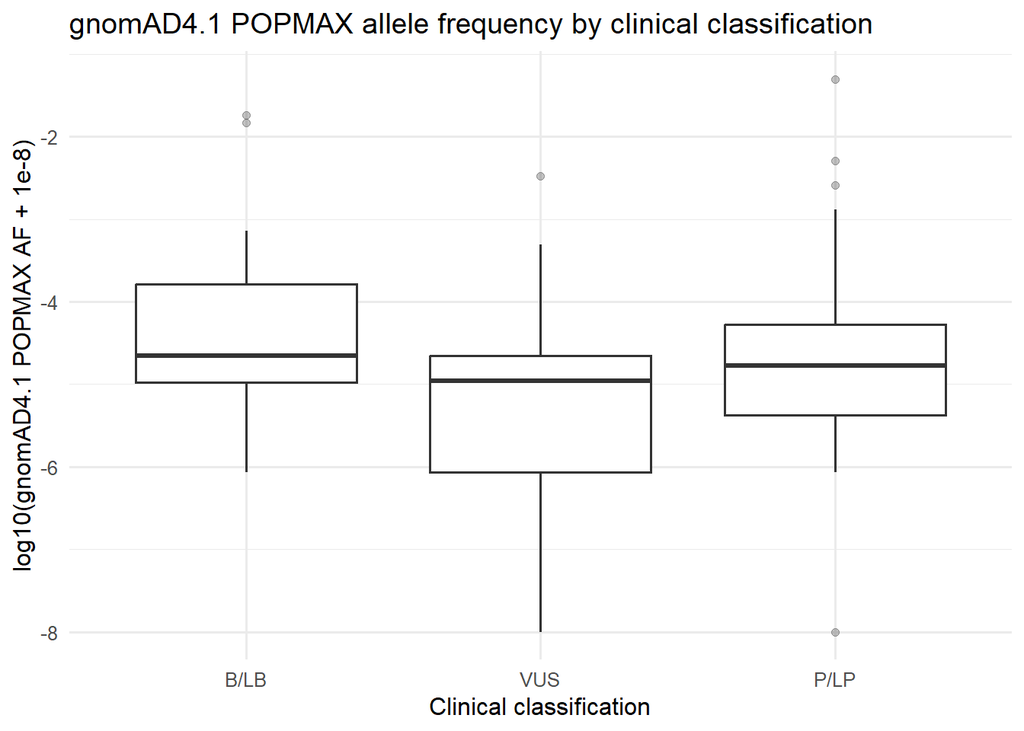

```r
# ============================================================
# PLOT ALLELE FREQUENCY BY CLINICAL GROUP
# ============================================================
# log10(AF + small value) is used because AF values are very skewed.
# ============================================================

plot_af_by_clinical_group_data <- AF_ANALYSIS_DATASET %>%
  filter(
    clinical_group %in% c("P/LP", "B/LB", "VUS"),
    !is.na(af_gnomad4_popmax)
  ) %>%
  mutate(
    log10_popmax_af = log10(af_gnomad4_popmax + 1e-8),
    clinical_group = factor(
      clinical_group,
      levels = c("B/LB", "VUS", "P/LP")
    )
  )

plot_af_by_clinical_group <- ggplot(
  plot_af_by_clinical_group_data,
  aes(x = clinical_group, y = log10_popmax_af)
) +
  geom_boxplot(outlier.alpha = 0.3) +
  labs(
    title = "gnomAD4.1 POPMAX allele frequency by clinical classification",
    x = "Clinical classification",
    y = "log10(gnomAD4.1 POPMAX AF + 1e-8)"
  ) +
  theme_minimal(base_size = 12)

plot_af_by_clinical_group
```

```r
ggsave(
  filename = file.path(plot_directory, "af_by_clinical_group_boxplot.png"),
  plot = plot_af_by_clinical_group,
  width = 7,
  height = 5,
  dpi = 300
)
```

```r
# ============================================================
# REPAIR MISSING ALPHAMISSENSE PREDICTION COLUMN
# ============================================================
# This recreates AlphaMissense_predicted_clean if it is missing.
# ============================================================

if (!"AlphaMissense_predicted_clean" %in% names(BINARY_PERFORMANCE_DATASET)) {

  if ("am_class_new" %in% names(BINARY_PERFORMANCE_DATASET)) {

    BINARY_PERFORMANCE_DATASET <- BINARY_PERFORMANCE_DATASET %>%
      mutate(
        AlphaMissense_predicted_clean = classify_prediction_label(am_class_new)
      )

    cat("AlphaMissense_predicted_clean recreated from am_class_new\n")

  } else {

    cat("am_class_new is also missing, so AlphaMissense cannot be recreated from this object\n")
  }
}

BINARY_PERFORMANCE_DATASET %>%
  summarise(
    AlphaMissense_available = ifelse(
      "AlphaMissense_predicted_clean" %in% names(BINARY_PERFORMANCE_DATASET),
      sum(!is.na(AlphaMissense_predicted_clean)),
      NA_integer_
    ),
    MutPred2_available = ifelse(
      "MutPred2_predicted_clean" %in% names(BINARY_PERFORMANCE_DATASET),
      sum(!is.na(MutPred2_predicted_clean)),
      NA_integer_
    ),
    CADD_available = ifelse(
      "CADD_predicted_clean" %in% names(BINARY_PERFORMANCE_DATASET),
      sum(!is.na(CADD_predicted_clean)),
      NA_integer_
    )
  ) %>%
  print(width = Inf)
```

```
## # A tibble: 1 × 3
##   AlphaMissense_available MutPred2_available CADD_available
##                     <int>              <int>          <int>
## 1                     283                291            742
```

```r
# ============================================================
# CREATE TOOL ERROR GROUPS FOR AF ANALYSIS
# ============================================================
# Compares AF distributions across TP, TN, FP and FN.
# Uses MutPred2, AlphaMissense and CADD if their prediction columns exist.
# ============================================================

create_tool_error_group <- function(data, tool_name, prediction_column) {

  if (!prediction_column %in% names(data)) {
    warning(paste("Skipping", tool_name, "- missing column:", prediction_column))
    return(tibble::tibble())
  }

  data %>%
    filter(
      observed_binary %in% c("Pathogenic", "Benign"),
      !is.na(.data[[prediction_column]])
    ) %>%
    mutate(
      tool = tool_name,
      tool_prediction = .data[[prediction_column]],
      tool_error_group = dplyr::case_when(
        observed_binary == "Pathogenic" & tool_prediction == "Pathogenic" ~ "TP",
        observed_binary == "Benign" & tool_prediction == "Benign" ~ "TN",
        observed_binary == "Benign" & tool_prediction == "Pathogenic" ~ "FP",
        observed_binary == "Pathogenic" & tool_prediction == "Benign" ~ "FN",
        TRUE ~ NA_character_
      )
    )
}

AF_TOOL_ERROR_DATASET <- bind_rows(
  create_tool_error_group(
    data = BINARY_PERFORMANCE_DATASET,
    tool_name = "MutPred2",
    prediction_column = "MutPred2_predicted_clean"
  ),
  create_tool_error_group(
    data = BINARY_PERFORMANCE_DATASET,
    tool_name = "AlphaMissense",
    prediction_column = "AlphaMissense_predicted_clean"
  ),
  create_tool_error_group(
    data = BINARY_PERFORMANCE_DATASET,
    tool_name = "CADD",
    prediction_column = "CADD_predicted_clean"
  )
) %>%
  mutate(
    af_gnomad4_popmax = clean_af_value(gnomAD4_1_joint_POPMAX_AF_new),
    af_gnomad4_joint = clean_af_value(gnomAD4_1_joint_AF_new),
    af_gnomad4_afr = clean_af_value(gnomAD4_1_joint_AFR_AF_new)
  )

AF_TOOL_ERROR_DATASET %>%
  count(tool, tool_error_group) %>%
  print(n = Inf)
```

```
## # A tibble: 12 × 3
##    tool          tool_error_group     n
##    <chr>         <chr>            <int>
##  1 AlphaMissense FN                  35
##  2 AlphaMissense FP                  18
##  3 AlphaMissense TN                  35
##  4 AlphaMissense TP                 195
##  5 CADD          FN                  33
##  6 CADD          FP                 101
##  7 CADD          TN                  90
##  8 CADD          TP                 518
##  9 MutPred2      FN                  25
## 10 MutPred2      FP                  15
## 11 MutPred2      TN                  54
## 12 MutPred2      TP                 197
```

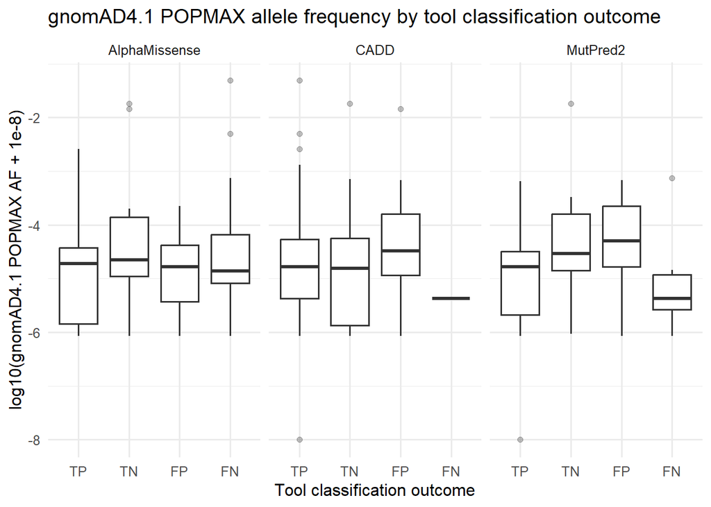

```r
# ============================================================
# PLOT AF BY TOOL ERROR GROUP
# ============================================================

plot_af_by_tool_error_group_data <- AF_TOOL_ERROR_DATASET %>%
  filter(
    tool_error_group %in% c("TP", "TN", "FP", "FN"),
    !is.na(af_gnomad4_popmax)
  ) %>%
  mutate(
    log10_popmax_af = log10(af_gnomad4_popmax + 1e-8),
    tool_error_group = factor(
      tool_error_group,
      levels = c("TP", "TN", "FP", "FN")
    )
  )

plot_af_by_tool_error_group <- ggplot(
  plot_af_by_tool_error_group_data,
  aes(x = tool_error_group, y = log10_popmax_af)
) +
  geom_boxplot(outlier.alpha = 0.3) +
  facet_wrap(~ tool) +
  labs(
    title = "gnomAD4.1 POPMAX allele frequency by tool classification outcome",
    x = "Tool classification outcome",
    y = "log10(gnomAD4.1 POPMAX AF + 1e-8)"
  ) +
  theme_minimal(base_size = 12)

plot_af_by_tool_error_group
```

```r
ggsave(
  filename = file.path(plot_directory, "af_by_tool_error_group_boxplot.png"),
  plot = plot_af_by_tool_error_group,
  width = 9,
  height = 5,
  dpi = 300
)
```

```r
af_analysis_output_index <- tibble::tibble(
  output_name = c(
    "Allele-frequency column summary",
    "AF by clinical group summary",
    "High-frequency P/LP variants",
    "AF by tool error group summary",
    "AF by clinical group boxplot",
    "AF by tool error group boxplot"
  ),
  file_name = c(
    "allele_frequency_column_summary.csv",
    "af_by_clinical_group_summary.csv",
    "high_frequency_pathogenic_variants.csv",
    "af_by_tool_error_group_summary.csv",
    "plots/af_by_clinical_group_boxplot.png",
    "plots/af_by_tool_error_group_boxplot.png"
  )
)

af_analysis_output_index %>%
  print(n = Inf, width = Inf)
```

```
## # A tibble: 6 × 2
##   output_name                     file_name
##   <chr>                           <chr>
## 1 Allele-frequency column summary allele_frequency_column_summary.csv
## 2 AF by clinical group summary    af_by_clinical_group_summary.csv
## 3 High-frequency P/LP variants    high_frequency_pathogenic_variants.csv
## 4 AF by tool error group summary  af_by_tool_error_group_summary.csv
## 5 AF by clinical group boxplot    plots/af_by_clinical_group_boxplot.png
## 6 AF by tool error group boxplot  plots/af_by_tool_error_group_boxplot.png
```

```r
readr::write_csv(
  af_analysis_output_index,
  file.path(output_directory, "af_analysis_output_index.csv")
)
```

##Define group-specific coverage function using the same logic as the original coverage table, but calculates coverage inside each variant group.

```r
count_binary_tool_coverage_by_group <- function(data, tool_name, columns, group_col) {

  existing_columns <- columns[columns %in% names(data)]

  if (length(existing_columns) == 0) {
    return(
      data %>%
        group_by(.data[[group_col]]) %>%
        summarise(
          total_variants_in_group = if ("original_row_id" %in% names(data)) {
            dplyr::n_distinct(original_row_id)
          } else {
            n()
          },
          variants_with_tool_output = 0,
          variants_without_tool_output = total_variants_in_group,
          percent_with_tool_output = 0,
          .groups = "drop"
        ) %>%
        rename(variant_group = .data[[group_col]]) %>%
        mutate(
          tool = tool_name,
          columns_present = NA_character_
        ) %>%
        select(
          tool,
          variant_group,
          total_variants_in_group,
          variants_with_tool_output,
          variants_without_tool_output,
          percent_with_tool_output,
          columns_present
        )
    )
  }

  usable_matrix <- sapply(
    existing_columns,
    function(col) {
      is_usable_tool_value(data[[col]])
    }
  )

  if (is.vector(usable_matrix)) {
    usable_any <- usable_matrix
  } else {
    usable_any <- rowSums(usable_matrix, na.rm = TRUE) > 0
  }

  data_with_usable_flag <- data %>%
    mutate(tool_has_output = usable_any)

  data_with_usable_flag %>%
    group_by(.data[[group_col]]) %>%
    summarise(
      total_variants_in_group = if ("original_row_id" %in% names(data_with_usable_flag)) {
        dplyr::n_distinct(original_row_id)
      } else {
        n()
      },
      variants_with_tool_output = if ("original_row_id" %in% names(data_with_usable_flag)) {
        dplyr::n_distinct(original_row_id[tool_has_output])
      } else {
        sum(tool_has_output)
      },
      variants_without_tool_output = total_variants_in_group - variants_with_tool_output,
      percent_with_tool_output = round(
        variants_with_tool_output / total_variants_in_group * 100,
        1
      ),
      .groups = "drop"
    ) %>%
    rename(variant_group = .data[[group_col]]) %>%
    mutate(
      tool = tool_name,
      columns_present = paste(existing_columns, collapse = "; ")
    ) %>%
    select(
      tool,
      variant_group,
      total_variants_in_group,
      variants_with_tool_output,
      variants_without_tool_output,
      percent_with_tool_output,
      columns_present
    )
}
```

```r
is_usable_tool_value <- function(x) {
  x_clean <- trimws(as.character(x))

  !is.na(x) &
    x_clean != "" &
    x_clean != "-" &
    x_clean != "." &
    !(tolower(x_clean) %in% c(
      "na",
      "nan",
      "null",
      "not_available",
      "not available"
    ))
}
```

##calculating coverage by variant group for binary tools only

```r
binary_tool_coverage_by_variant_group <- bind_rows(
  lapply(
    names(binary_tool_column_map),
    function(tool_name) {
      count_binary_tool_coverage_by_group(
        data = ANALYSIS_DATASET,
        tool_name = tool_name,
        columns = binary_tool_column_map[[tool_name]],
        group_col = "broad_variant_group")})) %>%
  arrange(
    variant_group,
    desc(percent_with_tool_output))

binary_tool_coverage_by_variant_group
```

```
## # A tibble: 176 × 7
##    tool             variant_group total_variants_in_group variants_with_tool_o…¹
##    <chr>            <chr>                           <int>                  <int>
##  1 SIFT             Frameshift                        214                      0
##  2 PROVEAN          Frameshift                        214                      0
##  3 FATHMM           Frameshift                        214                      0
##  4 FATHMM-MKL       Frameshift                        214                      0
##  5 FATHMM-XF        Frameshift                        214                      0
##  6 PolyPhen-2       Frameshift                        214                      0
##  7 MutationTaster   Frameshift                        214                      0
##  8 MutationAssessor Frameshift                        214                      0
##  9 DEOGEN2          Frameshift                        214                      0
## 10 PrimateAI        Frameshift                        214                      0
## # ℹ 166 more rows
## # ℹ abbreviated name: ¹variants_with_tool_output
## # ℹ 3 more variables: variants_without_tool_output <int>,
## #   percent_with_tool_output <dbl>, columns_present <chr>
```

##creating focused tables for missense variants only

```r
binary_tool_coverage_missense <- binary_tool_coverage_by_variant_group %>%
  filter(variant_group == "Missense") %>%
  arrange(desc(percent_with_tool_output))

binary_tool_coverage_missense
```

```
## # A tibble: 22 × 7
##    tool           variant_group total_variants_in_group variants_with_tool_out…¹
##    <chr>          <chr>                           <int>                    <int>
##  1 SIFT           Missense                          979                      978
##  2 PolyPhen-2     Missense                          979                      978
##  3 PROVEAN        Missense                          979                      977
##  4 FATHMM         Missense                          979                      977
##  5 FATHMM-MKL     Missense                          979                      977
##  6 FATHMM-XF      Missense                          979                      977
##  7 MutationTaster Missense                          979                      977
##  8 PrimateAI      Missense                          979                      977
##  9 MutPred2       Missense                          979                      977
## 10 MetaRNN        Missense                          979                      977
## # ℹ 12 more rows
## # ℹ abbreviated name: ¹variants_with_tool_output
## # ℹ 3 more variables: variants_without_tool_output <int>,
## #   percent_with_tool_output <dbl>, columns_present <chr>
```

##for non coding/regulatory variants only

```r
binary_tool_coverage_noncoding <- binary_tool_coverage_by_variant_group %>%
  filter(variant_group == "Non-coding/regulatory") %>%
  arrange(desc(percent_with_tool_output))

binary_tool_coverage_noncoding
```

```
## # A tibble: 22 × 7
##    tool           variant_group    total_variants_in_gr…¹ variants_with_tool_o…²
##    <chr>          <chr>                             <int>                  <int>
##  1 SIFT           Non-coding/regu…                    143                     14
##  2 PROVEAN        Non-coding/regu…                    143                     14
##  3 FATHMM         Non-coding/regu…                    143                     14
##  4 FATHMM-MKL     Non-coding/regu…                    143                     14
##  5 PolyPhen-2     Non-coding/regu…                    143                     14
##  6 MutationTaster Non-coding/regu…                    143                     14
##  7 MutPred2       Non-coding/regu…                    143                     14
##  8 REVEL          Non-coding/regu…                    143                     14
##  9 ClinPred       Non-coding/regu…                    143                     14
## 10 MetaSVM        Non-coding/regu…                    143                     14
## # ℹ 12 more rows
## # ℹ abbreviated names: ¹total_variants_in_group, ²variants_with_tool_output
## # ℹ 3 more variables: variants_without_tool_output <int>,
## #   percent_with_tool_output <dbl>, columns_present <chr>
```

##for splice related variants

```r
binary_tool_coverage_splice <- binary_tool_coverage_by_variant_group %>%
  filter(variant_group == "Splice-related") %>%
  arrange(desc(percent_with_tool_output))

binary_tool_coverage_splice
```

```
## # A tibble: 22 × 7
##    tool             variant_group  total_variants_in_gr…¹ variants_with_tool_o…²
##    <chr>            <chr>                           <int>                  <int>
##  1 SIFT             Splice-related                     71                      0
##  2 PROVEAN          Splice-related                     71                      0
##  3 FATHMM           Splice-related                     71                      0
##  4 FATHMM-MKL       Splice-related                     71                      0
##  5 FATHMM-XF        Splice-related                     71                      0
##  6 PolyPhen-2       Splice-related                     71                      0
##  7 MutationTaster   Splice-related                     71                      0
##  8 MutationAssessor Splice-related                     71                      0
##  9 DEOGEN2          Splice-related                     71                      0
## 10 PrimateAI        Splice-related                     71                      0
## # ℹ 12 more rows
## # ℹ abbreviated names: ¹total_variants_in_group, ²variants_with_tool_output
## # ℹ 3 more variables: variants_without_tool_output <int>,
## #   percent_with_tool_output <dbl>, columns_present <chr>
```

##for coding impact variants

```r
binary_tool_coverage_coding_impact <- binary_tool_coverage_by_variant_group %>%
  filter(
    variant_group %in% c(
      "Missense",
      "Frameshift",
      "Stop/start altered",
      "Synonymous",
      "Other coding"
    )
  ) %>%
  arrange(
    variant_group,
    desc(percent_with_tool_output)
  )

binary_tool_coverage_coding_impact
```

```
## # A tibble: 110 × 7
##    tool             variant_group total_variants_in_group variants_with_tool_o…¹
##    <chr>            <chr>                           <int>                  <int>
##  1 SIFT             Frameshift                        214                      0
##  2 PROVEAN          Frameshift                        214                      0
##  3 FATHMM           Frameshift                        214                      0
##  4 FATHMM-MKL       Frameshift                        214                      0
##  5 FATHMM-XF        Frameshift                        214                      0
##  6 PolyPhen-2       Frameshift                        214                      0
##  7 MutationTaster   Frameshift                        214                      0
##  8 MutationAssessor Frameshift                        214                      0
##  9 DEOGEN2          Frameshift                        214                      0
## 10 PrimateAI        Frameshift                        214                      0
## # ℹ 100 more rows
## # ℹ abbreviated name: ¹variants_with_tool_output
## # ℹ 3 more variables: variants_without_tool_output <int>,
## #   percent_with_tool_output <dbl>, columns_present <chr>
```

## summarise binary tools coverage by variant group

```r
binary_tool_coverage_group_summary <- binary_tool_coverage_by_variant_group %>%
  group_by(variant_group) %>%
  summarise(
    number_of_binary_tools = n(),
    mean_coverage_percent = round(
      mean(percent_with_tool_output, na.rm = TRUE),
      1
    ),
    median_coverage_percent = round(
      median(percent_with_tool_output, na.rm = TRUE),
      1
    ),
    highest_coverage_percent = max(
      percent_with_tool_output,
      na.rm = TRUE
    ),
    lowest_coverage_percent = min(
      percent_with_tool_output,
      na.rm = TRUE
    ),
    .groups = "drop"
  ) %>%
  arrange(desc(mean_coverage_percent))

binary_tool_coverage_group_summary
```

```
## # A tibble: 8 × 6
##   variant_group         number_of_binary_tools mean_coverage_percent
##   <chr>                                  <int>                 <dbl>
## 1 Missense                                  22                  94
## 2 Stop/start altered                        22                  33.2
## 3 Non-coding/regulatory                     22                   6.1
## 4 Synonymous                                22                   0.3
## 5 Other coding                              22                   0.1
## 6 Frameshift                                22                   0
## 7 Splice-related                            22                   0
## 8 UTR                                       22                   0
## # ℹ 3 more variables: median_coverage_percent <dbl>,
## #   highest_coverage_percent <dbl>, lowest_coverage_percent <dbl>
```

##creating binary tool category map

```r
binary_tool_category_map <- tibble::tribble(
  ~tool, ~tool_category,

  "SIFT", "Individual missense predictor",
  "PROVEAN", "Individual missense predictor",
  "FATHMM", "Individual missense predictor",
  "PolyPhen-2", "Individual missense predictor",
  "MutationTaster", "Individual missense predictor",
  "MutationAssessor", "Individual missense predictor",

  "FATHMM-MKL", "Meta/ensemble predictor",
  "FATHMM-XF", "Modern/deep learning predictor",
  "REVEL", "Meta/ensemble predictor",
  "ClinPred", "Meta/ensemble predictor",
  "MetaSVM", "Meta/ensemble predictor",
  "MetaLR", "Meta/ensemble predictor",
  "BayesDel addAF", "Meta/ensemble predictor",
  "BayesDel noAF", "Meta/ensemble predictor",
  "LIST-S2", "Meta/ensemble predictor",

  "AlphaMissense", "Modern/deep learning predictor",
  "EVE", "Modern/deep learning predictor",
  "popEVE", "Modern/deep learning predictor",
  "DEOGEN2", "Modern/deep learning predictor",
  "PrimateAI", "Modern/deep learning predictor",
  "MutPred2", "Modern/deep learning predictor",
  "MetaRNN", "Modern/deep learning predictor")
```

## add tool_category to binary coverage table

```r
binary_tool_coverage_by_variant_group <- binary_tool_coverage_by_variant_group %>%
  left_join(
    binary_tool_category_map,
    by = "tool"
  ) %>%
  mutate(
    tool_category = ifelse(
      is.na(tool_category),
      "Binary classification tool",
      tool_category))

names(binary_tool_coverage_by_variant_group)
```

```
## [1] "tool"                         "variant_group"
## [3] "total_variants_in_group"      "variants_with_tool_output"
## [5] "variants_without_tool_output" "percent_with_tool_output"
## [7] "columns_present"              "tool_category"
```

```r
binary_tool_coverage_missense <- binary_tool_coverage_by_variant_group %>%
  filter(variant_group == "Missense") %>%
  arrange(desc(percent_with_tool_output))

binary_tool_coverage_noncoding <- binary_tool_coverage_by_variant_group %>%
  filter(variant_group == "Non-coding/regulatory") %>%
  arrange(desc(percent_with_tool_output))

binary_tool_coverage_splice <- binary_tool_coverage_by_variant_group %>%
  filter(variant_group == "Splice-related") %>%
  arrange(desc(percent_with_tool_output))

binary_tool_coverage_coding_impact <- binary_tool_coverage_by_variant_group %>%
  filter(
    variant_group %in% c(
      "Missense",
      "Frameshift",
      "Stop/start altered",
      "Synonymous",
      "Other coding")) %>%
  arrange(variant_group,
    desc(percent_with_tool_output))
```

## graph of binary tool coverage by variant group

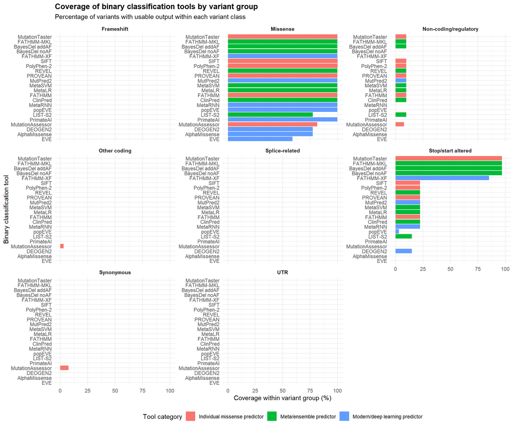

```r
binary_tool_coverage_by_variant_group_plot <- binary_tool_coverage_by_variant_group %>%
  ggplot(
    aes(
      x = reorder(tool, percent_with_tool_output),
      y = percent_with_tool_output,
      fill = tool_category
    )
  ) +
  geom_col() +
  coord_flip() +
  facet_wrap(
    ~ variant_group,
    scales = "free_y"
  ) +
  labs(
    title = "Coverage of binary classification tools by variant group",
    subtitle = "Percentage of variants with usable output within each variant class",
    x = "Binary classification tool",
    y = "Coverage within variant group (%)",
    fill = "Tool category"
  ) +
  theme_minimal(base_size = 11) +
  theme(
    plot.title = element_text(face = "bold"),
    strip.text = element_text(face = "bold"),
    legend.position = "bottom"
  )

binary_tool_coverage_by_variant_group_plot
```

##saving tool variant group coverage outputs

```r
readr::write_csv(
  binary_tool_coverage_by_variant_group,
  file.path(output_directory, "binary_tool_coverage_by_variant_group.csv")
)

readr::write_csv(
  binary_tool_coverage_missense,
  file.path(output_directory, "binary_tool_coverage_missense.csv")
)

readr::write_csv(
  binary_tool_coverage_noncoding,
  file.path(output_directory, "binary_tool_coverage_noncoding.csv")
)

readr::write_csv(
  binary_tool_coverage_splice,
  file.path(output_directory, "binary_tool_coverage_splice.csv")
)

readr::write_csv(
  binary_tool_coverage_coding_impact,
  file.path(output_directory, "binary_tool_coverage_coding_impact.csv")
)

readr::write_csv(
  binary_tool_coverage_group_summary,
  file.path(output_directory, "binary_tool_coverage_group_summary.csv")
)

ggsave(
  filename = file.path(output_directory, "binary_tool_coverage_by_variant_group_plot.png"),
  plot = binary_tool_coverage_by_variant_group_plot,
  width = 12,
  height = 10,
  dpi = 300)
```

## heatmap of binary tool coverage

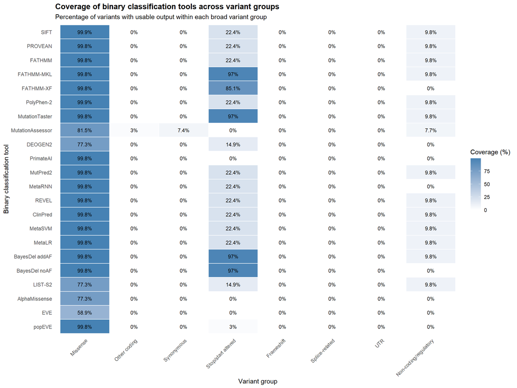

```r
library(ggplot2)
library(dplyr)

binary_tool_coverage_heatmap <- binary_tool_coverage_by_variant_group %>%
  mutate(
    variant_group = factor(
      variant_group,
      levels = c(
        "Missense",
        "Other coding",
        "Synonymous",
        "Stop/start altered",
        "Frameshift",
        "Splice-related",
        "UTR",
        "Non-coding/regulatory"
      )
    ),
    tool = factor(
      tool,
      levels = rev(unique(tool))
    )
  ) %>%
  ggplot(
    aes(
      x = variant_group,
      y = tool,
      fill = percent_with_tool_output
    )
  ) +
  geom_tile(color = "white", linewidth = 0.4) +
  geom_text(
    aes(label = paste0(percent_with_tool_output, "%")),
    size = 3
  ) +
  labs(
    title = "Coverage of binary classification tools across variant groups",
    subtitle = "Percentage of variants with usable output within each broad variant group",
    x = "Variant group",
    y = "Binary classification tool",
    fill = "Coverage (%)"
  ) +
  scale_fill_gradient(
    low = "white",
    high = "steelblue"
  ) +
  theme_minimal(base_size = 11) +
  theme(
    plot.title = element_text(face = "bold"),
    axis.text.x = element_text(angle = 45, hjust = 1),
    panel.grid = element_blank()
  )

binary_tool_coverage_heatmap
```

```r
ggsave(
  filename = file.path(output_directory, "binary_tool_coverage_heatmap.png"),
  plot = binary_tool_coverage_heatmap,
  width = 12,
  height = 9,
  dpi = 300
)
```

```r
count_tool_coverage_by_group <- function(data, tool_name, columns, group_col) {

  columns_present <- columns[columns %in% names(data)]

  if (length(columns_present) == 0) {
    return(
      data %>%
        group_by(.data[[group_col]]) %>%
        summarise(
          tool = tool_name,
          total_variants_in_group = n(),
          variants_with_tool_output = 0,
          variants_without_tool_output = n(),
          percent_with_tool_output = 0,
          columns_present = "None",
          .groups = "drop"
        ) %>%
        rename(variant_group = .data[[group_col]])
    )
  }

  data %>%
    mutate(
      has_tool_output = if_any(
        all_of(columns_present),
        is_usable_tool_value
      )
    ) %>%
    group_by(.data[[group_col]]) %>%
    summarise(
      tool = tool_name,
      total_variants_in_group = n(),
      variants_with_tool_output = sum(has_tool_output, na.rm = TRUE),
      variants_without_tool_output = total_variants_in_group - variants_with_tool_output,
      percent_with_tool_output = round(
        variants_with_tool_output / total_variants_in_group * 100,
        1
      ),
      columns_present = paste(columns_present, collapse = "; "),
      .groups = "drop"
    ) %>%
    rename(variant_group = .data[[group_col]])
}
```

## All-tool coverage by variant group

```r
tool_coverage_by_variant_group <- bind_rows(
  lapply(
    names(tool_column_map),
    function(tool_name) {
      count_tool_coverage_by_group(
        data = ANALYSIS_DATASET,
        tool_name = tool_name,
        columns = tool_column_map[[tool_name]],
        group_col = "broad_variant_group")})
) %>%
  arrange(
    variant_group,
    desc(percent_with_tool_output)
  )

tool_coverage_by_variant_group
```

```
## # A tibble: 440 × 7
##    variant_group tool             total_variants_in_group variants_with_tool_o…¹
##    <chr>         <chr>                              <int>                  <dbl>
##  1 Frameshift    SpliceAI                             214                    172
##  2 Frameshift    CADD                                 214                    119
##  3 Frameshift    SIFT                                 214                      0
##  4 Frameshift    PolyPhen-2                           214                      0
##  5 Frameshift    MutationTaster                       214                      0
##  6 Frameshift    LRT                                  214                      0
##  7 Frameshift    MutationAssessor                     214                      0
##  8 Frameshift    PROVEAN                              214                      0
##  9 Frameshift    FATHMM                               214                      0
## 10 Frameshift    FATHMM-MKL                           214                      0
## # ℹ 430 more rows
## # ℹ abbreviated name: ¹variants_with_tool_output
## # ℹ 3 more variables: variants_without_tool_output <int>,
## #   percent_with_tool_output <dbl>, columns_present <chr>
```

## adding tool/classification/category

```r
tool_coverage_by_variant_group <- tool_coverage_by_variant_group %>%
  left_join(
    tool_category_map,
    by = "tool"
  ) %>%
  mutate(
    tool_category = ifelse(
      is.na(tool_category),
      "Uncategorised",
      tool_category
    )
  ) %>%
  select(
    tool_category,
    tool,
    variant_group,
    total_variants_in_group,
    variants_with_tool_output,
    variants_without_tool_output,
    percent_with_tool_output,
    columns_present
  )

tool_coverage_by_variant_group
```

```
## # A tibble: 440 × 8
##    tool_category                      tool  variant_group total_variants_in_gr…¹
##    <chr>                              <chr> <chr>                          <int>
##  1 Splicing predictor                 Spli… Frameshift                       214
##  2 Continuous deleteriousness / cons… CADD  Frameshift                       214
##  3 Individual missense predictor      SIFT  Frameshift                       214
##  4 Individual missense predictor      Poly… Frameshift                       214
##  5 Individual missense predictor      Muta… Frameshift                       214
##  6 Individual missense predictor      LRT   Frameshift                       214
##  7 Individual missense predictor      Muta… Frameshift                       214
##  8 Individual missense predictor      PROV… Frameshift                       214
##  9 Individual missense predictor      FATH… Frameshift                       214
## 10 Meta/ensemble predictor            FATH… Frameshift                       214
## # ℹ 430 more rows
## # ℹ abbreviated name: ¹total_variants_in_group
## # ℹ 4 more variables: variants_with_tool_output <dbl>,
## #   variants_without_tool_output <int>, percent_with_tool_output <dbl>,
## #   columns_present <chr>
```

## summarising coverage by tool classification and variant group

```r
tool_classification_coverage_by_variant_group <- tool_coverage_by_variant_group %>%
  group_by(tool_category, variant_group) %>%
  summarise(
    number_of_tools = n(),
    mean_coverage_percent = round(mean(percent_with_tool_output, na.rm = TRUE), 1),
    median_coverage_percent = round(median(percent_with_tool_output, na.rm = TRUE), 1),
    highest_coverage_percent = max(percent_with_tool_output, na.rm = TRUE),
    lowest_coverage_percent = min(percent_with_tool_output, na.rm = TRUE),
    .groups = "drop"
  ) %>%
  arrange(
    variant_group,
    desc(mean_coverage_percent)
  )

tool_classification_coverage_by_variant_group
```

```
## # A tibble: 64 × 7
##    tool_category             variant_group number_of_tools mean_coverage_percent
##    <chr>                     <chr>                   <int>                 <dbl>
##  1 Splicing predictor        Frameshift                  4                  20.1
##  2 Continuous deleteriousne… Frameshift                 13                   4.3
##  3 Conservation score        Frameshift                  6                   0
##  4 Gene-level intolerance /… Frameshift                  5                   0
##  5 Individual missense pred… Frameshift                  8                   0
##  6 Meta/ensemble predictor   Frameshift                  9                   0
##  7 Modern/deep learning pre… Frameshift                  9                   0
##  8 Substitution matrix / de… Frameshift                  1                   0
##  9 Substitution matrix / de… Missense                    1                  99.9
## 10 Meta/ensemble predictor   Missense                    9                  97.3
## # ℹ 54 more rows
## # ℹ 3 more variables: median_coverage_percent <dbl>,
## #   highest_coverage_percent <dbl>, lowest_coverage_percent <dbl>
```

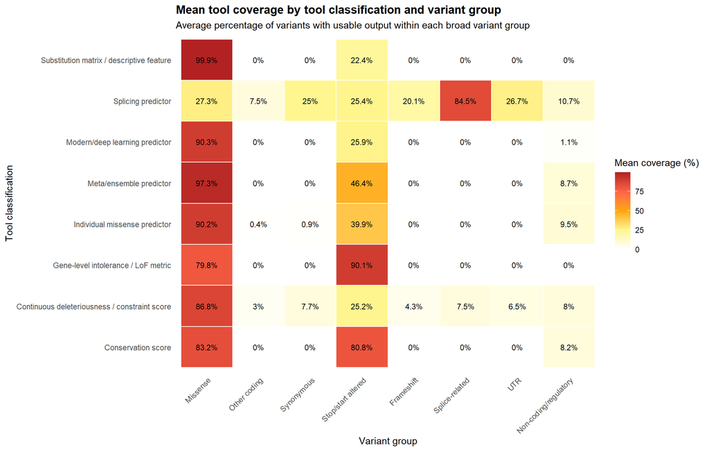

```r
tool_classification_coverage_heatmap <- tool_classification_coverage_by_variant_group %>%
  mutate(
    variant_group = factor(
      variant_group,
      levels = c(
        "Missense",
        "Other coding",
        "Synonymous",
        "Stop/start altered",
        "Frameshift",
        "Splice-related",
        "UTR",
        "Non-coding/regulatory"
      )
    )
  ) %>%
  ggplot(
    aes(
      x = variant_group,
      y = tool_category,
      fill = mean_coverage_percent
    )
  ) +
  geom_tile(color = "white", linewidth = 0.4) +
  geom_text(
    aes(label = paste0(mean_coverage_percent, "%")),
    size = 3
  ) +
  scale_fill_gradientn(
    colours = c("white", "khaki1", "orange", "tomato", "firebrick")
  ) +
  labs(
    title = "Mean tool coverage by tool classification and variant group",
    subtitle = "Average percentage of variants with usable output within each broad variant group",
    x = "Variant group",
    y = "Tool classification",
    fill = "Mean coverage (%)"
  ) +
  theme_minimal(base_size = 11) +
  theme(
    plot.title = element_text(face = "bold"),
    axis.text.x = element_text(angle = 45, hjust = 1),
    panel.grid = element_blank()
  )

tool_classification_coverage_heatmap
```

```r
# output_directory is already defined near the top of the notebook

if (!dir.exists(output_directory)) {
  dir.create(output_directory, recursive = TRUE)
}

readr::write_csv(
  tool_coverage_by_variant_group,
  file.path(output_directory, "tool_coverage_by_variant_group.csv")
)

readr::write_csv(
  tool_classification_coverage_by_variant_group,
  file.path(output_directory, "tool_classification_coverage_by_variant_group.csv")
)

ggsave(
  filename = file.path(output_directory, "tool_classification_coverage_heatmap.png"),
  plot = tool_classification_coverage_heatmap,
  width = 11,
  height = 7,
  dpi = 300
)
```

##this is to extract the numeric characters to allow the thresholds be applicable

```r
clean_numeric_score <- function(x) {
  suppressWarnings(
    as.numeric(
      str_extract(
        as.character(x),
        "-?[0-9]*\\.?[0-9]+" )))}
```

##clean dataset

```r
ANALYSIS_DATASET <- ANALYSIS_DATASET %>%
  mutate(
    SIFT_new_numeric = clean_numeric_score(SIFT_new),

    PROVEAN_new_numeric = clean_numeric_score(PROVEAN_score_new),

    FATHMM_new_numeric = clean_numeric_score(FATHMM_score_seperated),

    FATHMM_MKL_new_numeric = clean_numeric_score(`fathmm-MKL_coding_score`),

    REVEL_new_numeric = clean_numeric_score(REVEL_score_new),

    ClinPred_new_numeric = clean_numeric_score(ClinPred_score_new),

    MetaSVM_new_numeric = clean_numeric_score(MetaSVM_score_new),

    MetaLR_new_numeric = clean_numeric_score(MetaLR_score_new),

    BayesDel_addAF_new_numeric = clean_numeric_score(BayesDel_addAF_score_new),

    BayesDel_noAF_new_numeric = clean_numeric_score(BayesDel_noAF_score_new),

    LIST_S2_new_numeric = clean_numeric_score(LIST_S2_score_new)
  )
```

# determine the amount of usable numeric scores each tool contains

```r
cleaned_score_coverage <- tibble(
  tool = c(
    "SIFT",
    "PROVEAN",
    "FATHMM",
    "REVEL",
    "ClinPred",
    "MetaSVM",
    "MetaLR",
    "BayesDel addAF",
    "BayesDel noAF",
    "LIST-S2",
    "AlphaMissense"
  ),

  non_missing_scores = c(
    sum(!is.na(ANALYSIS_DATASET$SIFT_new_numeric)),
    sum(!is.na(ANALYSIS_DATASET$PROVEAN_new_numeric)),
    sum(!is.na(ANALYSIS_DATASET$FATHMM_new_numeric)),
    sum(!is.na(ANALYSIS_DATASET$REVEL_new_numeric)),
    sum(!is.na(ANALYSIS_DATASET$ClinPred_new_numeric)),
    sum(!is.na(ANALYSIS_DATASET$MetaSVM_new_numeric)),
    sum(!is.na(ANALYSIS_DATASET$MetaLR_new_numeric)),
    sum(!is.na(ANALYSIS_DATASET$BayesDel_addAF_new_numeric)),
    sum(!is.na(ANALYSIS_DATASET$BayesDel_noAF_new_numeric)),
    sum(!is.na(ANALYSIS_DATASET$LIST_S2_new_numeric)),
    sum(!is.na(ANALYSIS_DATASET$AlphaMissense_new_numeric))))
cleaned_score_coverage
```

```
## # A tibble: 11 × 2
##    tool           non_missing_scores
##    <chr>                       <int>
##  1 SIFT                          993
##  2 PROVEAN                       992
##  3 FATHMM                       1006
##  4 REVEL                         992
##  5 ClinPred                      992
##  6 MetaSVM                       992
##  7 MetaLR                        992
##  8 BayesDel addAF               1042
##  9 BayesDel noAF                1042
## 10 LIST-S2                       178
## 11 AlphaMissense                   0
```

## convert available numeric scores into binary prediction

```r
ANALYSIS_DATASET <- ANALYSIS_DATASET %>%
  mutate(
    PROVEAN_new_numeric = clean_numeric_score(PROVEAN_score_new),
    FATHMM_new_numeric = clean_numeric_score(FATHMM_score_seperated),
    FATHMM_MKL_new_numeric = clean_numeric_score(`fathmm-MKL_coding_score`),
    REVEL_new_numeric = clean_numeric_score(REVEL_score_new),
    ClinPred_new_numeric = clean_numeric_score(ClinPred_score_new),
    MetaSVM_new_numeric = clean_numeric_score(MetaSVM_score_new),
    MetaLR_new_numeric = clean_numeric_score(MetaLR_score_new),
    BayesDel_addAF_new_numeric = clean_numeric_score(BayesDel_addAF_score_new),
    BayesDel_noAF_new_numeric = clean_numeric_score(BayesDel_noAF_score_new),
    LIST_S2_new_numeric = clean_numeric_score(LIST_S2_score_new),

    PROVEAN_predicted = case_when(
      PROVEAN_new_numeric <= -2.5 ~ "Pathogenic",
      PROVEAN_new_numeric > -2.5 ~ "Benign",
      TRUE ~ NA_character_
    ),

    FATHMM_predicted = case_when(
      FATHMM_new_numeric <= -1.5 ~ "Pathogenic",
      FATHMM_new_numeric > -1.5 ~ "Benign",
      TRUE ~ NA_character_
    ),

    FATHMM_MKL_predicted = case_when(
      FATHMM_MKL_new_numeric > 0.5 ~ "Pathogenic",
      FATHMM_MKL_new_numeric < 0.5 ~ "Benign",
      TRUE ~ NA_character_
    ),

    REVEL_predicted = case_when(
      REVEL_new_numeric > 0.5 ~ "Pathogenic",
      REVEL_new_numeric <= 0.5 ~ "Benign",
      TRUE ~ NA_character_
    ),

    ClinPred_predicted = case_when(
      ClinPred_new_numeric > 0.5 ~ "Pathogenic",
      ClinPred_new_numeric <= 0.5 ~ "Benign",
      TRUE ~ NA_character_
    ),

    MetaSVM_predicted = case_when(
      MetaSVM_new_numeric > 0 ~ "Pathogenic",
      MetaSVM_new_numeric <= 0 ~ "Benign",
      TRUE ~ NA_character_
    ),

    MetaLR_predicted = case_when(
      MetaLR_new_numeric > 0.5 ~ "Pathogenic",
      MetaLR_new_numeric <= 0.5 ~ "Benign",
      TRUE ~ NA_character_
    ),

    BayesDel_addAF_predicted = case_when(
      BayesDel_addAF_new_numeric > 0.0692655 ~ "Pathogenic",
      BayesDel_addAF_new_numeric <= 0.0692655 ~ "Benign",
      TRUE ~ NA_character_
    ),

    BayesDel_noAF_predicted = case_when(
      BayesDel_noAF_new_numeric > -0.0570105 ~ "Pathogenic",
      BayesDel_noAF_new_numeric <= -0.0570105 ~ "Benign",
      TRUE ~ NA_character_
    ),

    LIST_S2_predicted = case_when(
      LIST_S2_new_numeric > 0.85 ~ "Pathogenic",
      LIST_S2_new_numeric <= 0.85 ~ "Benign",
      TRUE ~ NA_character_
    )
  )
```

```r
ANALYSIS_DATASET <- ANALYSIS_DATASET %>%
  mutate(
    SIFT_new_numeric = clean_numeric_score(SIFT_new),
    PROVEAN_new_numeric = clean_numeric_score(PROVEAN_score_new),
    FATHMM_new_numeric = clean_numeric_score(FATHMM_score_seperated),
    FATHMM_MKL_new_numeric = clean_numeric_score(`fathmm-MKL_coding_score`),
    REVEL_new_numeric = clean_numeric_score(REVEL_score_new),
    ClinPred_new_numeric = clean_numeric_score(ClinPred_score_new),
    MetaSVM_new_numeric = clean_numeric_score(MetaSVM_score_new),
    MetaLR_new_numeric = clean_numeric_score(MetaLR_score_new),
    BayesDel_addAF_new_numeric = clean_numeric_score(BayesDel_addAF_score_new),
    BayesDel_noAF_new_numeric = clean_numeric_score(BayesDel_noAF_score_new),
    LIST_S2_new_numeric = clean_numeric_score(LIST_S2_score_new),

    SIFT_predicted = case_when(
      SIFT_new_numeric <= 0.05 ~ "Pathogenic",
      SIFT_new_numeric > 0.05 ~ "Benign",
      TRUE ~ NA_character_
    ),

    PROVEAN_predicted = case_when(
      PROVEAN_new_numeric <= -2.5 ~ "Pathogenic",
      PROVEAN_new_numeric > -2.5 ~ "Benign",
      TRUE ~ NA_character_
    ),

    FATHMM_predicted = case_when(
      FATHMM_new_numeric <= -1.5 ~ "Pathogenic",
      FATHMM_new_numeric > -1.5 ~ "Benign",
      TRUE ~ NA_character_
    ),

    FATHMM_MKL_predicted = case_when(
      FATHMM_MKL_new_numeric > 0.5 ~ "Pathogenic",
      FATHMM_MKL_new_numeric < 0.5 ~ "Benign",
      TRUE ~ NA_character_
    ),

    REVEL_predicted = case_when(
      REVEL_new_numeric > 0.5 ~ "Pathogenic",
      REVEL_new_numeric <= 0.5 ~ "Benign",
      TRUE ~ NA_character_
    ),

    ClinPred_predicted = case_when(
      ClinPred_new_numeric > 0.5 ~ "Pathogenic",
      ClinPred_new_numeric <= 0.5 ~ "Benign",
      TRUE ~ NA_character_
    ),

    MetaSVM_predicted = case_when(
      MetaSVM_new_numeric > 0 ~ "Pathogenic",
      MetaSVM_new_numeric <= 0 ~ "Benign",
      TRUE ~ NA_character_
    ),

    MetaLR_predicted = case_when(
      MetaLR_new_numeric > 0.5 ~ "Pathogenic",
      MetaLR_new_numeric <= 0.5 ~ "Benign",
      TRUE ~ NA_character_
    ),

    BayesDel_addAF_predicted = case_when(
      BayesDel_addAF_new_numeric > 0.0692655 ~ "Pathogenic",
      BayesDel_addAF_new_numeric <= 0.0692655 ~ "Benign",
      TRUE ~ NA_character_
    ),

    BayesDel_noAF_predicted = case_when(
      BayesDel_noAF_new_numeric > -0.0570105 ~ "Pathogenic",
      BayesDel_noAF_new_numeric <= -0.0570105 ~ "Benign",
      TRUE ~ NA_character_
    ),

    LIST_S2_predicted = case_when(
      LIST_S2_new_numeric > 0.85 ~ "Pathogenic",
      LIST_S2_new_numeric <= 0.85 ~ "Benign",
      TRUE ~ NA_character_
    )
  )
```

```r
grep(
  "_predicted$",
  names(ANALYSIS_DATASET),
  value = TRUE
)
```

```
##  [1] "SIFT_predicted"             "PROVEAN_predicted"
##  [3] "FATHMM_predicted"           "FATHMM_MKL_predicted"
##  [5] "REVEL_predicted"            "ClinPred_predicted"
##  [7] "MetaSVM_predicted"          "MetaLR_predicted"
##  [9] "BayesDel_addAF_predicted"   "BayesDel_noAF_predicted"
## [11] "LIST_S2_predicted"          "PolyPhen_predicted"
## [13] "MutationTaster_predicted"   "MutationAssessor_predicted"
## [15] "DEOGEN2_predicted"          "PrimateAI_predicted"
## [17] "MutPred2_predicted"         "MetaRNN_predicted"
## [19] "fathmm_XF_predicted"        "AlphaMissense_predicted"
## [21] "EVE_predicted"              "popEVE_predicted"
```

## check how many variabts each tool predicted as benign/pathogenic or NA to determine if prediction tools are working

```r
prediction_count_summary <- bind_rows(
  ANALYSIS_DATASET %>%
    count(SIFT_predicted) %>%
    mutate(tool = "SIFT", prediction = SIFT_predicted) %>%
    select(tool, prediction, n),

  ANALYSIS_DATASET %>%
    count(PROVEAN_predicted) %>%
    mutate(tool = "PROVEAN", prediction = PROVEAN_predicted) %>%
    select(tool, prediction, n),

  ANALYSIS_DATASET %>%
    count(FATHMM_predicted) %>%
    mutate(tool = "FATHMM", prediction = FATHMM_predicted) %>%
    select(tool, prediction, n),

  ANALYSIS_DATASET %>%
    count(FATHMM_MKL_predicted) %>%
    mutate(tool = "FATHMM-MKL", prediction = FATHMM_MKL_predicted) %>%
    select(tool, prediction, n),

  ANALYSIS_DATASET %>%
    count(REVEL_predicted) %>%
    mutate(tool = "REVEL", prediction = REVEL_predicted) %>%
    select(tool, prediction, n),

  ANALYSIS_DATASET %>%
    count(ClinPred_predicted) %>%
    mutate(tool = "ClinPred", prediction = ClinPred_predicted) %>%
    select(tool, prediction, n),

  ANALYSIS_DATASET %>%
    count(MetaSVM_predicted) %>%
    mutate(tool = "MetaSVM", prediction = MetaSVM_predicted) %>%
    select(tool, prediction, n),

  ANALYSIS_DATASET %>%
    count(MetaLR_predicted) %>%
    mutate(tool = "MetaLR", prediction = MetaLR_predicted) %>%
    select(tool, prediction, n),

  ANALYSIS_DATASET %>%
    count(BayesDel_addAF_predicted) %>%
    mutate(tool = "BayesDel addAF", prediction = BayesDel_addAF_predicted) %>%
    select(tool, prediction, n),

  ANALYSIS_DATASET %>%
    count(BayesDel_noAF_predicted) %>%
    mutate(tool = "BayesDel noAF", prediction = BayesDel_noAF_predicted) %>%
    select(tool, prediction, n),

  ANALYSIS_DATASET %>%
    count(LIST_S2_predicted) %>%
    mutate(tool = "LIST-S2", prediction = LIST_S2_predicted) %>%
    select(tool, prediction, n)
)

prediction_count_summary
```

```
## # A tibble: 32 × 3
##    tool       prediction     n
##    <chr>      <chr>      <int>
##  1 SIFT       Benign       167
##  2 SIFT       Pathogenic   826
##  3 SIFT       <NA>         634
##  4 PROVEAN    Benign       233
##  5 PROVEAN    Pathogenic   759
##  6 PROVEAN    <NA>         635
##  7 FATHMM     Pathogenic  1006
##  8 FATHMM     <NA>         621
##  9 FATHMM-MKL Benign       304
## 10 FATHMM-MKL Pathogenic   752
## # ℹ 22 more rows
```

## arrnage tools in descending order based on mcc

```r
binary_tool_performance_summary %>%
  arrange(desc(mcc))
```

```
## # A tibble: 22 × 18
##    tool             prediction_column         total_eligible_binar…¹ n_evaluated
##    <chr>            <chr>                                      <int>       <dbl>
##  1 MutPred2         MutPred2_predicted_clean                    1026         291
##  2 CADD             CADD_predicted_clean                        1026         742
##  3 AlphaMissense    AlphaMissense_predicted_…                   1026         283
##  4 Eigen-PC         Eigen_PC_predicted_clean                    1026         522
##  5 popEVE           popEVE_predicted_clean                      1026          67
##  6 SIFT             SIFT_predicted_clean                        1026         472
##  7 MutationAssessor MutationAssessor_predict…                   1026         224
##  8 DANN             DANN_predicted_clean                        1026         522
##  9 PolyPhen-2       PolyPhen_predicted_clean                    1026         481
## 10 ESM1b            ESM1b_predicted_clean                       1026         514
## # ℹ 12 more rows
## # ℹ abbreviated name: ¹total_eligible_binary_variants
## # ℹ 14 more variables: variants_not_evaluated <dbl>, true_positive <dbl>,
## #   true_negative <dbl>, false_positive <dbl>, false_negative <dbl>,
## #   accuracy <dbl>, sensitivity <dbl>, specificity <dbl>, ppv <dbl>, npv <dbl>,
## #   balanced_accuracy <dbl>, mcc <dbl>, LR_positive <dbl>, LR_negative <dbl>
```

## save results in directory

```r
output_directory <- paste0(
  "C:/Users/HP/Documents/",
  "ASSESSMENT OF IN SILICO TOOLS FOR VARIANT EFFECT ",
  "PREDICTION IN HAEMOGLOBINOPATHIES/",
  "haemoglobinopathy-variant/results")

if (!dir.exists(output_directory)) {
  dir.create(output_directory, recursive = TRUE)}

output_directory
```

```
## [1] "C:/Users/HP/Documents/ASSESSMENT OF IN SILICO TOOLS FOR VARIANT EFFECT PREDICTION IN HAEMOGLOBINOPATHIES/haemoglobinopathy-variant/results"
```

```r
readr::write_csv(
  binary_tool_performance_summary,
  file.path(output_directory, "binary_tool_performance_summary.csv"))
```

## plot the number of variants used by each tool

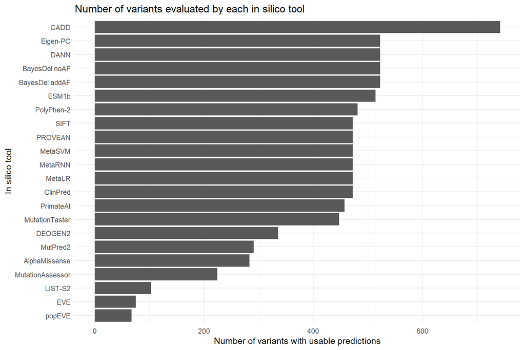

```r
coverage_plot <- binary_tool_performance_summary %>%
  arrange(n_evaluated) %>%
  ggplot(
    aes(
      x = reorder(tool, n_evaluated),
      y = n_evaluated
    )
  ) +
  geom_col() +
  coord_flip() +
  labs(
    title = "Number of variants evaluated by each in silico tool",
    x = "In silico tool",
    y = "Number of variants with usable predictions"
  ) +
  theme_minimal()

coverage_plot
```